# Survival in colon, rectal and small intestinal cancers in the nordic countries through a half century

Full R code

Filip Tichanek, Asta Försti, Vaclav Liska, Akseli Hemminki, Kari Hemminki

November 07, 2022

```r
knitr::opts_chunk$set(echo = TRUE)
```

# Introduction

This report shows source data, their wrangling, fitting statistical models, outputs of the models, and visualizations of both data and probabilistic models.

All analyses were done using [R sofware](https://www.r-project.org/) in [RStudio](https://www.rstudio.com/) interface.

## Software and Packages

Software versions.

```r
rm(list=ls()) # removing all data and objects from R environment
R.version
```

```
##                _
## platform       x86_64-w64-mingw32
## arch           x86_64
## os             mingw32
## system         x86_64, mingw32
## status
## major          4
## minor          1.2
## year           2021
## month          11
## day            01
## svn rev        81115
## language       R
## version.string R version 4.1.2 (2021-11-01)
## nickname       Bird Hippie
```

```r
rstudioapi::versionInfo()$version
```

```
## [1] '2022.7.1.554'
```

Uploading R packages and their version

```r
library(stringr);packageVersion('stringr')
```

```
## [1] '1.4.0'
```

```r
library(brms);packageVersion('brms')
```

```
## [1] '2.16.3'
```

```r
packageVersion('Rstan') # uploaded automatically with brms
```

```
## [1] '2.26.6'
```

```r
library(dplyr);packageVersion('dplyr')
```

```
## [1] '1.0.7'
```

```r
library(cowplot);packageVersion('cowplot')
```

```
## [1] '1.1.1'
```

# Incidence and mortality

```r
## setting parameters for smoothing
spar=0.4
knot=15

## Defining colors

cola<-c(
  rgb(1,0.1,0.1,alpha=1),
  rgb(0.1,0.1,1,alpha=1),
  rgb(0, 0.6, 0.3,alpha=1),
  rgb(0.7,0.7,0.1,alpha=1))

colb<-c(
  rgb(1,0.1,0.1,alpha=0.2),
  rgb(0.1,0.1,1,alpha=0.2),
  rgb(0, 0.6, 0.3,alpha=0.2),
  rgb(0.7,0.7,0.1,alpha=0.2))

colc<-c(
  rgb(1,0.1,0.1,alpha=0.8),
  rgb(0.1,0.1,1,alpha=0.8),
  rgb(0, 0.6, 0.3,alpha=0.8),
  rgb(0.7,0.7,0.1,alpha=0.8))
```

## Data upload and wrangling

### Colon cancer data

Data were downloaded from [Nordcan](https://nordcan.iarc.fr/en/dataviz/trends?sexes=1_2&cancers=90&populations=208_246_752_578&mode=population&multiple_populations=1&multiple_cancers=0&survival=1&types=0_1)

```r
urlfile="https://raw.githubusercontent.com/filip-tichanek/nord_intestine/main/colon_inc_mor.csv"
colon_inc_mor<-read.csv(url(urlfile),sep=",")
```

```r
colon_inc_mor
```

| Label | X1943 | X1944 | X1945 | X1946 | X1947 | X1948 | X1949 | X1950 | X1951 | X1952 | X1953 | X1954 | X1955 | X1956 | X1957 | X1958 | X1959 | X1960 | X1961 | X1962 | X1963 | X1964 | X1965 | X1966 | X1967 | X1968 | X1969 | X1970 | X1971 | … |
| --- | --- | --- | --- | --- | --- | --- | --- | --- | --- | --- | --- | --- | --- | --- | --- | --- | --- | --- | --- | --- | --- | --- | --- | --- | --- | --- | --- | --- | --- | --- |
| Denmark, incidence, males | 14.3 | 14.3 | 14.3 | 14.8 | 13.5 | 16.0 | 13.8 | 14.4 | 14.8 | 13.3 | 14.3 | 13.7 | 13.5 | 13.3 | 13.0 | 15.0 | 15.4 | 13.7 | 16.9 | 14.9 | 16.4 | 15.3 | 17.1 | 15.8 | 17.3 | 16.7 | 17.4 | 17.7 | 16.1 | … |
| Finland, incidence, males | - | - | - | - | - | - | - | - | - | - | 5.4 | 4.8 | 5.2 | 5.0 | 3.6 | 5.6 | 6.0 | 5.9 | 5.6 | 6.0 | 8.0 | 6.4 | 7.1 | 7.9 | 7.6 | 6.6 | 7.7 | 8.6 | 7.8 | … |
| Norway, incidence, males | - | - | - | - | - | - | - | - | - | - | 9.5 | 10.3 | 9.0 | 9.5 | 8.6 | 10.9 | 10.1 | 11.1 | 10.4 | 10.8 | 10.9 | 11.9 | 12.1 | 12.4 | 13.7 | 13.2 | 11.3 | 12.7 | 13.5 | … |
| Sweden, incidence, males | - | - | - | - | - | - | - | - | - | - | - | - | - | - | - | - | - | 12.8 | 13.4 | 13.8 | 14.0 | 15.2 | 15.2 | 15.7 | 15.0 | 15.2 | 16.2 | 16.6 | 16.3 | … |
| Denmark, incidence, females | 14.4 | 13.3 | 16.1 | 14.7 | 15.8 | 14.7 | 14.7 | 15.9 | 15.0 | 14.7 | 15.8 | 14.1 | 15.3 | 15.6 | 14.8 | 16.6 | 18.1 | 17.2 | 17.1 | 16.6 | 17.1 | 17.9 | 17.3 | 18.9 | 17.9 | 19.4 | 20.0 | 18.6 | 17.4 | … |
| Finland, incidence, females | - | - | - | - | - | - | - | - | - | - | 6.1 | 5.2 | 5.5 | 6.2 | 3.2 | 4.8 | 6.0 | 7.6 | 7.0 | 7.6 | 8.2 | 6.9 | 6.9 | 7.6 | 7.8 | 7.7 | 7.8 | 8.3 | 8.8 | … |
| Norway, incidence, females | - | - | - | - | - | - | - | - | - | - | 8.6 | 8.6 | 9.8 | 9.0 | 9.6 | 10.7 | 10.3 | 10.0 | 10.3 | 10.6 | 11.6 | 11.5 | 11.0 | 12.7 | 12.7 | 12.3 | 12.3 | 13.2 | 13.5 | … |
| Sweden, incidence, females | - | - | - | - | - | - | - | - | - | - | - | - | - | - | - | - | - | 12.2 | 12.3 | 13.9 | 14.1 | 12.9 | 14.5 | 13.5 | 14.4 | 14.6 | 14.5 | 15.5 | 14.6 | … |
| Denmark, mortality, males | - | - | - | - | - | - | - | - | 12.8 | 11.2 | 11.8 | 12.2 | 11.4 | 10.6 | 11.2 | 12.5 | 12.9 | 12.8 | 11.4 | 12.5 | 12.9 | 12.6 | 13.0 | 11.4 | 11.4 | 10.5 | 11.2 | 11.5 | 10.6 | … |
| Finland, mortality, males | - | - | - | - | - | - | - | - | - | - | 3.7 | 3.7 | 3.9 | 4.6 | 2.4 | 4.2 | 4.1 | 4.2 | 4.8 | 4.3 | 5.4 | 4.9 | 5.0 | 5.7 | 5.5 | 4.9 | 4.7 | 5.8 | 5.0 | … |

[output cut: 6 more lines]

Data wrangling

```r
colnam<-colon_inc_mor[,1]
colon_inc_mor<-data.frame(t(colon_inc_mor))[-1,]
colnames(colon_inc_mor) <- colnam
colon_inc_mor$year <- 1943:2020

### Subseting years 1961-2020
colon_inc_mor<-colon_inc_mor[colon_inc_mor$year>1960,]

### Removing space character and converting characters to numbers
x=1;repeat{
colon_inc_mor[,x]<-str_trim(colon_inc_mor[,x])
colon_inc_mor[,x]<-as.numeric(colon_inc_mor[,x])
x=x+1;if(x>17){break}}
summary(colon_inc_mor)
```

```
##  Denmark, incidence, males Finland, incidence, males Norway, incidence, males
##  Min.   :14.90             Min.   : 5.60             Min.   :10.40
##  1st Qu.:18.65             1st Qu.: 9.20             1st Qu.:14.60
##  Median :20.55             Median :12.85             Median :22.30
##  Mean   :21.38             Mean   :12.55             Mean   :20.65
##  3rd Qu.:23.90             3rd Qu.:15.82             3rd Qu.:25.75
##  Max.   :32.70             Max.   :18.40             Max.   :28.30
##  Sweden, incidence, males Denmark, incidence, females
##  Min.   :13.40            Min.   :16.60
##  1st Qu.:16.45            1st Qu.:18.68
##  Median :17.10            Median :19.30
##  Mean   :17.30            Mean   :19.86
##  3rd Qu.:18.35            3rd Qu.:21.00
##  Max.   :19.90            Max.   :27.00
##  Finland, incidence, females Norway, incidence, females
##  Min.   : 6.90               Min.   :10.30
##  1st Qu.: 9.65               1st Qu.:15.07
##  Median :11.70               Median :19.60
##  Mean   :11.31               Mean   :19.34
##  3rd Qu.:13.00               3rd Qu.:23.30
##  Max.   :15.10               Max.   :27.20
##  Sweden, incidence, females Denmark, mortality, males Finland, mortality, males
##  Min.   :12.30              Min.   : 7.90             Min.   :4.300
##  1st Qu.:14.70              1st Qu.:11.40             1st Qu.:5.500
##  Median :15.30              Median :12.50             Median :6.000
##  Mean   :15.55              Mean   :12.35             Mean   :5.917
##  3rd Qu.:16.30              3rd Qu.:13.62             3rd Qu.:6.300
##  Max.   :18.40              Max.   :15.00             Max.   :7.300
##  Norway, mortality, males Sweden, mortality, males Denmark, mortality, females
##  Min.   : 7.00            Min.   : 6.500           Min.   : 6.10
##  1st Qu.: 9.00            1st Qu.: 8.350           1st Qu.: 9.80
##  Median :10.25            Median : 9.100           Median :11.50
##  Mean   :10.21            Mean   : 9.082           Mean   :10.88
##  3rd Qu.:11.53            3rd Qu.: 9.750           3rd Qu.:12.20
##  Max.   :12.90            Max.   :11.700           Max.   :12.90
##  Finland, mortality, females Norway, mortality, females
##  Min.   :4.000               Min.   : 6.500
##  1st Qu.:4.775               1st Qu.: 8.200
##  Median :5.100               Median : 9.000
##  Mean   :5.115               Mean   : 8.902
##  3rd Qu.:5.500               3rd Qu.: 9.600
##  Max.   :6.300               Max.   :10.800
##  Sweden, mortality, females      year
##  Min.   :5.500              Min.   :1961
##  1st Qu.:6.775              1st Qu.:1976
##  Median :7.500              Median :1990
##  Mean   :7.655              Mean   :1990
##  3rd Qu.:8.625              3rd Qu.:2005
##  Max.   :9.800              Max.   :2020
```

### Rectal cancer data

Data were downloaded from [Nordcan](https://nordcan.iarc.fr/en/dataviz/trends?sexes=1_2&cancers=100&populations=208_246_752_578&mode=population&multiple_populations=1&multiple_cancers=0&survival=1&types=0_1)

```r
urlfile="https://raw.githubusercontent.com/filip-tichanek/nord_intestine/main/rectum_inc_mor.csv"
rectum_inc_mor<-read.csv(url(urlfile),sep=",")
```

```r
rectum_inc_mor
```

| Label | X1943 | X1944 | X1945 | X1946 | X1947 | X1948 | X1949 | X1950 | X1951 | X1952 | X1953 | X1954 | X1955 | X1956 | X1957 | X1958 | X1959 | X1960 | X1961 | X1962 | X1963 | X1964 | X1965 | X1966 | X1967 | X1968 | X1969 | X1970 | X1971 | … |
| --- | --- | --- | --- | --- | --- | --- | --- | --- | --- | --- | --- | --- | --- | --- | --- | --- | --- | --- | --- | --- | --- | --- | --- | --- | --- | --- | --- | --- | --- | --- |
| Denmark, incidence, males | 21.1 | 21.2 | 20.2 | 20.7 | 19.4 | 20.0 | 18.7 | 17.9 | 18.2 | 18.3 | 17.4 | 17.4 | 16.2 | 16.1 | 17.5 | 16.4 | 19.2 | 18.0 | 18.5 | 17.2 | 17.6 | 17.0 | 16.4 | 16.2 | 16.5 | 18.1 | 17.4 | 15.8 | 17.3 | … |
| Finland, incidence, males | - | - | - | - | - | - | - | - | - | - | 5.9 | 5.1 | 5.0 | 5.2 | 5.3 | 5.3 | 6.2 | 6.2 | 5.9 | 6.2 | 7.1 | 8.4 | 7.9 | 6.8 | 7.0 | 7.9 | 8.8 | 8.4 | 8.7 | … |
| Norway, incidence, males | - | - | - | - | - | - | - | - | - | - | 6.2 | 6.4 | 6.0 | 7.1 | 6.5 | 5.8 | 6.5 | 6.5 | 6.6 | 7.5 | 7.1 | 6.3 | 7.2 | 6.9 | 7.5 | 9.3 | 9.9 | 10.6 | 9.6 | … |
| Sweden, incidence, males | - | - | - | - | - | - | - | - | - | - | - | - | - | - | - | - | - | 9.9 | 10.0 | 9.5 | 10.1 | 10.7 | 10.8 | 10.6 | 10.6 | 10.0 | 10.5 | 10.0 | 10.7 | … |
| Denmark, incidence, females | 12.1 | 12.3 | 13.4 | 12.1 | 12.2 | 11.8 | 12.1 | 12.0 | 11.8 | 11.4 | 10.0 | 11.0 | 11.3 | 11.6 | 10.7 | 11.9 | 12.0 | 11.2 | 9.8 | 10.5 | 10.3 | 11.4 | 11.6 | 10.7 | 10.5 | 11.0 | 10.8 | 10.4 | 10.1 | … |
| Finland, incidence, females | - | - | - | - | - | - | - | - | - | - | 4.5 | 4.5 | 3.7 | 4.2 | 5.1 | 5.1 | 4.5 | 5.0 | 4.8 | 5.6 | 6.6 | 6.8 | 5.9 | 6.3 | 7.0 | 5.8 | 6.7 | 5.8 | 7.2 | … |
| Norway, incidence, females | - | - | - | - | - | - | - | - | - | - | 4.2 | 3.5 | 4.1 | 4.4 | 4.2 | 5.0 | 4.2 | 4.3 | 3.9 | 4.2 | 4.5 | 4.7 | 4.6 | 5.1 | 5.6 | 6.2 | 6.4 | 7.3 | 6.7 | … |
| Sweden, incidence, females | - | - | - | - | - | - | - | - | - | - | - | - | - | - | - | - | - | 5.5 | 6.3 | 6.3 | 6.5 | 7.6 | 7.0 | 6.8 | 7.0 | 6.7 | 6.7 | 6.5 | 6.6 | … |
| Denmark, mortality, males | - | - | - | - | - | - | - | - | 12.4 | 13.9 | 12.5 | 13.2 | 12.2 | 12.5 | 12.3 | 11.6 | 14.1 | 12.5 | 11.6 | 11.8 | 11.4 | 12.5 | 10.8 | 11.1 | 10.1 | 10.5 | 10.8 | 9.9 | 10.2 | … |
| Finland, mortality, males | - | - | - | - | - | - | - | - | - | - | 5.3 | 4.6 | 5.2 | 4.4 | 3.7 | 4.2 | 3.8 | 5.0 | 4.3 | 5.1 | 5.5 | 5.7 | 6.1 | 5.4 | 4.8 | 4.9 | 5.0 | 7.2 | 6.1 | … |

[output cut: 6 more lines]

Data wrangling

```r
colnam<-rectum_inc_mor[,1]
rectum_inc_mor<-data.frame(t(rectum_inc_mor))[-1,]
colnames(rectum_inc_mor) <- colnam
rectum_inc_mor$year <- 1943:2020

### Sub-setting years 1961-2020
rectum_inc_mor<-rectum_inc_mor[rectum_inc_mor$year>1960,]

### Removing space character and converting characters to numbers
x=1;repeat{
rectum_inc_mor[,x]<-str_trim(rectum_inc_mor[,x])
rectum_inc_mor[,x]<-as.numeric(rectum_inc_mor[,x])
x=x+1;if(x>17){break}}
summary(rectum_inc_mor)
```

```
##  Denmark, incidence, males Finland, incidence, males Norway, incidence, males
##  Min.   :13.00             Min.   : 5.90             Min.   : 6.30
##  1st Qu.:16.50             1st Qu.: 9.10             1st Qu.:12.22
##  Median :17.10             Median :10.75             Median :15.35
##  Mean   :17.01             Mean   :10.27             Mean   :14.08
##  3rd Qu.:17.70             3rd Qu.:11.50             3rd Qu.:16.43
##  Max.   :19.60             Max.   :12.80             Max.   :17.90
##  Sweden, incidence, males Denmark, incidence, females
##  Min.   : 9.50            Min.   : 7.600
##  1st Qu.:11.05            1st Qu.: 9.675
##  Median :11.70            Median :10.100
##  Mean   :11.57            Mean   :10.168
##  3rd Qu.:12.30            3rd Qu.:10.700
##  Max.   :13.50            Max.   :12.100
##  Finland, incidence, females Norway, incidence, females
##  Min.   :4.800               Min.   : 3.900
##  1st Qu.:6.375               1st Qu.: 7.825
##  Median :6.700               Median : 9.750
##  Mean   :6.682               Mean   : 8.995
##  3rd Qu.:7.100               3rd Qu.:10.400
##  Max.   :7.800               Max.   :11.300
##  Sweden, incidence, females Denmark, mortality, males Finland, mortality, males
##  Min.   :6.200              Min.   : 3.700            Min.   :3.700
##  1st Qu.:6.875              1st Qu.: 6.200            1st Qu.:4.775
##  Median :7.400              Median : 8.750            Median :5.100
##  Mean   :7.292              Mean   : 8.252            Mean   :5.195
##  3rd Qu.:7.700              3rd Qu.:10.300            3rd Qu.:5.700
##  Max.   :8.200              Max.   :12.500            Max.   :7.200
##  Norway, mortality, males Sweden, mortality, males Denmark, mortality, females
##  Min.   :3.800            Min.   :3.800            Min.   :1.700
##  1st Qu.:4.850            1st Qu.:4.400            1st Qu.:3.400
##  Median :6.800            Median :5.150            Median :5.050
##  Mean   :6.358            Mean   :5.280            Mean   :4.705
##  3rd Qu.:7.800            3rd Qu.:6.025            3rd Qu.:5.925
##  Max.   :8.900            Max.   :7.300            Max.   :7.300
##  Finland, mortality, females Norway, mortality, females
##  Min.   :1.800               Min.   :1.800
##  1st Qu.:2.400               1st Qu.:2.875
##  Median :3.100               Median :3.850
##  Mean   :3.187               Mean   :3.767
##  3rd Qu.:3.925               3rd Qu.:4.500
##  Max.   :5.000               Max.   :5.300
##  Sweden, mortality, females      year
##  Min.   :2.000              Min.   :1961
##  1st Qu.:2.600              1st Qu.:1976
##  Median :3.100              Median :1990
##  Mean   :3.117              Mean   :1990
##  3rd Qu.:3.500              3rd Qu.:2005
##  Max.   :4.200              Max.   :2020
```

### Small intestine data

Data were downloaded from [Nordcan](https://nordcan.iarc.fr/en/dataviz/trends?sexes=1_2&cancers=80&populations=208_246_752_578&mode=population&multiple_populations=1&multiple_cancers=0&survival=1&types=0_1)

```r
urlfile="https://raw.githubusercontent.com/filip-tichanek/nord_intestine/main/small_intestine_inc_mor.csv"
small_intestine_inc_mor<-read.csv(url(urlfile),sep=",")
```

```r
small_intestine_inc_mor
```

| Label | X1943 | X1944 | X1945 | X1946 | X1947 | X1948 | X1949 | X1950 | X1951 | X1952 | X1953 | X1954 | X1955 | X1956 | X1957 | X1958 | X1959 | X1960 | X1961 | X1962 | X1963 | X1964 | X1965 | X1966 | X1967 | X1968 | X1969 | X1970 | X1971 | … |
| --- | --- | --- | --- | --- | --- | --- | --- | --- | --- | --- | --- | --- | --- | --- | --- | --- | --- | --- | --- | --- | --- | --- | --- | --- | --- | --- | --- | --- | --- | --- |
| Denmark, incidence, males | 0.77 | 0.57 | 0.64 | 0.41 | 0.70 | 0.54 | 0.71 | 0.55 | 0.45 | 0.52 | 0.45 | 0.66 | 1.0 | 0.66 | 0.46 | 0.36 | 0.85 | 0.71 | 0.83 | 0.67 | 1.10 | 0.61 | 0.87 | 0.97 | 0.68 | 0.69 | 1.00 | 0.98 | 0.71 | … |
| Finland, incidence, males | - | - | - | - | - | - | - | - | - | - | 0.36 | 0.29 | 1.0 | 0.64 | 0.75 | 0.61 | 0.70 | 0.85 | 0.30 | 0.56 | 0.40 | 0.44 | 0.48 | 0.53 | 0.46 | 0.45 | 0.49 | 0.61 | 0.73 | … |
| Norway, incidence, males | - | - | - | - | - | - | - | - | - | - | 0.38 | 0.65 | 0.79 | 0.38 | 0.76 | 0.51 | 0.39 | 0.34 | 0.40 | 0.38 | 0.52 | 0.52 | 0.35 | 0.65 | 0.63 | 0.54 | 0.60 | 0.86 | 0.63 | … |
| Sweden, incidence, males | - | - | - | - | - | - | - | - | - | - | - | - | - | - | - | - | - | 0.84 | 0.79 | 0.75 | 0.79 | 0.76 | 0.83 | 1.00 | 1.00 | 1.20 | 0.82 | 1.10 | 1.00 | … |
| Denmark, incidence, females | 0.37 | 0.72 | 0.75 | 0.50 | 0.51 | 0.55 | 0.55 | 0.35 | 0.59 | 0.49 | 0.25 | 0.72 | 0.39 | 0.57 | 0.73 | 0.38 | 0.73 | 0.46 | 0.53 | 0.65 | 0.77 | 0.30 | 0.49 | 0.62 | 0.40 | 0.55 | 0.65 | 0.59 | 0.53 | … |
| Finland, incidence, females | - | - | - | - | - | - | - | - | - | - | 0.54 | 0.58 | 0.93 | 0.49 | 0.97 | 0.39 | 0.41 | 0.40 | 0.73 | 0.27 | 0.68 | 0.32 | 0.40 | 0.29 | 0.30 | 0.60 | 0.60 | 0.42 | 0.53 | … |
| Norway, incidence, females | - | - | - | - | - | - | - | - | - | - | 0.20 | 0.24 | 0.37 | 0.54 | 0.48 | 0.22 | 0.32 | 0.23 | 0.22 | 0.30 | 0.51 | 0.49 | 0.30 | 0.35 | 0.16 | 0.62 | 0.40 | 0.56 | 0.67 | … |
| Sweden, incidence, females | - | - | - | - | - | - | - | - | - | - | - | - | - | - | - | - | - | 0.64 | 0.65 | 0.69 | 0.51 | 0.75 | 0.95 | 0.81 | 0.68 | 0.76 | 0.88 | 0.75 | 1.00 | … |
| Denmark, mortality, males | - | - | - | - | - | - | - | - | 0.57 | 0.67 | 0.67 | 0.84 | 1.0 | 1.1 | 1.2 | 0.88 | 0.82 | 0.61 | 0.88 | 0.54 | 0.98 | 0.64 | 1.00 | 1.10 | 0.94 | 0.67 | 0.46 | 0.50 | 0.43 | … |
| Finland, mortality, males | - | - | - | - | - | - | - | - | - | - | 0.71 | 0.18 | 0.71 | 0.51 | 0.65 | 0.41 | 0.37 | 0.78 | 0.41 | 0.43 | 0.47 | 0.33 | 0.33 | 0.42 | 0.33 | 0.17 | 0.17 | 0.39 | 0.39 | … |

[output cut: 6 more lines]

Data wrangling

```r
colnam<-small_intestine_inc_mor[,1]
small_intestine_inc_mor<-data.frame(t(small_intestine_inc_mor))[-1,]
colnames(small_intestine_inc_mor) <- colnam
small_intestine_inc_mor$year <- 1943:2020

### Subseting years 1961-2020
small_intestine_inc_mor<-small_intestine_inc_mor[small_intestine_inc_mor$year>1960,]

### Removing space character and converting characters to numbers
x=1;repeat{
small_intestine_inc_mor[,x]<-str_trim(small_intestine_inc_mor[,x])
small_intestine_inc_mor[,x]<-as.numeric(small_intestine_inc_mor[,x])
x=x+1;if(x>17){break}}
summary(small_intestine_inc_mor)
```

```
##  Denmark, incidence, males Finland, incidence, males Norway, incidence, males
##  Min.   :0.440             Min.   :0.3000            Min.   :0.310
##  1st Qu.:0.710             1st Qu.:0.6775            1st Qu.:0.630
##  Median :0.900             Median :0.9800            Median :0.970
##  Mean   :1.032             Mean   :1.0037            Mean   :1.188
##  3rd Qu.:1.125             3rd Qu.:1.3000            3rd Qu.:1.700
##  Max.   :2.400             Max.   :2.1000            Max.   :2.900
##  Sweden, incidence, males Denmark, incidence, females
##  Min.   :0.750            Min.   :0.3000
##  1st Qu.:1.200            1st Qu.:0.5500
##  Median :1.450            Median :0.6900
##  Mean   :1.367            Mean   :0.7798
##  3rd Qu.:1.600            3rd Qu.:0.8350
##  Max.   :2.000            Max.   :1.8000
##  Finland, incidence, females Norway, incidence, females
##  Min.   :0.2700              Min.   :0.1600
##  1st Qu.:0.5575              1st Qu.:0.5875
##  Median :0.6650              Median :0.7500
##  Mean   :0.7260              Mean   :0.8860
##  3rd Qu.:0.8650              3rd Qu.:1.2000
##  Max.   :1.6000              Max.   :2.1000
##  Sweden, incidence, females Denmark, mortality, males Finland, mortality, males
##  Min.   :0.5100             Min.   :0.1900            Min.   :0.1700
##  1st Qu.:0.8375             1st Qu.:0.3900            1st Qu.:0.3875
##  Median :0.9750             Median :0.4900            Median :0.4700
##  Mean   :0.9843             Mean   :0.5157            Mean   :0.4780
##  3rd Qu.:1.1250             3rd Qu.:0.5700            3rd Qu.:0.5725
##  Max.   :1.4000             Max.   :1.1000            Max.   :0.8200
##  Norway, mortality, males Sweden, mortality, males Denmark, mortality, females
##  Min.   :0.1800           Min.   :0.230            Min.   :0.1500
##  1st Qu.:0.3675           1st Qu.:0.390            1st Qu.:0.3100
##  Median :0.4600           Median :0.485            Median :0.3700
##  Mean   :0.4687           Mean   :0.470            Mean   :0.3988
##  3rd Qu.:0.5625           3rd Qu.:0.550            3rd Qu.:0.4800
##  Max.   :0.7400           Max.   :0.720            Max.   :0.8100
##  Finland, mortality, females Norway, mortality, females
##  Min.   :0.120               Min.   :0.0500
##  1st Qu.:0.240               1st Qu.:0.3100
##  Median :0.305               Median :0.4050
##  Mean   :0.319               Mean   :0.3845
##  3rd Qu.:0.420               3rd Qu.:0.4900
##  Max.   :0.480               Max.   :0.6200
##  Sweden, mortality, females      year
##  Min.   :0.1500             Min.   :1961
##  1st Qu.:0.3000             1st Qu.:1976
##  Median :0.3600             Median :1990
##  Mean   :0.3652             Mean   :1990
##  3rd Qu.:0.4300             3rd Qu.:2005
##  Max.   :0.5500             Max.   :2020
```

## Suppl. Figure 1 - Incidence

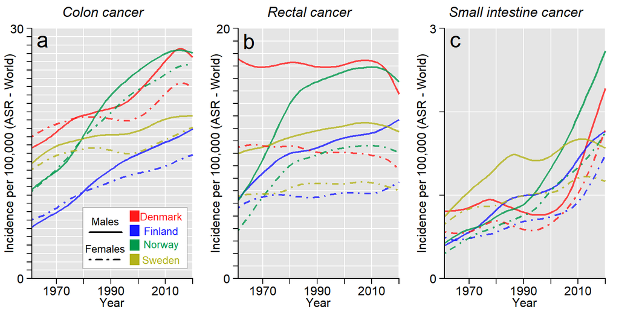

```r
### General setting and titles of plots
m <- matrix(c(1,2,3
             ,4,5,6), nrow = 2, ncol =3 ,byrow = TRUE)
layout(mat = m,heights = c(0.06,1-0.06))
par(mgp=c(1.6,0.8,0))
par(mar=c(0,0,0,0))

plot(NULL, axes=FALSE,xlab="",ylab="",xlim=c(-1,1),ylim=c(-0.85,0.85))
text(0,-0.2,"Colon cancer",cex=1.6,font=3,xpd=TRUE)

plot(NULL, axes=FALSE,xlab="",ylab="",xlim=c(-1,1),ylim=c(-0.85,0.85))
text(0,-0.2,"Rectal cancer",cex=1.6,font=3,xpd=TRUE)

plot(NULL, axes=FALSE,xlab="",ylab="",xlim=c(-1,1),ylim=c(-0.85,0.85))
text(0,-0.2,"Small intestine cancer",cex=1.6,font=3,xpd=TRUE)

## Plot of colon cancer incidence
par(mgp=c(1.6,0.8,0))
par(mar=c(2,2.5,0,0.7))

range<-c(0,30);scal<-range[2]-range[1]
xrange<-c(1961,2020)

plot(NULL,xlim=xrange,ylim=c(range[1],range[2]),xlab="",ylab=""
     ,las=1, axes=FALSE)
rect(xrange[1],range[2],xrange[2],range[1],col="grey90",border=NA)
x<-range[1]
repeat{
  lines(c(xrange[1],xrange[2]),c(x,x),col="white")
  x=x+1;if(x>range[2]){break}}

x<- round(xrange[1]+5,-1)
repeat{
  lines(c(x,x),c(range[1],range[2]),col="white")
  x=x+10;if(x>2020){break}}

data=colon_inc_mor;xx<-1
repeat{
smoothingSpline = smooth.spline(data$year, data[,xx], spar=spar, nknots=knot)
lines(smoothingSpline,col=colc[xx],lty=1,lwd=2,lend=1)
xx=xx+1;if(xx>4){break}}

repeat{
  smoothingSpline = smooth.spline(data$year, data[,xx], spar=spar, nknots=knot)
  lines(smoothingSpline,col=colc[xx-4],lty=4,lwd=2,lend=1)
  xx=xx+1;if(xx>8){break}}

axis(2,las=2,cex.axis=1.4,at=seq(range[1],range[2],by=1),
 labels=c(range[1],rep("",length(seq(range[1],range[2],by=1))-2),range[2]),pos=xrange[1])
title(ylab="Incidence per 100,000 (ASR - World)", line=1, cex.lab=1.4)
axis(side=1,las=1,cex.axis=1.4,at=c(seq(round(xrange[1]+5,-1),2020,by=10)),pos=range[1])
lines(c(xrange[1],xrange[2]),c(range[1],range[1]))
title(xlab="Year", line=1, cex.lab=1.4,xpd=TRUE)
text(1965,range[2]-0.05*scal,"a",cex=2.5)

xx=1;yy=range[1]+scal*0.25
rect(1979.7,yy+0.035*scal,2017.9,yy-0.21*scal,col="white",border="grey50",lwd=0.8)
repeat{
  lines(c(1997,2000.5),c(yy,yy),lwd=14,col=cola[xx],lend=1)
  xx<-xx+1;yy=yy-(scal*0.058);if(xx>4){break}}

text(1988,0.23*scal,"Males",cex=1.25)
lines(c(1982,1994),c(0.185*scal,0.185*scal),lwd=2)

text(1988,0.12*scal,"Females",cex=1.25)
lines(c(1982,1994),c(0.075*scal,0.075*scal),lwd=2,lty=4)

xx=1;yy=range[1]+scal*0.25
text(2008.5,yy,"Denmark",col=cola[xx],cex=1.25);xx=xx+1;yy=yy-(scal*0.058)
text(2008.5,yy,"Finland",col=cola[xx],cex=1.25);xx=xx+1;yy=yy-(scal*0.058)
text(2008.5,yy,"Norway",col=cola[xx],cex=1.25);xx=xx+1;yy=yy-(scal*0.058)
text(2008.5,yy,"Sweden",col=cola[xx],cex=1.25);xx=xx+1;yy=yy-(scal*0.058)

## Plot of rectal cancer incidence
  par(mgp=c(1.6,0.8,0))
  par(mar=c(2,2.5,0,0.7))

  range<-c(0,20);scal<-range[2]-range[1]
  xrange<-c(1961,2020)

  plot(NULL,xlim=xrange,ylim=c(range[1],range[2]),xlab="",ylab=""
       ,las=1, axes=FALSE)
  rect(xrange[1],range[2],xrange[2],range[1],col="grey90",border=NA)
  x<-range[1]
  repeat{
    lines(c(xrange[1],xrange[2]),c(x,x),col="white")
    x=x+1;if(x>range[2]){break}}

  x<- round(xrange[1]+5,-1)
  repeat{
    lines(c(x,x),c(range[1],range[2]),col="white")
    x=x+10;if(x>2020){break}}

  data=rectum_inc_mor;xx<-1
  repeat{
    smoothingSpline = smooth.spline(data$year, data[,xx], spar=spar, nknots=knot)
    lines(smoothingSpline,col=colc[xx],lty=1,lwd=2,lend=1)
    xx=xx+1;if(xx>4){break}}

  repeat{
    smoothingSpline = smooth.spline(data$year, data[,xx], spar=spar, nknots=knot)
    lines(smoothingSpline,col=colc[xx-4],lty=4,lwd=2,lend=1)
    xx=xx+1;if(xx>8){break}}

  axis(2,las=2,cex.axis=1.4,at=seq(range[1],range[2],by=1),
      labels=c(range[1],rep("",length(seq(range[1],range[2],by=1))-2),range[2]),pos=xrange[1])
  title(ylab="Incidence per 100,000 (ASR - World)", line=1, cex.lab=1.4)
  axis(side=1,las=1,cex.axis=1.4,at=c(seq(round(xrange[1]+5,-1),2020,by=10)),pos=range[1])
  lines(c(xrange[1],xrange[2]),c(range[1],range[1]))
  title(xlab="Year", line=1, cex.lab=1.4,xpd=TRUE)
  text(1965,range[2]-0.05*scal,"b",cex=2.5)

## Plot of small_intestine cancer incidence
  par(mgp=c(1.6,0.8,0))
  par(mar=c(2,2.5,0,0.7))

  range<-c(0,3);scal<-range[2]-range[1]
  xrange<-c(1961,2020)

  plot(NULL,xlim=xrange,ylim=c(range[1],range[2]),xlab="",ylab=""
       ,las=1, axes=FALSE)
  rect(xrange[1],range[2],xrange[2],range[1],col="grey90",border=NA)
  x<-range[1]
  repeat{
    lines(c(xrange[1],xrange[2]),c(x,x),col="white")
    x=x+1;if(x>range[2]){break}}

  x<- round(xrange[1]+5,-1)
  repeat{
    lines(c(x,x),c(range[1],range[2]),col="white")
    x=x+10;if(x>2020){break}}

  data=small_intestine_inc_mor;xx<-1
  repeat{
    smoothingSpline = smooth.spline(data$year, data[,xx], spar=spar, nknots=knot)
    lines(smoothingSpline,col=colc[xx],lty=1,lwd=2,lend=1)
    xx=xx+1;if(xx>4){break}}

  repeat{
    smoothingSpline = smooth.spline(data$year, data[,xx], spar=spar, nknots=knot)
    lines(smoothingSpline,col=colc[xx-4],lty=4,lwd=2,lend=1)
    xx=xx+1;if(xx>8){break}}


  axis(2,las=2,cex.axis=1.4,at=seq(range[1],range[2],by=1),
       labels=c(range[1],rep("",length(seq(range[1],range[2],by=1))-2),range[2]),pos=xrange[1])
  title(ylab="Incidence per 100,000 (ASR - World)", line=1, cex.lab=1.4)
  axis(side=1,las=1,cex.axis=1.4,at=c(seq(round(xrange[1]+5,-1),2020,by=10)),pos=range[1])
  lines(c(xrange[1],xrange[2]),c(range[1],range[1]))
  title(xlab="Year", line=1, cex.lab=1.4,xpd=TRUE)
  text(1965,range[2]-0.05*scal,"c",cex=2.5)
```

## Suppl. Figure 2 - Mortality

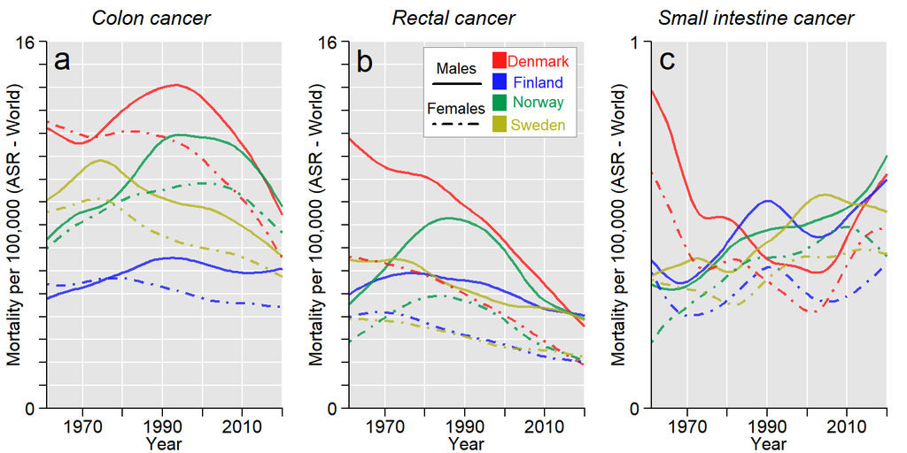

```r
## General setting and titles of plots ------------
  m <- matrix(c(1,2,3
                ,4,5,6), nrow = 2, ncol =3 ,byrow = TRUE)
  layout(mat = m,heights = c(0.06,1-0.06))
  par(mgp=c(1.6,0.8,0))
  par(mar=c(0,0,0,0))

  plot(NULL, axes=FALSE,xlab="",ylab="",xlim=c(-1,1),ylim=c(-0.85,0.85))
  text(0,-0.2,"Colon cancer",cex=1.6,font=3,xpd=TRUE)

  plot(NULL, axes=FALSE,xlab="",ylab="",xlim=c(-1,1),ylim=c(-0.85,0.85))
  text(0,-0.2,"Rectal cancer",cex=1.6,font=3,xpd=TRUE)

  plot(NULL, axes=FALSE,xlab="",ylab="",xlim=c(-1,1),ylim=c(-0.85,0.85))
  text(0,-0.2,"Small intestine cancer",cex=1.6,font=3,xpd=TRUE)

## Plot of colon cancer mortality --------
  par(mgp=c(1.6,0.8,0))
  par(mar=c(2,2.5,0,0.7))

  range<-c(0,16);scal<-range[2]-range[1]
  xrange<-c(1961,2020)

  plot(NULL,xlim=xrange,ylim=c(range[1],range[2]),xlab="",ylab=""
       ,las=1, axes=FALSE)
  rect(xrange[1],range[2],xrange[2],range[1],col="grey90",border=NA)
  x<-range[1]
  repeat{
    lines(c(xrange[1],xrange[2]),c(x,x),col="white")
    x=x+1;if(x>range[2]){break}}

  x<- round(xrange[1]+5,-1)
  repeat{
    lines(c(x,x),c(range[1],range[2]),col="white")
    x=x+10;if(x>2020){break}}

  data=colon_inc_mor;xx<-9
  repeat{
    smoothingSpline = smooth.spline(data$year, data[,xx], spar=spar, nknots=knot)
    lines(smoothingSpline,col=colc[xx-8],lty=1,lwd=2,lend=1)
    xx=xx+1;if(xx>12){break}}

  repeat{
    smoothingSpline = smooth.spline(data$year, data[,xx], spar=spar, nknots=knot)
    lines(smoothingSpline,col=colc[xx-12],lty=4,lwd=2,lend=1)
    xx=xx+1;if(xx>16){break}}

  axis(2,las=2,cex.axis=1.4,at=seq(range[1],range[2],by=1),
       labels=c(range[1],rep("",length(seq(range[1],range[2],by=1))-2),range[2]),pos=xrange[1])
  title(ylab="Mortality per 100,000 (ASR - World)", line=1, cex.lab=1.4)
  axis(side=1,las=1,cex.axis=1.4,at=c(seq(round(xrange[1]+5,-1),2020,by=10)),pos=range[1])
  lines(c(xrange[1],xrange[2]),c(range[1],range[1]))
  title(xlab="Year", line=1, cex.lab=1.4,xpd=TRUE)
  text(1965,range[2]-0.05*scal,"a",cex=2.5)


## Plot of rectal cancer mortality
  par(mgp=c(1.6,0.8,0))
  par(mar=c(2,2.5,0,0.7))

  range<-c(0,16);scal<-range[2]-range[1]
  xrange<-c(1961,2020)

  plot(NULL,xlim=xrange,ylim=c(range[1],range[2]),xlab="",ylab=""
       ,las=1, axes=FALSE)
  rect(xrange[1],range[2],xrange[2],range[1],col="grey90",border=NA)
  x<-range[1]
  repeat{
    lines(c(xrange[1],xrange[2]),c(x,x),col="white")
    x=x+1;if(x>range[2]){break}}

  x<- round(xrange[1]+5,-1)
  repeat{
    lines(c(x,x),c(range[1],range[2]),col="white")
    x=x+10;if(x>2020){break}}

  data=rectum_inc_mor;xx<-9
  repeat{
    smoothingSpline = smooth.spline(data$year, data[,xx], spar=spar, nknots=knot)
    lines(smoothingSpline,col=colc[xx-8],lty=1,lwd=2,lend=1)
    xx=xx+1;if(xx>12){break}}

  repeat{
    smoothingSpline = smooth.spline(data$year, data[,xx], spar=spar, nknots=knot)
    lines(smoothingSpline,col=colc[xx-12],lty=4,lwd=2,lend=1)
    xx=xx+1;if(xx>16){break}}

  axis(2,las=2,cex.axis=1.4,at=seq(range[1],range[2],by=1),
    labels=c(range[1],rep("",length(seq(range[1],range[2],by=1))-2),range[2]),pos=xrange[1])
  title(ylab="Mortality per 100,000 (ASR - World)", line=1, cex.lab=1.4)
  axis(side=1,las=1,cex.axis=1.4,at=c(seq(round(xrange[1]+5,-1),2020,by=10)),pos=range[1])
  lines(c(xrange[1],xrange[2]),c(range[1],range[1]))
  title(xlab="Year", line=1, cex.lab=1.4,xpd=TRUE)
  text(1965,range[2]-0.05*scal,"b",cex=2.5)

  xx=1;
  yr=range[1]+scal*0.95
  yy=yr
  rect(1979.7,yy+0.035*scal,2017.9,yy-0.21*scal,col="white",border="grey50",lwd=0.8)
  repeat{
    lines(c(1997,2000.5),c(yy,yy),lwd=14,col=cola[xx],lend=1)
    xx<-xx+1;yy=yy-(scal*0.058);if(xx>4){break}}


  text(1988,0.93*scal,"Males",cex=1.25)
  lines(c(1982,1994),c(0.885*scal,0.885*scal),lwd=2)

  text(1988,0.82*scal,"Females",cex=1.25)
  lines(c(1982,1994),c(0.775*scal,0.775*scal),lwd=2,lty=4)

  xx=1;yy=range[1]+scal*0.95
  text(2008.5,yy,"Denmark",col=cola[xx],cex=1.25);xx=xx+1;yy=yy-(scal*0.058)
  text(2008.5,yy,"Finland",col=cola[xx],cex=1.25);xx=xx+1;yy=yy-(scal*0.058)
  text(2008.5,yy,"Norway",col=cola[xx],cex=1.25);xx=xx+1;yy=yy-(scal*0.058)
  text(2008.5,yy,"Sweden",col=cola[xx],cex=1.25);xx=xx+1;yy=yy-(scal*0.058)

## Plot of small_intestine cancer mortality
  par(mgp=c(1.6,0.8,0))
  par(mar=c(2,2.5,0,0.7))

  range<-c(0,1);scal<-range[2]-range[1]
  xrange<-c(1961,2020)

  plot(NULL,xlim=xrange,ylim=c(range[1],range[2]),xlab="",ylab=""
       ,las=1, axes=FALSE)
  rect(xrange[1],range[2],xrange[2],range[1],col="grey90",border=NA)
  x<-range[1]
  repeat{
    lines(c(xrange[1],xrange[2]),c(x,x),col="white")
    x=x+1;if(x>range[2]){break}}

  x<- round(xrange[1]+5,-1)
  repeat{
    lines(c(x,x),c(range[1],range[2]),col="white")
    x=x+10;if(x>2020){break}}

  data=small_intestine_inc_mor;xx<-9
  repeat{
    smoothingSpline = smooth.spline(data$year, data[,xx], spar=spar, nknots=knot)
    lines(smoothingSpline,col=colc[xx-8],lty=1,lwd=2,lend=1)
    xx=xx+1;if(xx>12){break}}

  repeat{
    smoothingSpline = smooth.spline(data$year, data[,xx], spar=spar, nknots=knot)
    lines(smoothingSpline,col=colc[xx-12],lty=4,lwd=2,lend=1)
    xx=xx+1;if(xx>16){break}}

  axis(2,las=2,cex.axis=1.4,at=seq(range[1],range[2],by=1),labels=c(range[1],                          rep("",length(seq(range[1],range[2],by=1))-2),range[2]),pos=xrange[1])
  title(ylab="Mortality per 100,000 (ASR - World)", line=1, cex.lab=1.4)
  axis(side=1,las=1,cex.axis=1.4,at=c(seq(round(xrange[1]+5,-1),2020,by=10)),pos=range[1])
  lines(c(xrange[1],xrange[2]),c(range[1],range[1]))
  title(xlab="Year", line=1, cex.lab=1.4,xpd=TRUE)
  text(1965,range[2]-0.05*scal,"c",cex=2.5)
```

# Non-linear trends in survival

## Defining priors

```r
prior_group <- c(
  set_prior("normal(0,20)", class = "b", coef = "groupFinland.Males"),
  set_prior("normal(0,20)", class = "b", coef = "groupNorway.Males"),
  set_prior("normal(0,20)", class = "b", coef = "groupSweden.Males"),
  set_prior("normal(0,20)", class = "b", coef = "groupDenmark.Males"),
  set_prior("normal(0,20)", class = "b", coef = "groupNorway.Females"),
  set_prior("normal(0,20)", class = "b", coef = "groupSweden.Females"))
```

## Source data

Data were downloaded from [Nordcan](https://nordcan.iarc.fr/en) in October 2022.

Here are links to 1-year survival in: [colon](https://nordcan.iarc.fr/en/dataviz/survival?populations=208_578_246_752&multiple_populations=1&multiple_cancers=0&survival=1&cancers=90&sexes=1_2&mode=population), [rectal](https://nordcan.iarc.fr/en/dataviz/survival?populations=208_578_246_752&multiple_populations=1&multiple_cancers=0&survival=1&cancers=100&sexes=1_2&mode=population), [small intestine](https://nordcan.iarc.fr/en/dataviz/survival?populations=208_578_246_752&multiple_populations=1&multiple_cancers=0&survival=1&cancers=80&sexes=1_2&mode=population) cancers

Here are links to 5-years survival in: [colon](https://nordcan.iarc.fr/en/dataviz/survival?populations=208_578_246_752&multiple_populations=1&multiple_cancers=0&survival=5&cancers=90&sexes=1_2&mode=population), [rectal](https://nordcan.iarc.fr/en/dataviz/survival?populations=208_578_246_752&multiple_populations=1&multiple_cancers=0&survival=5&cancers=100&sexes=1_2&mode=population), [small intestine](https://nordcan.iarc.fr/en/dataviz/survival?populations=208_578_246_752&multiple_populations=1&multiple_cancers=0&survival=5&cancers=80&sexes=1_2&mode=population) cancers

```r
urlfile="https://raw.githubusercontent.com/filip-tichanek/nord_intestine/main/colon_1y.csv"
colon_1y<-read.csv(url(urlfile),sep=";")

urlfile="https://raw.githubusercontent.com/filip-tichanek/nord_intestine/main/colon_5y.csv"
colon_5y<-read.csv(url(urlfile),sep=";")

urlfile="https://raw.githubusercontent.com/filip-tichanek/nord_intestine/main/rectum_1y.csv"
rectum_1y<-read.csv(url(urlfile),sep=";")

urlfile="https://raw.githubusercontent.com/filip-tichanek/nord_intestine/main/rectum_5y.csv"
rectum_5y<-read.csv(url(urlfile),sep=";")

urlfile="https://raw.githubusercontent.com/filip-tichanek/nord_intestine/main/small_intestine_1y.csv"
small_intestine_1y<-read.csv(url(urlfile),sep=";")

urlfile="https://raw.githubusercontent.com/filip-tichanek/nord_intestine/main/small_intestine_5y.csv"
small_intestine_5y<-read.csv(url(urlfile),sep=";")
```

In the tables below, there are data seen also in **Supplementary Table 3**. Columns ending with ‘.1’ indicate data for females (right columns) whereas others are for males (left columns)

```r
colon_1y
```

| Colon | Denmark | Finland | Norway | Sweden | Denmark.1 | Finland.1 | Norway.1 | Sweden.1 |
| --- | --- | --- | --- | --- | --- | --- | --- | --- |
| 1971-1975 | 57.4[55.5-59.4]* | 54.3[50.8-57.9]* | 57.1[54.8-59.5]* | 58.3[56.9-59.8]* | 60.3[58.6-62.1] | 57.5[55.1-60.1]* | 61.7[59.7-63.8]* | 62.8[61.5-64.1]* |
| 1976-1980 | 60.4[58.7-62.1] | 60.1[57.2-63.2]* | 65.8[63.8-67.8]* | 66.2[64.8-67.6]* | 61.4[59.9-62.9]* | 62.3[60.1-64.5]* | 65.6[63.9-67.4]* | 68.7[67.5-70.0]* |
| 1981-1985 | 61.7[60.0-63.4]* | 68.4[66.0-70.9] | 70.9[69.2-72.7] | 71.6[70.3-72.9]* | 64.3[62.9-65.8]* | 67.6[65.7-69.6]* | 71.9[70.4-73.5] | 73.6[72.5-74.8]* |
| 1986-1990 | 66.2[64.7-67.9] | 68.3[66.1-70.6]* | 69.9[68.2-71.6]* | 73.1[71.8-74.3]* | 67.8[66.4-69.2]* | 71.8[70.0-73.6]* | 72.4[70.9-73.9]* | 76.0[74.9-77.1]* |
| 1991-1995 | 67.0[65.5-68.6]* | 74.5[72.6-76.4]* | 72.3[70.8-73.9]* | 75.8[74.6-76.9]* | 70.0[68.6-71.4]* | 73.9[72.3-75.6]* | 75.6[74.2-76.9]* | 78.3[77.3-79.4]* |
| 1996-2000 | 69.8[68.4-71.3]* | 77.1[75.3-78.8]* | 76.6[75.2-78.0] | 78.9[77.8-80.0]* | 72.2[70.9-73.6]* | 79.1[77.6-80.6]* | 79.5[78.3-80.7] | 80.4[79.4-81.4]* |
| 2001-2005 | 72.3[71.0-73.7]* | 78.9[77.4-80.4]* | 77.7[76.4-79.0]* | 81.6[80.6-82.6]* | 75.2[74.0-76.4]* | 81.8[80.5-83.2] | 79.7[78.6-80.9]* | 82.1[81.2-83.1]* |
| 2006-2010 | 77.0[75.8-78.1]* | 81.4[80.1-82.7]* | 80.1[79.0-81.3]* | 83.7[82.8-84.6] | 78.0[76.9-79.1]* | 83.2[82.0-84.4] | 81.8[80.7-82.9]* | 84.3[83.5-85.2] |
| 2011-2015 | 83.7[82.8-84.6]* | 83.0[81.8-84.2] | 83.1[82.1-84.1]* | 84.4[83.6-85.3]* | 84.3[83.4-85.2]* | 83.8[82.7-85.0]* | 85.1[84.2-86.0]* | 84.7[83.9-85.5]* |
| 2016-2020 | 87.3[86.5-88.1] | 83.0[81.9-84.1] | 86.9[86.0-87.8] | 85.9[85.2-86.7] | 86.6[85.8-87.4] | 85.8[84.8-86.8] | 86.5[85.6-87.3] | 85.8[85.1-86.6] |

```r
colon_5y
```

| Colon | Denmark | Finland | Norway | Sweden | Denmark.1 | Finland.1 | Norway.1 | Sweden.1 |
| --- | --- | --- | --- | --- | --- | --- | --- | --- |
| 1971-1975 | 35.6[33.5-37.9] | 34.5[30.9-38.6]* | 39.7[37.0-42.6]* | 38.4[36.8-40.2]* | 38.3[36.4-40.2] | 35.9[33.3-38.6]* | 41.1[38.8-43.5]* | 42.4[40.9-44.0]* |
| 1976-1980 | 38.5[36.5-40.6] | 39.5[36.2-43.1]* | 43.4[41.0-45.9]* | 45.8[44.1-47.6]* | 39.2[37.5-40.9]* | 40.1[37.8-42.5]* | 44.8[42.8-46.9]* | 47.7[46.2-49.3]* |
| 1981-1985 | 37.7[35.7-39.7]* | 47.7[44.7-51.0] | 49.1[46.9-51.5] | 49.1[47.4-50.8]* | 42.3[40.6-44.1]* | 46.8[44.5-49.2]* | 49.2[47.3-51.2]* | 54.0[52.5-55.4] |
| 1986-1990 | 42.3[40.3-44.3]* | 49.1[46.2-52.2]* | 47.8[45.7-50.1]* | 51.5[49.9-53.2]* | 45.6[43.9-47.3]* | 53.9[51.7-56.2] | 52.5[50.7-54.4] | 54.8[53.4-56.2]* |
| 1991-1995 | 44.9[43.0-46.9]* | 54.9[52.2-57.7]* | 50.2[48.3-52.3]* | 55.5[54.0-57.1] | 48.2[46.6-50.0]* | 55.0[52.9-57.2]* | 54.3[52.6-56.1]* | 57.4[56.0-58.9]* |
| 1996-2000 | 48.4[46.6-50.4]* | 58.5[56.0-61.0] | 56.6[54.7-58.6] | 56.6[55.1-58.2]* | 50.8[49.2-52.6]* | 61.6[59.6-63.6]* | 59.1[57.4-60.8]* | 59.3[57.9-60.8]* |
| 2001-2005 | 53.1[51.4-54.9]* | 59.4[57.3-61.7]* | 58.1[56.4-59.9]* | 58.6[57.2-60.0]* | 57.4[55.8-59.1]* | 64.4[62.6-66.3] | 61.3[59.7-62.9]* | 63.5[62.2-64.9]* |
| 2006-2010 | 58.8[57.3-60.4]* | 63.8[61.9-65.7]* | 61.7[60.1-63.4]* | 64.5[63.2-65.8]* | 59.6[58.1-61.1]* | 64.6[62.9-66.4]* | 65.3[63.8-66.9]* | 67.0[65.8-68.3]* |
| 2011-2015 | 68.3[66.8-69.7]* | 66.1[64.3-67.9] | 65.1[63.6-66.6]* | 66.2[65.0-67.5]* | 69.3[68.0-70.6]* | 68.6[67.0-70.3] | 69.6[68.3-71.0]* | 68.5[67.3-69.6]* |
| 2016-2020 | 72.9[71.6-74.2] | 66.1[64.5-67.8] | 69.8[68.4-71.2] | 68.7[67.5-69.8] | 73.0[71.7-74.2] | 69.9[68.3-71.5] | 72.0[70.7-73.3] | 70.6[69.5-71.7] |

```r
rectum_1y
```

| Rectum | Denmark | Finland | Norway | Sweden | Denmark.1 | Finland.1 | Norway.1 | Sweden.1 |
| --- | --- | --- | --- | --- | --- | --- | --- | --- |
| 1971-1975 | 65.5[63.6-67.5] | 65.2[62.0-68.6]* | 66.6[64.0-69.3]* | 68.7[67.0-70.4]* | 67.9[65.8-70.1] | 68.3[65.5-71.2] | 67.3[64.6-70.1]* | 68.8[67.0-70.7]* |
| 1976-1980 | 65.9[64.1-67.8]* | 72.6[70.0-75.4]* | 70.8[68.6-72.9]* | 71.4[69.8-73.0]* | 68.4[66.5-70.4]* | 72.0[69.6-74.5] | 74.0[71.9-76.2]* | 75.3[73.6-77.1]* |
| 1981-1985 | 69.2[67.4-71.0]* | 75.9[73.5-78.4] | 73.9[72.1-75.9]* | 74.9[73.4-76.5]* | 71.2[69.3-73.0] | 73.5[71.1-75.9]* | 77.0[75.0-79.0] | 78.1[76.7-79.7]* |
| 1986-1990 | 71.5[69.7-73.2]* | 77.7[75.4-80.1] | 77.1[75.3-78.9]* | 77.4[76.0-78.8]* | 71.2[69.4-73.1]* | 76.5[74.3-78.8]* | 78.7[76.8-80.7]* | 80.1[78.7-81.6]* |
| 1991-1995 | 74.0[72.4-75.6] | 76.7[74.6-78.8]* | 79.8[78.2-81.5] | 80.1[78.8-81.4]* | 76.4[74.6-78.2] | 80.1[78.1-82.1]* | 82.0[80.3-83.6] | 82.1[80.8-83.5]* |
| 1996-2000 | 75.5[73.9-77.1]* | 80.8[78.9-82.8] | 81.0[79.4-82.7]* | 83.7[82.5-84.8] | 77.9[76.2-79.5]* | 82.8[81.0-84.7] | 83.5[81.9-85.2]* | 84.2[82.9-85.5]* |
| 2001-2005 | 80.1[78.7-81.5]* | 81.4[79.7-83.3]* | 83.3[81.9-84.7]* | 83.9[82.8-85.0]* | 79.9[78.3-81.6]* | 82.9[81.2-84.7]* | 85.5[84.1-87.1]* | 86.2[85.1-87.4]* |
| 2006-2010 | 83.7[82.5-85.0]* | 83.7[82.2-85.3] | 86.6[85.4-87.9]* | 86.2[85.2-87.2]* | 83.3[81.9-84.8]* | 86.5[85.0-88.1] | 87.6[86.3-89.0]* | 86.9[85.8-88.1]* |
| 2011-2015 | 87.5[86.5-88.6]* | 85.1[83.8-86.5]* | 89.0[87.9-90.2] | 87.9[87.0-88.8]* | 87.8[86.5-89.0]* | 86.5[85.0-88.0]* | 89.4[88.1-90.6]* | 89.0[88.0-90.1] |
| 2016-2020 | 89.6[88.6-90.6] | 87.3[86.1-88.5] | 89.5[88.4-90.5] | 88.9[88.0-89.8] | 90.6[89.4-91.7] | 88.6[87.3-89.9] | 90.9[89.7-92.1] | 89.2[88.2-90.2] |

```r
rectum_5y
```

| Rectum | Denmark | Finland | Norway | Sweden | Denmark.1 | Finland.1 | Norway.1 | Sweden.1 |
| --- | --- | --- | --- | --- | --- | --- | --- | --- |
| 1971-1975 | 35.0[32.8-37.3] | 31.1[27.7-34.9]* | 33.9[31.0-37.1]* | 36.2[34.2-38.3]* | 37.2[34.9-39.8]* | 35.4[32.3-38.7]* | 38.7[35.6-42.1]* | 40.8[38.7-43.1]* |
| 1976-1980 | 35.8[33.7-38.0] | 39.1[35.9-42.5] | 39.8[37.1-42.6]* | 40.7[38.8-42.8]* | 40.4[38.1-42.8] | 41.4[38.6-44.3] | 46.0[43.3-49.0]* | 45.7[43.6-48.0]* |
| 1981-1985 | 36.6[34.6-38.8]* | 42.3[39.2-45.8]* | 44.4[41.9-47.0]* | 45.1[43.1-47.1]* | 41.0[38.8-43.3] | 43.8[41.0-46.9]* | 49.1[46.5-51.8]* | 49.8[47.8-51.9]* |
| 1986-1990 | 39.6[37.5-41.8]* | 47.9[44.7-51.3] | 47.4[45.0-50.0]* | 47.7[45.8-49.6]* | 42.2[40.0-44.5]* | 48.6[45.7-51.7]* | 52.9[50.3-55.7]* | 52.3[50.3-54.4]* |
| 1991-1995 | 43.8[41.8-46.0]* | 49.9[47.0-52.9]* | 51.6[49.2-54.1]* | 53.9[52.0-55.8]* | 47.8[45.5-50.2]* | 54.4[51.6-57.3]* | 57.9[55.5-60.4]* | 58.5[56.6-60.5]* |
| 1996-2000 | 47.6[45.5-49.8]* | 56.1[53.3-59.1]* | 57.4[55.0-59.9]* | 57.2[55.4-59.0] | 50.8[48.5-53.2]* | 58.5[55.9-61.2]* | 61.2[58.8-63.6]* | 61.5[59.6-63.5]* |
| 2001-2005 | 56.0[54.0-58.1]* | 59.4[56.8-62.0]* | 60.8[58.7-63.0]* | 58.7[57.0-60.4]* | 55.9[53.6-58.2]* | 62.7[60.2-65.2]* | 67.2[64.9-69.5] | 64.4[62.6-66.2] |
| 2006-2010 | 61.6[59.7-63.6]* | 64.3[62.0-66.8] | 67.3[65.3-69.4]* | 63.9[62.3-65.6]* | 64.2[62.1-66.4]* | 68.3[66.0-70.8]* | 68.2[66.0-70.5] | 65.5[63.7-67.3]* |
| 2011-2015 | 70.3[68.5-72.1] | 64.1[61.9-66.3]* | 70.0[68.1-71.9] | 67.8[66.3-69.3] | 71.9[69.9-74.0]* | 71.1[68.8-73.4]* | 70.2[68.1-72.3]* | 69.5[67.8-71.2] |
| 2016-2020 | 72.0[70.3-73.7] | 66.9[64.9-69.1] | 71.6[69.8-73.4] | 69.2[67.7-70.7] | 74.9[73.0-76.9] | 73.5[71.4-75.7] | 73.3[71.2-75.3] | 70.8[69.2-72.6] |

```r
small_intestine_1y
```

| Small_Intestine | Denmark | Finland | Norway | Sweden | Denmark.1 | Finland.1 | Norway.1 | Sweden.1 |
| --- | --- | --- | --- | --- | --- | --- | --- | --- |
| 1971-1975 | 49.1[39.5-61.1] |  | 62.8[50.8-77.5] | 52.4[46.6-58.8] | 55.2[45.7-66.7] | 56.1[43.8-71.8] | 63.4[53.6-74.8] | 60.3[54.6-66.6] |
| 1976-1980 | 37.6[30.4-46.4] | 57.6[45.8-72.4] | 57.5[47.7-69.4] | 67.1[61.0-73.7] | 47.1[39.1-56.7] | 68.4[58.1-80.4] | 61.8[51.7-73.9] | 70.8[65.0-77.2] |
| 1981-1985 | 52.3[43.6-62.6] | 65.6[56.3-76.5] | 64.6[56.9-73.4] | 63.0[57.9-68.6] | 63.6[56.0-72.3] | 69.6[60.9-79.6] | 57.3[49.3-66.7] | 67.0[61.7-72.7] |
| 1986-1990 | 48.3[40.4-57.9] | 68.5[60.2-77.9] | 55.6[46.8-66.0] | 61.5[56.5-66.9] | 52.1[44.0-61.8] | 68.4[60.7-77.1] | 69.9[62.2-78.6] | 71.5[67.0-76.4] |
| 1991-1995 | 52.8[45.0-61.8] | 56.2[48.2-65.6] | 65.9[58.2-74.5] | 71.8[67.5-76.3] | 56.7[48.4-66.4] | 65.8[58.1-74.5] | 61.8[54.4-70.2] | 76.1[72.0-80.5] |
| 1996-2000 | 54.1[46.4-63.2] | 71.1[63.9-79.0] | 68.2[61.5-75.5] | 71.4[67.4-75.7] | 52.1[44.6-60.7] | 67.0[59.4-75.6] | 66.9[60.3-74.2] | 73.1[69.0-77.5] |
| 2001-2005 | 60.7[53.6-68.8] | 69.9[62.9-77.6] | 76.9[71.5-82.7] | 75.6[72.0-79.4] | 64.0[56.6-72.3] | 78.5[72.5-85.1] | 72.7[67.1-78.9] | 76.1[72.1-80.2] |
| 2006-2010 | 67.2[60.8-74.3] | 75.8[70.3-81.7] | 80.6[76.0-85.4] | 79.7[76.6-83.0] | 68.5[62.4-75.3] | 77.2[71.7-83.1] | 78.8[73.9-83.9] | 77.7[74.3-81.2] |
| 2011-2015 | 75.1[70.7-79.7] | 81.8[77.6-86.3] | 80.1[76.2-84.3] | 79.3[76.3-82.5] | 72.3[67.0-77.9] | 84.0[79.8-88.5] | 82.8[78.7-87.2] | 80.4[77.3-83.6] |
| 2016-2020 | 81.4[78.2-84.8] | 82.6[79.0-86.4] | 86.7[83.6-89.8] | 84.9[82.2-87.7] | 79.3[75.6-83.2] | 86.4[83.0-90.0] | 86.3[83.0-89.8] | 80.9[77.8-84.2] |

```r
small_intestine_5y
```

| Small_Intestine | Denmark | Finland | Norway | Sweden | Denmark.1 | Finland.1 | Norway.1 | Sweden.1 |
| --- | --- | --- | --- | --- | --- | --- | --- | --- |
| 1971-1975 | 31.6[21.9-45.6] |  | 38.1[24.6-58.9] | 31.9[25.9-39.2] | 24.9[16.7-37.2] | 37.0[22.2-61.6] | 41.6[31.3-55.2] | 41.6[35.4-48.9] |
| 1976-1980 | 19.5[13.4-28.5] | 37.4[26.2-53.3] | 30.1[20.0-45.5] | 43.6[35.7-53.4] | 22.9[16.4-32.2] | 46.0[35.8-59.2] | 33.6[23.8-47.5] | 50.3[43.0-58.9] |
| 1981-1985 | 27.3[19.4-38.4] | 47.5[35.5-63.5] | 37.9[29.1-49.3] | 43.6[37.8-50.3] | 32.5[24.8-42.5] | 47.7[37.7-60.3] | 37.0[28.8-47.5] | 43.1[37.3-49.8] |
| 1986-1990 | 27.9[20.2-38.7] | 52.9[42.1-66.4] | 39.3[30.1-51.2] | 41.1[35.7-47.4] | 21.6[15.0-31.2] | 37.9[29.6-48.5] | 39.8[31.1-50.8] | 42.0[36.8-48.0] |
| 1991-1995 | 35.4[27.1-46.3] | 32.8[24.9-43.1] | 49.8[40.7-60.8] | 49.0[43.4-55.4] | 30.7[22.8-41.4] | 42.9[34.5-53.4] | 42.1[34.2-51.7] | 50.5[45.3-56.3] |
| 1996-2000 | 32.1[24.6-42.0] | 56.7[47.0-68.3] | 46.2[38.0-56.1] | 51.6[46.3-57.5] | 29.9[22.9-38.9] | 46.8[38.4-57.1] | 50.9[43.4-59.8] | 51.7[46.7-57.2] |
| 2001-2005 | 41.2[33.5-50.7] | 48.3[40.2-57.9] | 56.3[49.4-64.2] | 57.8[53.0-63.0] | 42.1[34.1-51.9] | 58.1[50.4-67.1] | 55.6[48.8-63.3] | 56.4[51.4-61.8] |
| 2006-2010 | 46.3[39.1-54.7] | 61.3[54.1-69.5] | 65.8[59.6-72.6] | 61.9[57.6-66.5] | 52.2[45.3-60.3] | 61.3[54.5-69.1] | 58.6[52.4-65.5] | 60.7[56.4-65.4] |
| 2011-2015 | 55.0[49.3-61.3] | 63.3[57.3-70.0] | 63.5[58.3-69.2] | 62.9[58.8-67.3] | 54.7[48.7-61.5] | 64.3[58.3-70.9] | 65.3[59.4-71.6] | 61.7[57.4-66.2] |
| 2016-2020 | 62.3[57.3-67.6] | 65.1[59.7-71.0] | 67.9[62.9-73.3] | 66.0[61.8-70.4] | 62.1[57.0-67.8] | 70.3[64.8-76.1] | 72.9[67.8-78.5] | 64.1[59.9-68.6] |

## Data wrangling

### Colon cancer

```r
x<-2;colon_1y_est<-data.frame(colon_1y[,1])
repeat{colon_1y_est[,x]<-str_sub(colon_1y[,x],1,4);x<-x+1
if(x>9){break}}
repeat{colon_1y_est[,x]<-str_sub(colon_1y[,x-8],6,9);x<-x+1;if(x>17){break}}
x<-2;colon_5y_est<-data.frame(colon_5y[,1])
repeat{colon_5y_est[,x]<-str_sub(colon_5y[,x],1,4);x<-x+1
if(x>9){break}}
repeat{colon_5y_est[,x]<-str_sub(colon_5y[,x-8],6,9);x<-x+1;if(x>17){break}}

colon<-(data.frame(unlist(colon_1y_est[,2:9])));colnames(colon)<-"surv_1y"
colon$cil_1y<-as.numeric(unlist(colon_1y_est[,10:17]))
colon$surv_5y<-as.numeric(unlist(colon_5y_est[,2:9]))
colon$cil_5y<-as.numeric(unlist(colon_5y_est[,10:17]))
colon$year<-rep(seq(1973,2018,by=5),8)
colon$sex<-c(rep("Males",40),rep("Females",40))
colon$country<-c(rep(c(rep("Denmark",10),rep("Finland",10),rep("Norway",10),rep("Sweden",10)),2))
colon$group<-interaction(colon$country,colon$sex)
colon$years10cen<-(colon$year-1995.5)/10 # centered time in tens of years
colon$surv_1y<-as.numeric(colon$surv_1y)
colon$surv_5y<-as.numeric(colon$surv_5y)
colon$cil_1y<-as.numeric(colon$cil_1y)
colon$cil_5y<-as.numeric(colon$cil_5y)
colon$se_1y<-(colon$surv_1y-colon$cil_1y)/1.96
colon$se_5y<-(colon$surv_5y-colon$cil_5y)/1.96
colon$surv_cond<-(colon$surv_5y/colon$surv_1y)*100
colon
```

|  | surv_1y | cil_1y | surv_5y | cil_5y | year | sex | country | group | years10cen | se_1y | se_5y | surv_cond |
| --- | --- | --- | --- | --- | --- | --- | --- | --- | --- | --- | --- | --- |
| V21 | 57.4 | 55.5 | 35.6 | 33.5 | 1973 | Males | Denmark | Denmark.Males | -2.25 | 0.9693878 | 1.0714286 | 62.02091 |
| V22 | 60.4 | 58.7 | 38.5 | 36.5 | 1978 | Males | Denmark | Denmark.Males | -1.75 | 0.8673469 | 1.0204082 | 63.74172 |
| V23 | 61.7 | 60.0 | 37.7 | 35.7 | 1983 | Males | Denmark | Denmark.Males | -1.25 | 0.8673469 | 1.0204082 | 61.10211 |
| V24 | 66.2 | 64.7 | 42.3 | 40.3 | 1988 | Males | Denmark | Denmark.Males | -0.75 | 0.7653061 | 1.0204082 | 63.89728 |
| V25 | 67.0 | 65.5 | 44.9 | 43.0 | 1993 | Males | Denmark | Denmark.Males | -0.25 | 0.7653061 | 0.9693878 | 67.01493 |
| V26 | 69.8 | 68.4 | 48.4 | 46.6 | 1998 | Males | Denmark | Denmark.Males | 0.25 | 0.7142857 | 0.9183673 | 69.34097 |
| V27 | 72.3 | 71.0 | 53.1 | 51.4 | 2003 | Males | Denmark | Denmark.Males | 0.75 | 0.6632653 | 0.8673469 | 73.44398 |
| V28 | 77.0 | 75.8 | 58.8 | 57.3 | 2008 | Males | Denmark | Denmark.Males | 1.25 | 0.6122449 | 0.7653061 | 76.36364 |
| V29 | 83.7 | 82.8 | 68.3 | 66.8 | 2013 | Males | Denmark | Denmark.Males | 1.75 | 0.4591837 | 0.7653061 | 81.60096 |
| V210 | 87.3 | 86.5 | 72.9 | 71.6 | 2018 | Males | Denmark | Denmark.Males | 2.25 | 0.4081633 | 0.6632653 | 83.50515 |

[output cut: 70 more lines]

### Rectal cancer

```r
x<-2;rectum_1y_est<-data.frame(rectum_1y[,1])
repeat{rectum_1y_est[,x]<-str_sub(rectum_1y[,x],1,4);x<-x+1
if(x>9){break}}
repeat{rectum_1y_est[,x]<-str_sub(rectum_1y[,x-8],6,9);x<-x+1;if(x>17){break}}
x<-2;rectum_5y_est<-data.frame(rectum_5y[,1])
repeat{rectum_5y_est[,x]<-str_sub(rectum_5y[,x],1,4);x<-x+1
if(x>9){break}}
repeat{rectum_5y_est[,x]<-str_sub(rectum_5y[,x-8],6,9);x<-x+1;if(x>17){break}}

rectum<-(data.frame(unlist(rectum_1y_est[,2:9])));colnames(rectum)<-"surv_1y"
rectum$cil_1y<-as.numeric(unlist(rectum_1y_est[,10:17]))
rectum$surv_5y<-as.numeric(unlist(rectum_5y_est[,2:9]))
rectum$cil_5y<-as.numeric(unlist(rectum_5y_est[,10:17]))
rectum$year<-rep(seq(1973,2018,by=5),8)
rectum$sex<-c(rep("Males",40),rep("Females",40))
rectum$country<-c(rep(c(rep("Denmark",10),rep("Finland",10),rep("Norway",10),rep("Sweden",10)),2))
rectum$group<-interaction(rectum$country,rectum$sex)
rectum$years10cen<-(rectum$year-1995.5)/10 # centered time in tens of years
rectum$surv_1y<-as.numeric(rectum$surv_1y)
rectum$surv_5y<-as.numeric(rectum$surv_5y)
rectum$cil_1y<-as.numeric(rectum$cil_1y)
rectum$cil_5y<-as.numeric(rectum$cil_5y)
rectum$se_1y<-(rectum$surv_1y-rectum$cil_1y)/1.96
rectum$se_5y<-(rectum$surv_5y-rectum$cil_5y)/1.96
rectum$surv_cond<-(rectum$surv_5y/rectum$surv_1y)*100
rectum
```

|  | surv_1y | cil_1y | surv_5y | cil_5y | year | sex | country | group | years10cen | se_1y | se_5y | surv_cond |
| --- | --- | --- | --- | --- | --- | --- | --- | --- | --- | --- | --- | --- |
| V21 | 65.5 | 63.6 | 35.0 | 32.8 | 1973 | Males | Denmark | Denmark.Males | -2.25 | 0.9693878 | 1.1224490 | 53.43511 |
| V22 | 65.9 | 64.1 | 35.8 | 33.7 | 1978 | Males | Denmark | Denmark.Males | -1.75 | 0.9183673 | 1.0714286 | 54.32473 |
| V23 | 69.2 | 67.4 | 36.6 | 34.6 | 1983 | Males | Denmark | Denmark.Males | -1.25 | 0.9183673 | 1.0204082 | 52.89017 |
| V24 | 71.5 | 69.7 | 39.6 | 37.5 | 1988 | Males | Denmark | Denmark.Males | -0.75 | 0.9183673 | 1.0714286 | 55.38462 |
| V25 | 74.0 | 72.4 | 43.8 | 41.8 | 1993 | Males | Denmark | Denmark.Males | -0.25 | 0.8163265 | 1.0204082 | 59.18919 |
| V26 | 75.5 | 73.9 | 47.6 | 45.5 | 1998 | Males | Denmark | Denmark.Males | 0.25 | 0.8163265 | 1.0714286 | 63.04636 |
| V27 | 80.1 | 78.7 | 56.0 | 54.0 | 2003 | Males | Denmark | Denmark.Males | 0.75 | 0.7142857 | 1.0204082 | 69.91261 |
| V28 | 83.7 | 82.5 | 61.6 | 59.7 | 2008 | Males | Denmark | Denmark.Males | 1.25 | 0.6122449 | 0.9693878 | 73.59618 |
| V29 | 87.5 | 86.5 | 70.3 | 68.5 | 2013 | Males | Denmark | Denmark.Males | 1.75 | 0.5102041 | 0.9183673 | 80.34286 |
| V210 | 89.6 | 88.6 | 72.0 | 70.3 | 2018 | Males | Denmark | Denmark.Males | 2.25 | 0.5102041 | 0.8673469 | 80.35714 |

[output cut: 70 more lines]

### Small intestine cancer

```r
x<-2;small_intestine_1y_est<-data.frame(small_intestine_1y[,1])
repeat{small_intestine_1y_est[,x]<-str_sub(small_intestine_1y[,x],1,4);x<-x+1
if(x>9){break}}
repeat{small_intestine_1y_est[,x]<-str_sub(small_intestine_1y[,x-8],6,9);x<-x+1;if(x>17){break}}
x<-2;small_intestine_5y_est<-data.frame(small_intestine_5y[,1])
repeat{small_intestine_5y_est[,x]<-str_sub(small_intestine_5y[,x],1,4);x<-x+1
if(x>9){break}}
repeat{small_intestine_5y_est[,x]<-str_sub(small_intestine_5y[,x-8],6,9);x<-x+1;if(x>17){break}}

small_intestine<-(data.frame(unlist(small_intestine_1y_est[,2:9])));colnames(small_intestine)<-"surv_1y"
small_intestine$cil_1y<-as.numeric(unlist(small_intestine_1y_est[,10:17]))
small_intestine$surv_5y<-as.numeric(unlist(small_intestine_5y_est[,2:9]))
small_intestine$cil_5y<-as.numeric(unlist(small_intestine_5y_est[,10:17]))
small_intestine$year<-rep(seq(1973,2018,by=5),8)
small_intestine$sex<-c(rep("Males",40),rep("Females",40))
small_intestine$country<-c(rep(c(rep("Denmark",10),rep("Finland",10),rep("Norway",10),rep("Sweden",10)),2))
small_intestine$group<-interaction(small_intestine$country,small_intestine$sex)
small_intestine$years10cen<-(small_intestine$year-1995.5)/10 # centered time in tens of years
small_intestine$surv_1y<-as.numeric(small_intestine$surv_1y)
small_intestine$surv_5y<-as.numeric(small_intestine$surv_5y)
small_intestine$cil_1y<-as.numeric(small_intestine$cil_1y)
small_intestine$cil_5y<-as.numeric(small_intestine$cil_5y)
small_intestine$se_1y<-(small_intestine$surv_1y-small_intestine$cil_1y)/1.96
small_intestine$se_5y<-(small_intestine$surv_5y-small_intestine$cil_5y)/1.96
small_intestine$surv_cond<-(small_intestine$surv_5y/small_intestine$surv_1y)*100
small_intestine
```

|  | surv_1y | cil_1y | surv_5y | cil_5y | year | sex | country | group | years10cen | se_1y | se_5y | surv_cond |
| --- | --- | --- | --- | --- | --- | --- | --- | --- | --- | --- | --- | --- |
| V21 | 49.1 | 39.5 | 31.6 | 21.9 | 1973 | Males | Denmark | Denmark.Males | -2.25 | 4.897959 | 4.948980 | 64.35845 |
| V22 | 37.6 | 30.4 | 19.5 | 13.4 | 1978 | Males | Denmark | Denmark.Males | -1.75 | 3.673469 | 3.112245 | 51.86170 |
| V23 | 52.3 | 43.6 | 27.3 | 19.4 | 1983 | Males | Denmark | Denmark.Males | -1.25 | 4.438776 | 4.030612 | 52.19885 |
| V24 | 48.3 | 40.4 | 27.9 | 20.2 | 1988 | Males | Denmark | Denmark.Males | -0.75 | 4.030612 | 3.928571 | 57.76398 |
| V25 | 52.8 | 45.0 | 35.4 | 27.1 | 1993 | Males | Denmark | Denmark.Males | -0.25 | 3.979592 | 4.234694 | 67.04545 |
| V26 | 54.1 | 46.4 | 32.1 | 24.6 | 1998 | Males | Denmark | Denmark.Males | 0.25 | 3.928571 | 3.826531 | 59.33457 |
| V27 | 60.7 | 53.6 | 41.2 | 33.5 | 2003 | Males | Denmark | Denmark.Males | 0.75 | 3.622449 | 3.928571 | 67.87479 |
| V28 | 67.2 | 60.8 | 46.3 | 39.1 | 2008 | Males | Denmark | Denmark.Males | 1.25 | 3.265306 | 3.673469 | 68.89881 |
| V29 | 75.1 | 70.7 | 55.0 | 49.3 | 2013 | Males | Denmark | Denmark.Males | 1.75 | 2.244898 | 2.908163 | 73.23569 |
| V210 | 81.4 | 78.2 | 62.3 | 57.3 | 2018 | Males | Denmark | Denmark.Males | 2.25 | 1.632653 | 2.551020 | 76.53563 |

[output cut: 70 more lines]

## Models

### Defining colon models

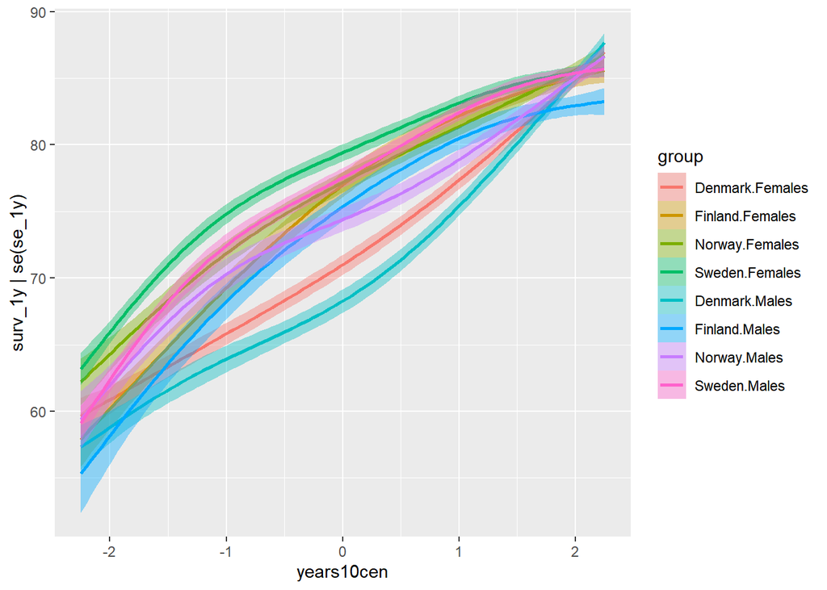

```r
set.seed(17)
colon_1y_model<-brm(surv_1y|se(se_1y)~group+s(years10cen,by=group,k=5)
    ,family="Gaussian",save_pars = save_pars(all = TRUE),prior=prior_group,seed=17
    ,data=colon,iter=7000, warmup=2000,chains=2,cores=1,control = list(adapt_delta = 0.98))
conditional_effects(colon_1y_model,effects='years10cen:group')
```

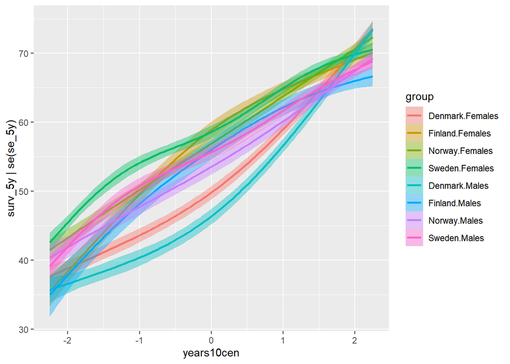

```r
colon_5y_model<-brm(surv_5y|se(se_5y)~group+s(years10cen,by=group,k=5)
    ,family="Gaussian",save_pars = save_pars(all = TRUE),prior=prior_group,seed=17
    ,data=colon,iter=7000, warmup=2000,chains=2,cores=1,control = list(adapt_delta = 0.98))
conditional_effects(colon_5y_model,effects='years10cen:group')
```

### Defining rectal models

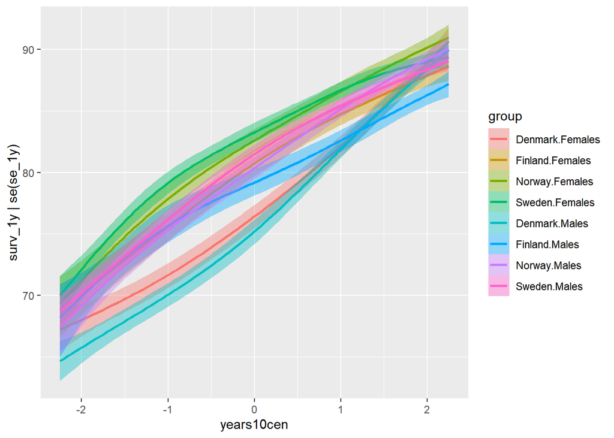

```r
set.seed(17)
rectum_1y_model<-brm(surv_1y|se(se_1y)~group+s(years10cen,by=group,k=5)
      ,family="Gaussian",save_pars = save_pars(all = TRUE),prior=prior_group,seed=17
      ,data=rectum,iter=7000, warmup=2000,chains=2,cores=1,control = list(adapt_delta = 0.98))
conditional_effects(rectum_1y_model,effects='years10cen:group')
```

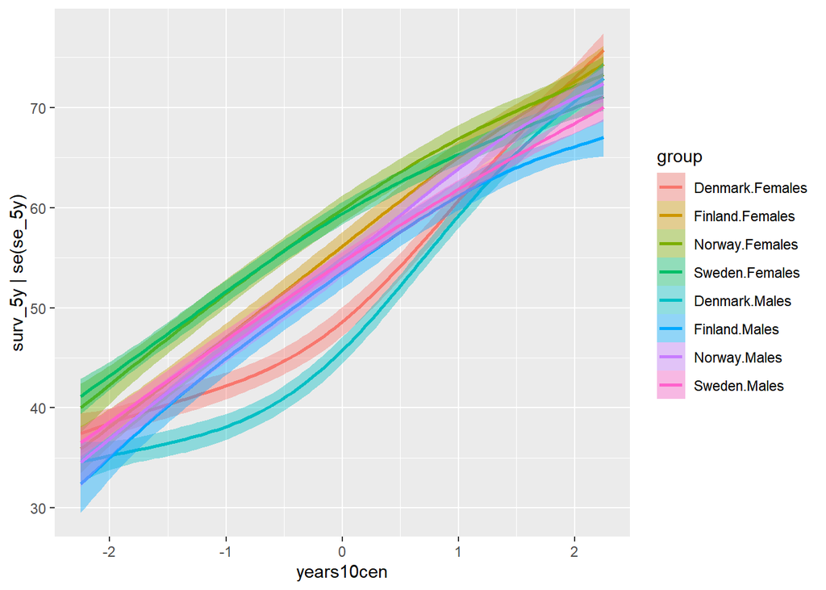

```r
rectum_5y_model<-brm(surv_5y|se(se_5y)~group+s(years10cen,by=group,k=5)
     ,family="Gaussian",save_pars = save_pars(all = TRUE),prior=prior_group,seed=17
     ,data=rectum,iter=7000, warmup=2000,chains=2,cores=1,control = list(adapt_delta = 0.98))
conditional_effects(rectum_5y_model,effects='years10cen:group')
```

### Defining Small intestine models

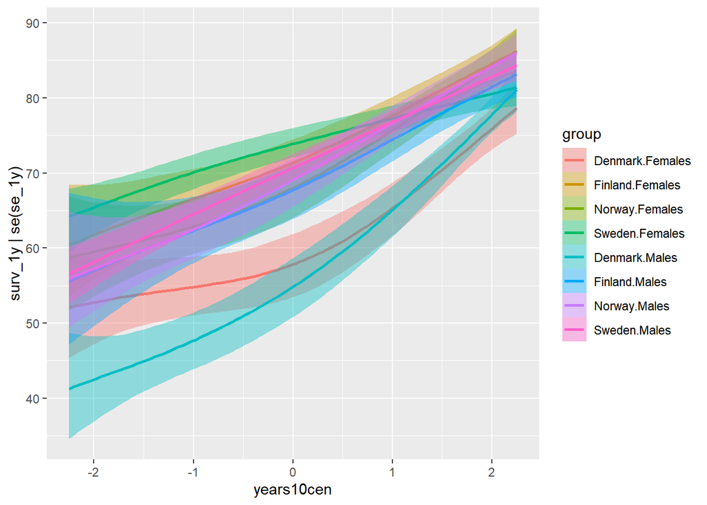

```r
set.seed(17)
small_intestine_1y_model<-brm(surv_1y|se(se_1y)~group+s(years10cen,by=group,k=5),
   family="Gaussian",save_pars = save_pars(all = TRUE),prior=prior_group,seed=17,
   data=small_intestine,iter=7000, warmup=2000,
   chains=2,cores=1,control = list(adapt_delta = 0.98))
conditional_effects(small_intestine_1y_model,effects='years10cen:group')
```

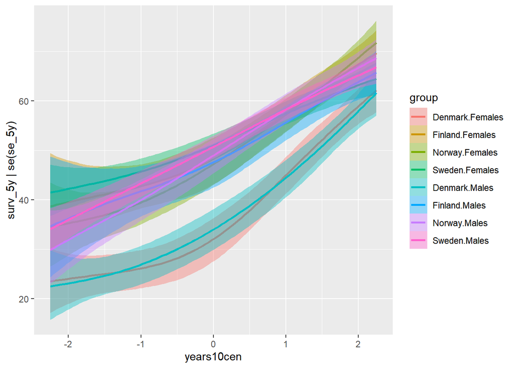

```r
small_intestine_5y_model<-brm(surv_5y|se(se_5y)~group+s(years10cen,by=group,k=5)
    ,family="Gaussian",save_pars = save_pars(all = TRUE),prior=prior_group,seed=17
   ,data=small_intestine,iter=7000, warmup=2000,chains=2,cores=1,control = list(adapt_delta = 0.98))
conditional_effects(small_intestine_5y_model,effects='years10cen:group')
```

## Diagnostics of models

In general, diagnostics uses:

[1] *summary(model)*: the columns of intereste are *Rhat* (when = 1, model converged well), and columns *Tail_ESS* and *Bulk_ESS* which should never go under 1,000 and should be mostly above 2,000.

[2] *pp_check* : graphical tools to explore how well the model predicts real data.

[not shown in this report] : use also *plot(model)* (not shown as it produces a lot of figures).

### Colon model diagnostics

```r
summary(colon_1y_model)
```

```
##  Family: gaussian
##   Links: mu = identity; sigma = identity
## Formula: surv_1y | se(se_1y) ~ group + s(years10cen, by = group, k = 5)
##    Data: colon (Number of observations: 80)
##   Draws: 2 chains, each with iter = 7000; warmup = 2000; thin = 1;
##          total post-warmup draws = 10000
##
## Smooth Terms:
##                                        Estimate Est.Error l-95% CI u-95% CI
## sds(syears10cengroupDenmark.Females_1)     7.12      4.26     2.44    17.86
## sds(syears10cengroupFinland.Females_1)    11.39      5.50     4.92    24.95
## sds(syears10cengroupNorway.Females_1)      9.07      5.24     2.78    22.49
## sds(syears10cengroupSweden.Females_1)     14.33      6.60     6.17    31.02
## sds(syears10cengroupDenmark.Males_1)      12.27      6.11     5.04    27.44
## sds(syears10cengroupFinland.Males_1)      13.75      6.61     5.76    30.50
## sds(syears10cengroupNorway.Males_1)       14.48      7.60     4.81    32.19
## sds(syears10cengroupSweden.Males_1)       16.97      7.42     7.50    35.77
##                                        Rhat Bulk_ESS Tail_ESS
## sds(syears10cengroupDenmark.Females_1) 1.00     6019     6701
## sds(syears10cengroupFinland.Females_1) 1.00     6757     7013
## sds(syears10cengroupNorway.Females_1)  1.00     4969     5632
## sds(syears10cengroupSweden.Females_1)  1.00     5194     6091
## sds(syears10cengroupDenmark.Males_1)   1.00     5384     6235
## sds(syears10cengroupFinland.Males_1)   1.00     6141     6221
## sds(syears10cengroupNorway.Males_1)    1.00     4051     4339
## sds(syears10cengroupSweden.Males_1)    1.00     4582     5568
##
## Population-Level Effects:
##                                    Estimate Est.Error l-95% CI u-95% CI Rhat
## Intercept                             72.02      0.21    71.61    72.44 1.00
## groupFinland.Females                   2.67      0.34     2.00     3.35 1.00
## groupNorway.Females                    4.02      0.30     3.43     4.61 1.00
## groupSweden.Females                    5.66      0.27     5.13     6.18 1.00
## groupDenmark.Males                    -1.69      0.31    -2.30    -1.08 1.00
## groupFinland.Males                     0.95      0.39     0.17     1.71 1.00
## groupNorway.Males                      2.08      0.33     1.44     2.71 1.00
## groupSweden.Males                      3.93      0.28     3.39     4.48 1.00
## syears10cen:groupDenmark.Females_1    59.29      5.06    49.50    69.51 1.00
## syears10cen:groupFinland.Females_1    52.33      6.90    38.85    65.87 1.00
## syears10cen:groupNorway.Females_1     58.13      6.45    45.99    71.24 1.00
```

[output cut: 15 more lines]

```
## syears10cen:groupFinland.Females_1    10182     7918
## syears10cen:groupNorway.Females_1      8218     6205
## syears10cen:groupSweden.Females_1     12243     7250
## syears10cen:groupDenmark.Males_1       9730     7047
## syears10cen:groupFinland.Males_1       8323     7323
## syears10cen:groupNorway.Males_1        6307     4786
## syears10cen:groupSweden.Males_1       10753     6952
##
## Family Specific Parameters:
##       Estimate Est.Error l-95% CI u-95% CI Rhat Bulk_ESS Tail_ESS
## sigma     0.00      0.00     0.00     0.00   NA       NA       NA
##
## Draws were sampled using sampling(NUTS). For each parameter, Bulk_ESS
## and Tail_ESS are effective sample size measures, and Rhat is the potential
## scale reduction factor on split chains (at convergence, Rhat = 1).
```

```r
summary(colon_5y_model)
```

```
##  Family: gaussian
##   Links: mu = identity; sigma = identity
## Formula: surv_5y | se(se_5y) ~ group + s(years10cen, by = group, k = 5)
##    Data: colon (Number of observations: 80)
##   Draws: 2 chains, each with iter = 7000; warmup = 2000; thin = 1;
##          total post-warmup draws = 10000
##
## Smooth Terms:
##                                        Estimate Est.Error l-95% CI u-95% CI
## sds(syears10cengroupDenmark.Females_1)    12.92      6.36     5.52    29.09
## sds(syears10cengroupFinland.Females_1)    13.62      6.55     5.60    30.53
## sds(syears10cengroupNorway.Females_1)      3.79      4.10     0.11    14.92
## sds(syears10cengroupSweden.Females_1)     18.67      8.93     6.72    41.16
## sds(syears10cengroupDenmark.Males_1)      16.22      7.44     7.40    35.22
## sds(syears10cengroupFinland.Males_1)      13.73      7.16     4.98    32.00
## sds(syears10cengroupNorway.Males_1)        6.43      5.11     0.57    19.49
## sds(syears10cengroupSweden.Males_1)       15.73      8.41     4.47    36.02
##                                        Rhat Bulk_ESS Tail_ESS
## sds(syears10cengroupDenmark.Females_1) 1.00     5248     6229
## sds(syears10cengroupFinland.Females_1) 1.00     5861     6306
## sds(syears10cengroupNorway.Females_1)  1.00     4015     5434
## sds(syears10cengroupSweden.Females_1)  1.00     3922     4555
## sds(syears10cengroupDenmark.Males_1)   1.00     5386     6099
## sds(syears10cengroupFinland.Males_1)   1.00     5596     6981
## sds(syears10cengroupNorway.Males_1)    1.00     4130     3956
## sds(syears10cengroupSweden.Males_1)    1.00     3206     3185
##
## Population-Level Effects:
##                                    Estimate Est.Error l-95% CI u-95% CI Rhat
## Intercept                             52.38      0.25    51.89    52.88 1.00
## groupFinland.Females                   3.69      0.41     2.89     4.50 1.00
## groupNorway.Females                    4.55      0.38     3.81     5.28 1.00
## groupSweden.Females                    6.14      0.34     5.49     6.79 1.00
## groupDenmark.Males                    -2.35      0.38    -3.11    -1.61 1.00
## groupFinland.Males                     1.58      0.49     0.61     2.52 1.00
## groupNorway.Males                      1.75      0.41     0.95     2.56 1.00
## groupSweden.Males                      3.10      0.35     2.43     3.79 1.00
## syears10cen:groupDenmark.Females_1    76.57      7.01    62.71    90.44 1.00
## syears10cen:groupFinland.Females_1    70.95      8.55    53.99    87.71 1.00
## syears10cen:groupNorway.Females_1     63.56      4.75    54.93    75.04 1.00
```

[output cut: 15 more lines]

```
## syears10cen:groupFinland.Females_1     7797     7374
## syears10cen:groupNorway.Females_1      5941     4780
## syears10cen:groupSweden.Females_1      9394     6987
## syears10cen:groupDenmark.Males_1       7345     7141
## syears10cen:groupFinland.Males_1       7317     7160
## syears10cen:groupNorway.Males_1        6974     6764
## syears10cen:groupSweden.Males_1        6368     4573
##
## Family Specific Parameters:
##       Estimate Est.Error l-95% CI u-95% CI Rhat Bulk_ESS Tail_ESS
## sigma     0.00      0.00     0.00     0.00   NA       NA       NA
##
## Draws were sampled using sampling(NUTS). For each parameter, Bulk_ESS
## and Tail_ESS are effective sample size measures, and Rhat is the potential
## scale reduction factor on split chains (at convergence, Rhat = 1).
```

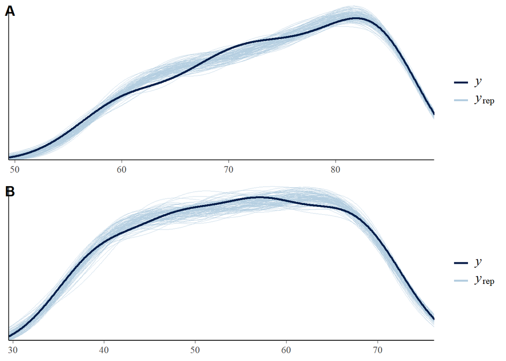

```r
pla<-pp_check(colon_1y_model,type='dens_overlay',ndraws = 100)
plb<-pp_check(colon_5y_model,type='dens_overlay',ndraws = 100)
plot_grid(pla, plb, labels=c("A", "B"), ncol = 1, nrow = 2)
```

```r
pla<-pp_check(colon_1y_model,type='scatter_avg')
```

```
## Using all posterior draws for ppc type 'scatter_avg' by default.
```

```r
plb<-pp_check(colon_5y_model,type='scatter_avg')
```

```
## Using all posterior draws for ppc type 'scatter_avg' by default.
```

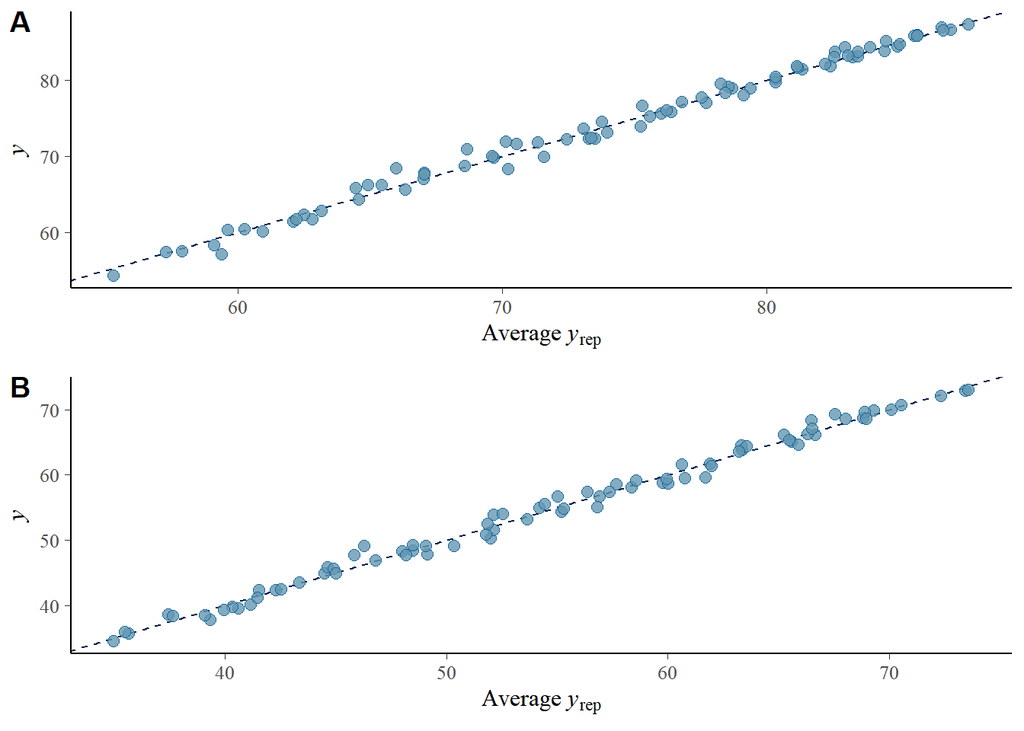

```r
plot_grid(pla, plb, labels=c("A", "B"), ncol = 1, nrow = 2)
```

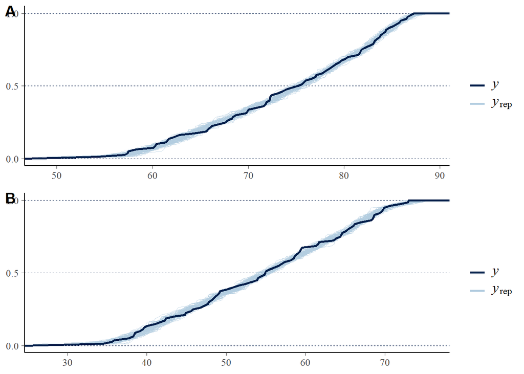

```r
pla<-pp_check(colon_1y_model,type='ecdf_overlay',ndraws = 100)
plb<-pp_check(colon_5y_model,type='ecdf_overlay',ndraws = 100)
plot_grid(pla, plb, labels=c("A", "B"), ncol = 1, nrow = 2)
```

```r
pla<-pp_check(colon_1y_model,type ="stat", stat = "mean")
```

```
## Using all posterior draws for ppc type 'stat' by default.
```

```r
plb<-pp_check(colon_5y_model,type = "stat", stat = "mean")
```

```
## Using all posterior draws for ppc type 'stat' by default.
```

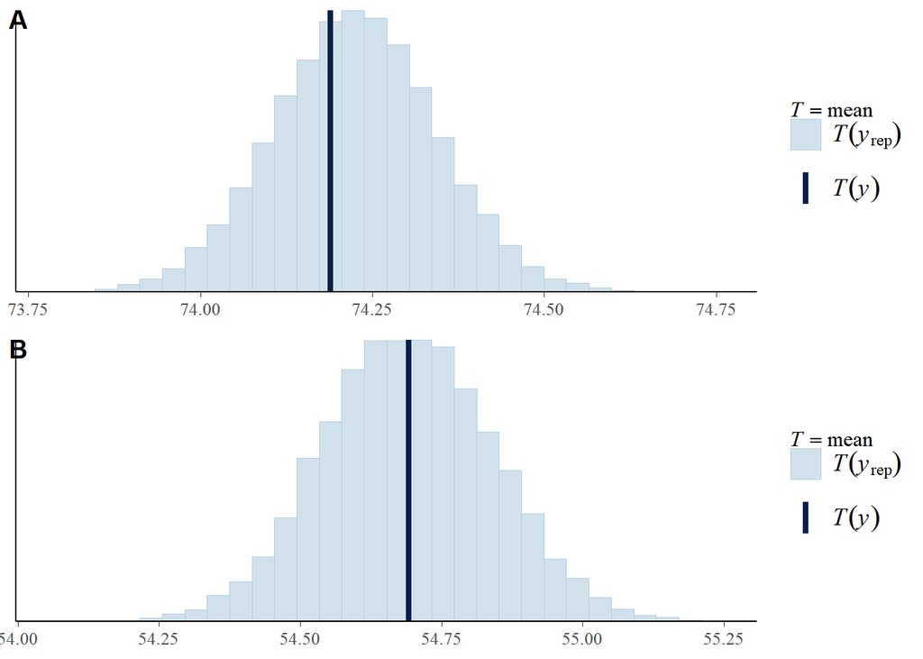

```r
plot_grid(pla, plb, labels=c("A", "B"), ncol = 1, nrow = 2)
```

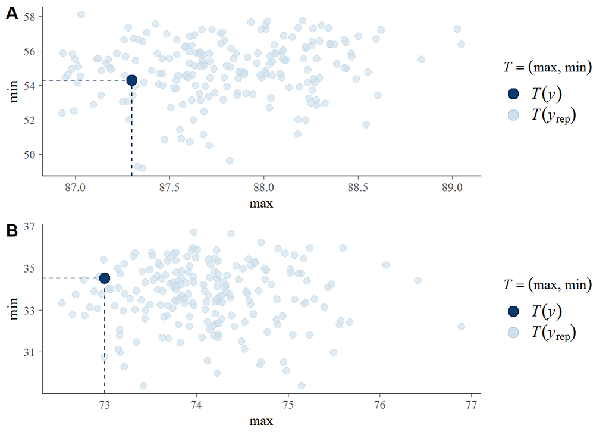

```r
pla<-pp_check(colon_1y_model,type="stat_2d", stat = c("max", "min"),ndraws=200)
plb<-pp_check(colon_5y_model,type="stat_2d", stat = c("max", "min"),ndraws=200)
plot_grid(pla, plb, labels=c("A", "B"), ncol = 1, nrow = 2)
```

```r
summary(colon_1y_model)
```

[output not shown]

[output cut: 15 more lines]

```
## syears10cen:groupFinland.Females_1    10182     7918
## syears10cen:groupNorway.Females_1      8218     6205
## syears10cen:groupSweden.Females_1     12243     7250
## syears10cen:groupDenmark.Males_1       9730     7047
## syears10cen:groupFinland.Males_1       8323     7323
## syears10cen:groupNorway.Males_1        6307     4786
## syears10cen:groupSweden.Males_1       10753     6952
##
## Family Specific Parameters:
##       Estimate Est.Error l-95% CI u-95% CI Rhat Bulk_ESS Tail_ESS
## sigma     0.00      0.00     0.00     0.00   NA       NA       NA
##
## Draws were sampled using sampling(NUTS). For each parameter, Bulk_ESS
## and Tail_ESS are effective sample size measures, and Rhat is the potential
## scale reduction factor on split chains (at convergence, Rhat = 1).
```

```r
summary(colon_5y_model)
```

```
##  Family: gaussian
##   Links: mu = identity; sigma = identity
## Formula: surv_5y | se(se_5y) ~ group + s(years10cen, by = group, k = 5)
##    Data: colon (Number of observations: 80)
##   Draws: 2 chains, each with iter = 7000; warmup = 2000; thin = 1;
##          total post-warmup draws = 10000
##
## Smooth Terms:
##                                        Estimate Est.Error l-95% CI u-95% CI
## sds(syears10cengroupDenmark.Females_1)    12.92      6.36     5.52    29.09
## sds(syears10cengroupFinland.Females_1)    13.62      6.55     5.60    30.53
## sds(syears10cengroupNorway.Females_1)      3.79      4.10     0.11    14.92
## sds(syears10cengroupSweden.Females_1)     18.67      8.93     6.72    41.16
## sds(syears10cengroupDenmark.Males_1)      16.22      7.44     7.40    35.22
## sds(syears10cengroupFinland.Males_1)      13.73      7.16     4.98    32.00
## sds(syears10cengroupNorway.Males_1)        6.43      5.11     0.57    19.49
## sds(syears10cengroupSweden.Males_1)       15.73      8.41     4.47    36.02
##                                        Rhat Bulk_ESS Tail_ESS
## sds(syears10cengroupDenmark.Females_1) 1.00     5248     6229
## sds(syears10cengroupFinland.Females_1) 1.00     5861     6306
## sds(syears10cengroupNorway.Females_1)  1.00     4015     5434
## sds(syears10cengroupSweden.Females_1)  1.00     3922     4555
## sds(syears10cengroupDenmark.Males_1)   1.00     5386     6099
## sds(syears10cengroupFinland.Males_1)   1.00     5596     6981
## sds(syears10cengroupNorway.Males_1)    1.00     4130     3956
## sds(syears10cengroupSweden.Males_1)    1.00     3206     3185
##
## Population-Level Effects:
##                                    Estimate Est.Error l-95% CI u-95% CI Rhat
## Intercept                             52.38      0.25    51.89    52.88 1.00
## groupFinland.Females                   3.69      0.41     2.89     4.50 1.00
## groupNorway.Females                    4.55      0.38     3.81     5.28 1.00
## groupSweden.Females                    6.14      0.34     5.49     6.79 1.00
## groupDenmark.Males                    -2.35      0.38    -3.11    -1.61 1.00
## groupFinland.Males                     1.58      0.49     0.61     2.52 1.00
## groupNorway.Males                      1.75      0.41     0.95     2.56 1.00
## groupSweden.Males                      3.10      0.35     2.43     3.79 1.00
## syears10cen:groupDenmark.Females_1    76.57      7.01    62.71    90.44 1.00
## syears10cen:groupFinland.Females_1    70.95      8.55    53.99    87.71 1.00
## syears10cen:groupNorway.Females_1     63.56      4.75    54.93    75.04 1.00
```

[output cut: 15 more lines]

```
## syears10cen:groupFinland.Females_1     7797     7374
## syears10cen:groupNorway.Females_1      5941     4780
## syears10cen:groupSweden.Females_1      9394     6987
## syears10cen:groupDenmark.Males_1       7345     7141
## syears10cen:groupFinland.Males_1       7317     7160
## syears10cen:groupNorway.Males_1        6974     6764
## syears10cen:groupSweden.Males_1        6368     4573
##
## Family Specific Parameters:
##       Estimate Est.Error l-95% CI u-95% CI Rhat Bulk_ESS Tail_ESS
## sigma     0.00      0.00     0.00     0.00   NA       NA       NA
##
## Draws were sampled using sampling(NUTS). For each parameter, Bulk_ESS
## and Tail_ESS are effective sample size measures, and Rhat is the potential
## scale reduction factor on split chains (at convergence, Rhat = 1).
```

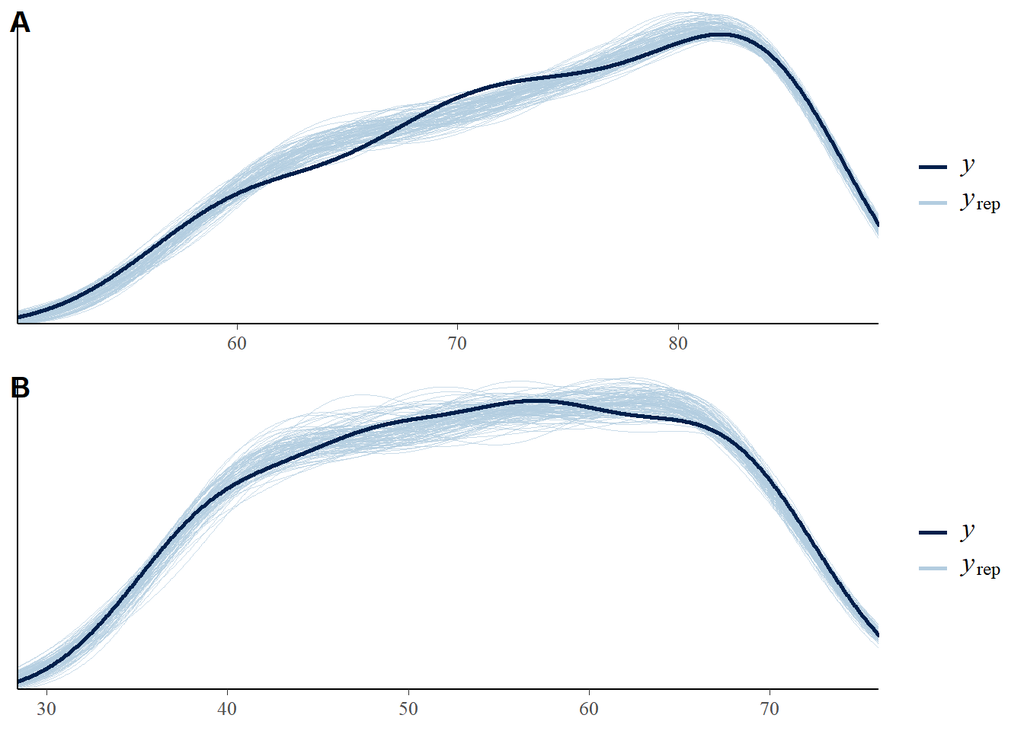

```r
pla<-pp_check(colon_1y_model,type='dens_overlay',ndraws = 100)
plb<-pp_check(colon_5y_model,type='dens_overlay',ndraws = 100)
plot_grid(pla, plb, labels=c("A", "B"), ncol = 1, nrow = 2)
```

```r
pla<-pp_check(colon_1y_model,type='scatter_avg')
```

```
## Using all posterior draws for ppc type 'scatter_avg' by default.
```

```r
plb<-pp_check(colon_5y_model,type='scatter_avg')
```

```
## Using all posterior draws for ppc type 'scatter_avg' by default.
```

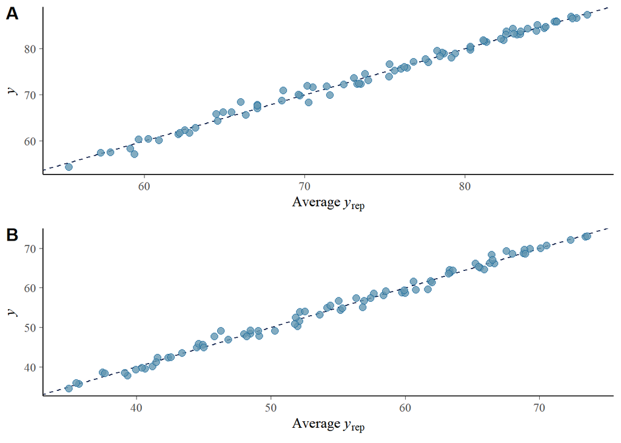

```r
plot_grid(pla, plb, labels=c("A", "B"), ncol = 1, nrow = 2)
```

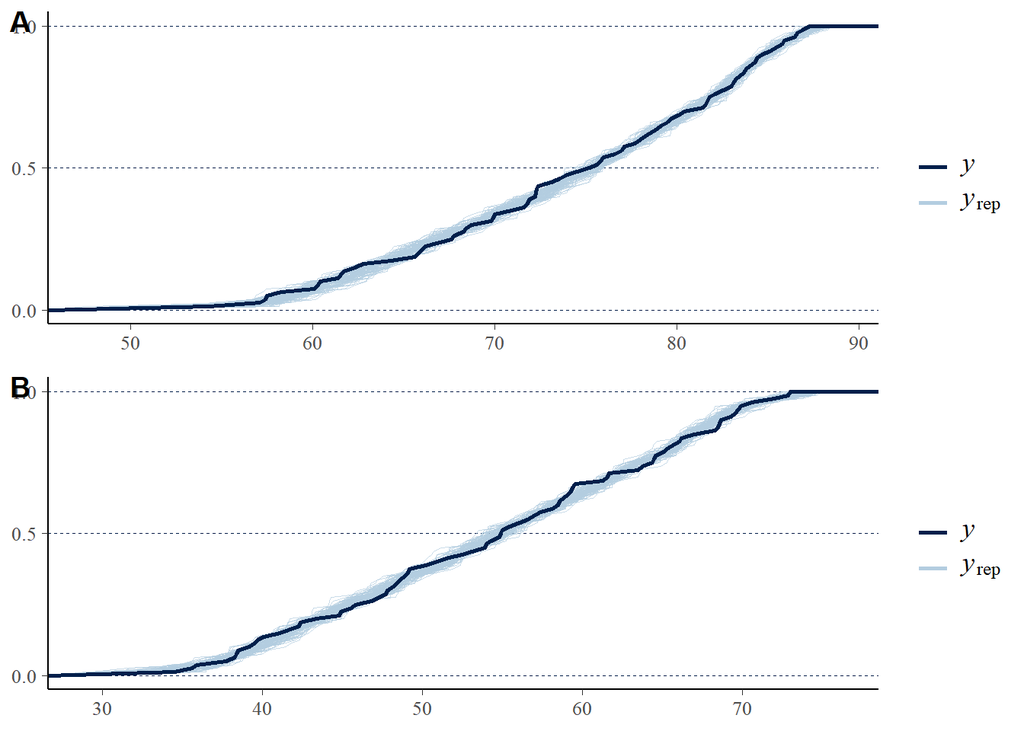

```r
pla<-pp_check(colon_1y_model,type='ecdf_overlay',ndraws = 100)
plb<-pp_check(colon_5y_model,type='ecdf_overlay',ndraws = 100)
plot_grid(pla, plb, labels=c("A", "B"), ncol = 1, nrow = 2)
```

```r
pla<-pp_check(colon_1y_model,type ="stat", stat = "mean")
```

```
## Using all posterior draws for ppc type 'stat' by default.
```

```r
plb<-pp_check(colon_5y_model,type = "stat", stat = "mean")
```

```
## Using all posterior draws for ppc type 'stat' by default.
```

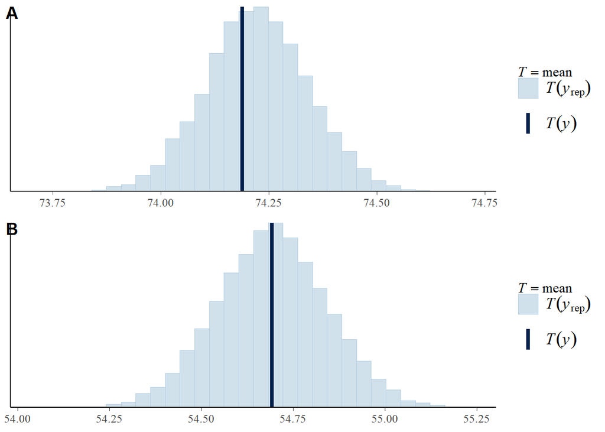

```r
plot_grid(pla, plb, labels=c("A", "B"), ncol = 1, nrow = 2)
```

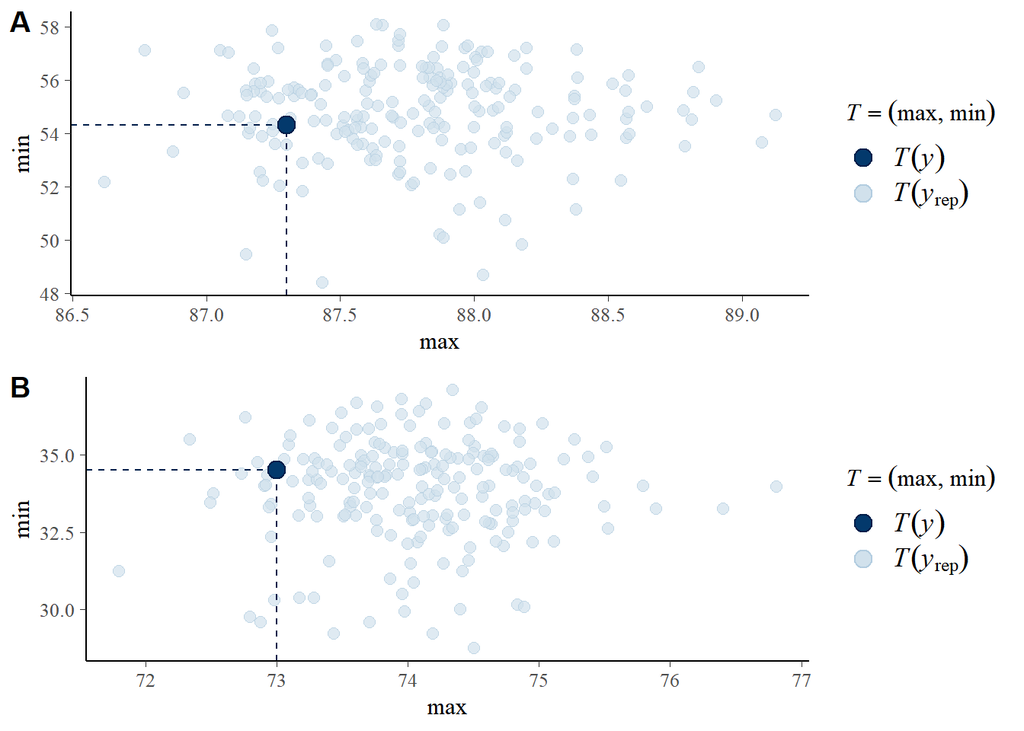

```r
pla<-pp_check(colon_1y_model,type="stat_2d", stat = c("max", "min"),ndraws=200)
plb<-pp_check(colon_5y_model,type="stat_2d", stat = c("max", "min"),ndraws=200)
plot_grid(pla, plb, labels=c("A", "B"), ncol = 1, nrow = 2)
```

### Small intestine diag.

```r
summary(small_intestine_1y_model)
```

```
##  Family: gaussian
##   Links: mu = identity; sigma = identity
## Formula: surv_1y | se(se_1y) ~ group + s(years10cen, by = group, k = 5)
##    Data: small_intestine (Number of observations: 79)
##   Draws: 2 chains, each with iter = 7000; warmup = 2000; thin = 1;
##          total post-warmup draws = 10000
##
## Smooth Terms:
##                                        Estimate Est.Error l-95% CI u-95% CI
## sds(syears10cengroupDenmark.Females_1)    18.19     10.45     4.61    43.98
## sds(syears10cengroupFinland.Females_1)     9.96      9.29     0.42    31.88
## sds(syears10cengroupNorway.Females_1)     13.10      9.40     1.02    35.99
## sds(syears10cengroupSweden.Females_1)      7.18      6.43     0.22    23.77
## sds(syears10cengroupDenmark.Males_1)      15.56      8.84     2.97    37.68
## sds(syears10cengroupFinland.Males_1)       9.88      8.99     0.32    32.50
## sds(syears10cengroupNorway.Males_1)        9.53      8.32     0.29    31.18
## sds(syears10cengroupSweden.Males_1)        5.56      5.29     0.19    19.12
##                                        Rhat Bulk_ESS Tail_ESS
## sds(syears10cengroupDenmark.Females_1) 1.00     5660     4952
## sds(syears10cengroupFinland.Females_1) 1.00     5114     4809
## sds(syears10cengroupNorway.Females_1)  1.00     4173     2809
## sds(syears10cengroupSweden.Females_1)  1.00     4320     4011
## sds(syears10cengroupDenmark.Males_1)   1.00     4929     3319
## sds(syears10cengroupFinland.Males_1)   1.00     4726     4057
## sds(syears10cengroupNorway.Males_1)    1.00     4499     4380
## sds(syears10cengroupSweden.Males_1)    1.00     5299     4927
##
## Population-Level Effects:
##                                    Estimate Est.Error l-95% CI u-95% CI Rhat
## Intercept                             61.49      1.15    59.30    63.76 1.00
## groupFinland.Females                  11.04      1.69     7.79    14.36 1.00
## groupNorway.Females                    8.71      1.61     5.62    11.91 1.00
## groupSweden.Females                   12.05      1.35     9.38    14.64 1.00
## groupDenmark.Males                    -3.67      1.62    -6.85    -0.53 1.00
## groupFinland.Males                     7.31      1.85     3.70    10.97 1.00
## groupNorway.Males                      8.62      1.64     5.40    11.79 1.00
## groupSweden.Males                      9.28      1.34     6.66    11.90 1.00
## syears10cen:groupDenmark.Females_1    61.52     20.82    21.62   106.65 1.00
## syears10cen:groupFinland.Females_1    54.23     15.99    22.33    88.91 1.00
## syears10cen:groupNorway.Females_1     51.56     18.46     8.23    82.69 1.00
```

[output cut: 15 more lines]

```
## syears10cen:groupFinland.Females_1     5933     5026
## syears10cen:groupNorway.Females_1      5380     5555
## syears10cen:groupSweden.Females_1      5545     5022
## syears10cen:groupDenmark.Males_1       6757     6641
## syears10cen:groupFinland.Males_1       5593     5169
## syears10cen:groupNorway.Males_1        5523     5623
## syears10cen:groupSweden.Males_1        5689     4372
##
## Family Specific Parameters:
##       Estimate Est.Error l-95% CI u-95% CI Rhat Bulk_ESS Tail_ESS
## sigma     0.00      0.00     0.00     0.00   NA       NA       NA
##
## Draws were sampled using sampling(NUTS). For each parameter, Bulk_ESS
## and Tail_ESS are effective sample size measures, and Rhat is the potential
## scale reduction factor on split chains (at convergence, Rhat = 1).
```

```r
summary(small_intestine_5y_model)
```

```
##  Family: gaussian
##   Links: mu = identity; sigma = identity
## Formula: surv_5y | se(se_5y) ~ group + s(years10cen, by = group, k = 5)
##    Data: small_intestine (Number of observations: 79)
##   Draws: 2 chains, each with iter = 7000; warmup = 2000; thin = 1;
##          total post-warmup draws = 10000
##
## Smooth Terms:
##                                        Estimate Est.Error l-95% CI u-95% CI
## sds(syears10cengroupDenmark.Females_1)    24.72     13.26     8.05    58.00
## sds(syears10cengroupFinland.Females_1)    17.74     12.52     1.22    48.59
## sds(syears10cengroupNorway.Females_1)     17.37     11.40     1.83    45.13
## sds(syears10cengroupSweden.Females_1)     11.64      9.67     0.49    35.22
## sds(syears10cengroupDenmark.Males_1)      19.96     11.31     4.76    48.14
## sds(syears10cengroupFinland.Males_1)      14.36     13.80     0.47    48.06
## sds(syears10cengroupNorway.Males_1)       10.21      9.82     0.31    35.29
## sds(syears10cengroupSweden.Males_1)        7.99      7.84     0.25    28.04
##                                        Rhat Bulk_ESS Tail_ESS
## sds(syears10cengroupDenmark.Females_1) 1.00     5790     5315
## sds(syears10cengroupFinland.Females_1) 1.00     4514     3456
## sds(syears10cengroupNorway.Females_1)  1.00     4319     3212
## sds(syears10cengroupSweden.Females_1)  1.00     4287     4300
## sds(syears10cengroupDenmark.Males_1)   1.00     4741     3328
## sds(syears10cengroupFinland.Males_1)   1.00     5259     5739
## sds(syears10cengroupNorway.Males_1)    1.00     4654     5009
## sds(syears10cengroupSweden.Males_1)    1.00     4833     5084
##
## Population-Level Effects:
##                                    Estimate Est.Error l-95% CI u-95% CI Rhat
## Intercept                             37.43      1.12    35.26    39.64 1.00
## groupFinland.Females                  13.85      1.79    10.35    17.41 1.00
## groupNorway.Females                   12.37      1.67     9.15    15.62 1.00
## groupSweden.Females                   14.61      1.41    11.83    17.44 1.00
## groupDenmark.Males                     0.09      1.61    -3.00     3.19 1.00
## groupFinland.Males                    11.77      2.01     7.78    15.69 1.00
## groupNorway.Males                     11.97      1.72     8.59    15.38 1.00
## groupSweden.Males                     13.44      1.40    10.71    16.19 1.00
## syears10cen:groupDenmark.Females_1    67.19     24.09    17.15   111.44 1.00
## syears10cen:groupFinland.Females_1    54.82     25.75    -4.83    98.54 1.00
## syears10cen:groupNorway.Females_1     67.15     23.22    13.97   106.42 1.00
```

[output cut: 15 more lines]

```
## syears10cen:groupFinland.Females_1     6918     6428
## syears10cen:groupNorway.Females_1      6738     6861
## syears10cen:groupSweden.Females_1      5332     6270
## syears10cen:groupDenmark.Males_1       7439     7025
## syears10cen:groupFinland.Males_1       6289     5891
## syears10cen:groupNorway.Males_1        5866     4691
## syears10cen:groupSweden.Males_1        6966     5453
##
## Family Specific Parameters:
##       Estimate Est.Error l-95% CI u-95% CI Rhat Bulk_ESS Tail_ESS
## sigma     0.00      0.00     0.00     0.00   NA       NA       NA
##
## Draws were sampled using sampling(NUTS). For each parameter, Bulk_ESS
## and Tail_ESS are effective sample size measures, and Rhat is the potential
## scale reduction factor on split chains (at convergence, Rhat = 1).
```

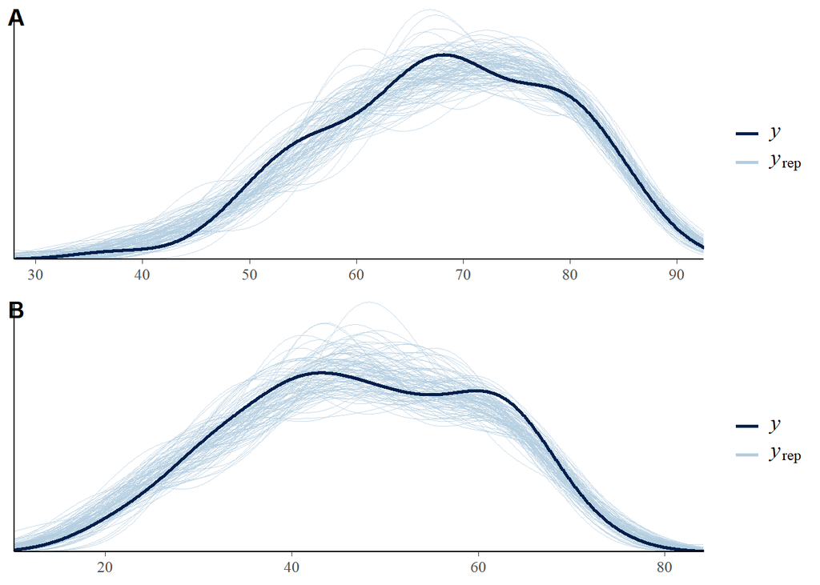

```r
pla<-pp_check(small_intestine_1y_model,type='dens_overlay',ndraws = 100)
plb<-pp_check(small_intestine_5y_model,type='dens_overlay',ndraws = 100)
plot_grid(pla, plb, labels=c("A", "B"), ncol = 1, nrow = 2)
```

```r
pla<-pp_check(small_intestine_1y_model,type='scatter_avg')
```

```
## Using all posterior draws for ppc type 'scatter_avg' by default.
```

```r
plb<-pp_check(small_intestine_5y_model,type='scatter_avg')
```

```
## Using all posterior draws for ppc type 'scatter_avg' by default.
```

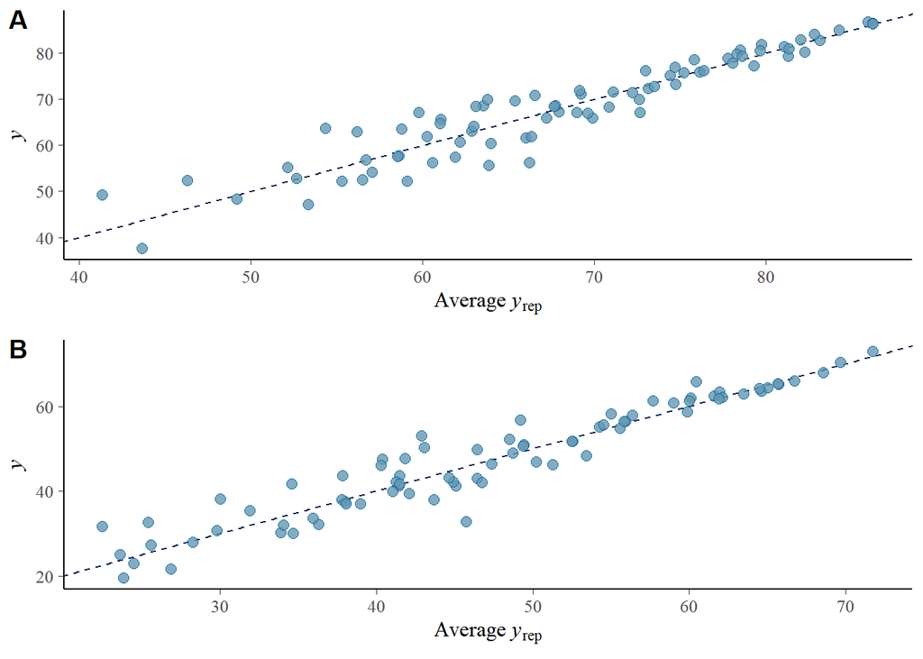

```r
plot_grid(pla, plb, labels=c("A", "B"), ncol = 1, nrow = 2)
```

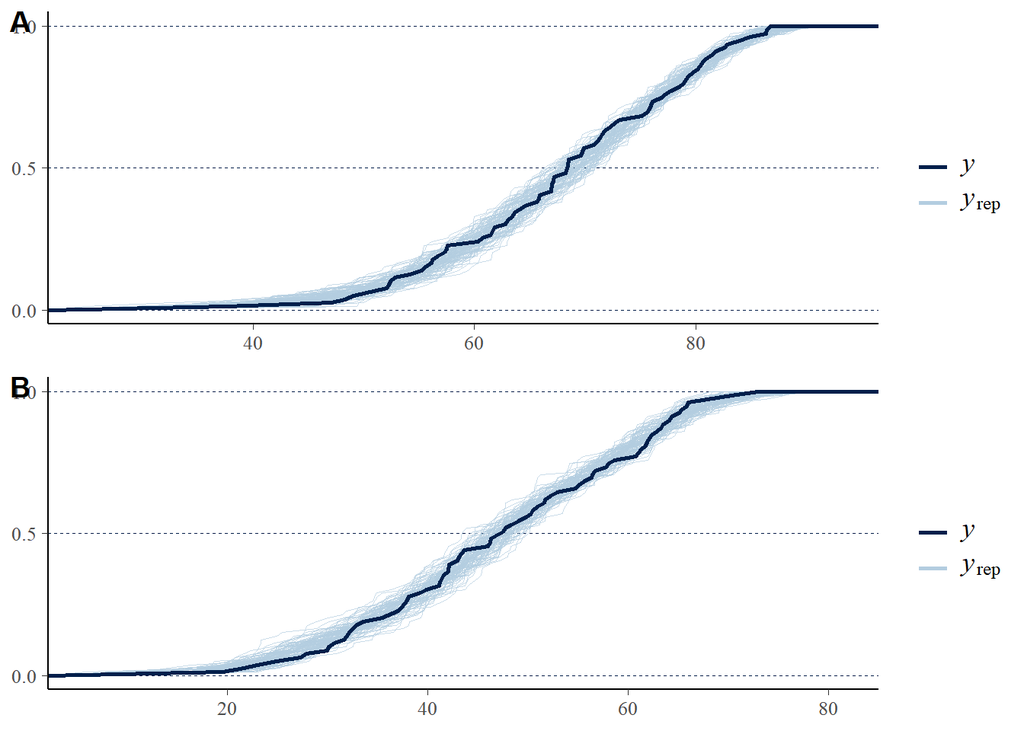

```r
pla<-pp_check(small_intestine_1y_model,type='ecdf_overlay',ndraws = 100)
plb<-pp_check(small_intestine_5y_model,type='ecdf_overlay',ndraws = 100)
plot_grid(pla, plb, labels=c("A", "B"), ncol = 1, nrow = 2)
```

```r
pla<-pp_check(small_intestine_1y_model,type ="stat", stat = "mean")
```

```
## Using all posterior draws for ppc type 'stat' by default.
```

```r
plb<-pp_check(small_intestine_5y_model,type = "stat", stat = "mean")
```

```
## Using all posterior draws for ppc type 'stat' by default.
```

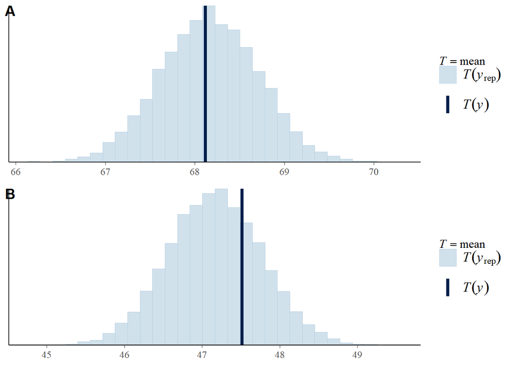

```r
plot_grid(pla, plb, labels=c("A", "B"), ncol = 1, nrow = 2)
```

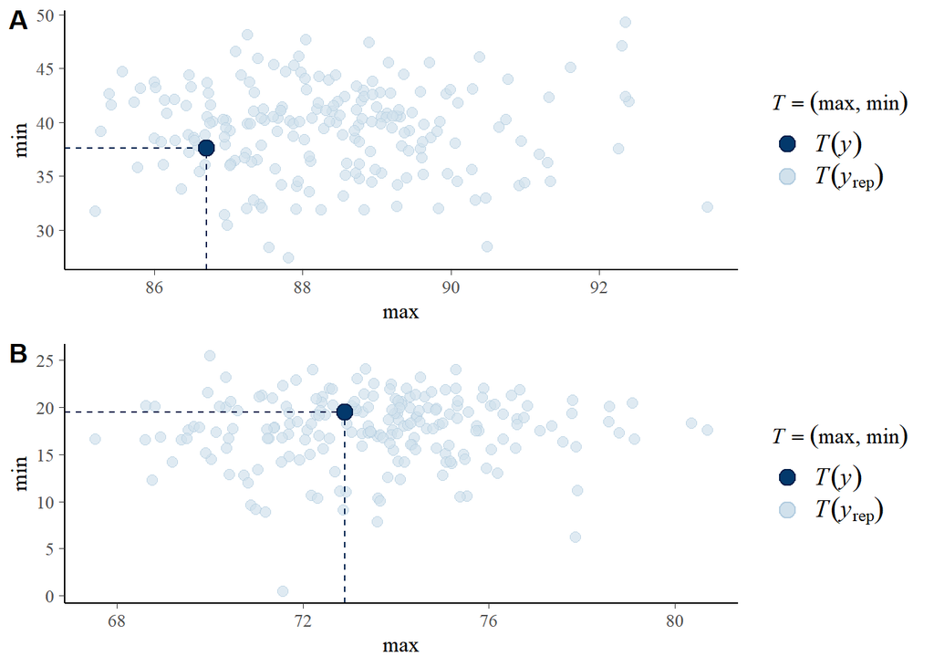

```r
pla<-pp_check(small_intestine_1y_model,type="stat_2d", stat = c("max", "min"),ndraws=200)
plb<-pp_check(small_intestine_5y_model,type="stat_2d", stat = c("max", "min"),ndraws=200)
plot_grid(pla, plb, labels=c("A", "B"), ncol = 1, nrow = 2)
```

## Extraction of posterior samples

### Colon models samples

```r
first <- expand.grid(years10cen = seq(-2.45, 2.45, length=500),
                     group = c('Denmark.Females','Finland.Females','Norway.Females','Sweden.Females','Denmark.Males','Finland.Males','Norway.Males','Sweden.Males'), y = 0)
yreal <- (first[,1]*10)+1995.5
ms_1y<-posterior_smooths(colon_1y_model,smooth="s(years10cen,by=group,k=5)",newdata = first)
post_fix<-as.data.frame(colon_1y_model, variable = c("b_Intercept","b_groupFinland.Females","b_groupNorway.Females","b_groupSweden.Females","b_groupDenmark.Males", "b_groupFinland.Males","b_groupNorway.Males","b_groupSweden.Males"))

post_colon_den_fem_1y<-ms_1y[,1:500]     +post_fix[,1]
post_colon_fin_fem_1y<-ms_1y[,501:1000]  +post_fix[,1]+post_fix[,2]
post_colon_nor_fem_1y<-ms_1y[,1001:1500] +post_fix[,1]+post_fix[,3]
post_colon_swe_fem_1y<-ms_1y[,1501:2000] +post_fix[,1]+post_fix[,4]
post_colon_den_mal_1y<-ms_1y[,2001:2500] +post_fix[,1]+post_fix[,5]
post_colon_fin_mal_1y<-ms_1y[,2501:3000] +post_fix[,1]+post_fix[,6]
post_colon_nor_mal_1y<-ms_1y[,3001:3500] +post_fix[,1]+post_fix[,7]
post_colon_swe_mal_1y<-ms_1y[,3501:4000] +post_fix[,1]+post_fix[,8]

post_fix<-as.data.frame(colon_5y_model, variable = c("b_Intercept","b_groupFinland.Females", "b_groupNorway.Females","b_groupSweden.Females","b_groupDenmark.Males","b_groupFinland.Males","b_groupNorway.Males","b_groupSweden.Males"))
ms_5y<-posterior_smooths(colon_5y_model,smooth="s(years10cen,by=group,k=5)",newdata = first)
post_colon_den_fem_5y<-ms_5y[,1:500]     +post_fix[,1]
post_colon_fin_fem_5y<-ms_5y[,501:1000]  +post_fix[,1]+post_fix[,2]
post_colon_nor_fem_5y<-ms_5y[,1001:1500] +post_fix[,1]+post_fix[,3]
post_colon_swe_fem_5y<-ms_5y[,1501:2000] +post_fix[,1]+post_fix[,4]
post_colon_den_mal_5y<-ms_5y[,2001:2500] +post_fix[,1]+post_fix[,5]
post_colon_fin_mal_5y<-ms_5y[,2501:3000] +post_fix[,1]+post_fix[,6]
post_colon_nor_mal_5y<-ms_5y[,3001:3500] +post_fix[,1]+post_fix[,7]
post_colon_swe_mal_5y<-ms_5y[,3501:4000] +post_fix[,1]+post_fix[,8]

post_colon_den_fem_cond<-(post_colon_den_fem_5y/post_colon_den_fem_1y)*100
post_colon_den_mal_cond<-(post_colon_den_mal_5y/post_colon_den_mal_1y)*100
post_colon_fin_fem_cond<-(post_colon_fin_fem_5y/post_colon_fin_fem_1y)*100
post_colon_fin_mal_cond<-(post_colon_fin_mal_5y/post_colon_fin_mal_1y)*100
post_colon_nor_fem_cond<-(post_colon_nor_fem_5y/post_colon_nor_fem_1y)*100
post_colon_nor_mal_cond<-(post_colon_nor_mal_5y/post_colon_nor_mal_1y)*100
post_colon_swe_fem_cond<-(post_colon_swe_fem_5y/post_colon_swe_fem_1y)*100
post_colon_swe_mal_cond<-(post_colon_swe_mal_5y/post_colon_swe_mal_1y)*100
```

### Rectum models samples

```r
ms_1y<-posterior_smooths(rectum_1y_model,smooth="s(years10cen,by=group,k=5)",newdata = first)
post_fix<-as.data.frame(rectum_1y_model, variable = c("b_Intercept","b_groupFinland.Females","b_groupNorway.Females","b_groupSweden.Females","b_groupDenmark.Males","b_groupFinland.Males","b_groupNorway.Males","b_groupSweden.Males"))

post_rectum_den_fem_1y<-ms_1y[,1:500]     +post_fix[,1]
post_rectum_fin_fem_1y<-ms_1y[,501:1000]  +post_fix[,1]+post_fix[,2]
post_rectum_nor_fem_1y<-ms_1y[,1001:1500] +post_fix[,1]+post_fix[,3]
post_rectum_swe_fem_1y<-ms_1y[,1501:2000] +post_fix[,1]+post_fix[,4]
post_rectum_den_mal_1y<-ms_1y[,2001:2500] +post_fix[,1]+post_fix[,5]
post_rectum_fin_mal_1y<-ms_1y[,2501:3000] +post_fix[,1]+post_fix[,6]
post_rectum_nor_mal_1y<-ms_1y[,3001:3500] +post_fix[,1]+post_fix[,7]
post_rectum_swe_mal_1y<-ms_1y[,3501:4000] +post_fix[,1]+post_fix[,8]

post_fix<-as.data.frame(rectum_5y_model, variable = c("b_Intercept","b_groupFinland.Females","b_groupNorway.Females","b_groupSweden.Females","b_groupDenmark.Males","b_groupFinland.Males","b_groupNorway.Males","b_groupSweden.Males"))
ms_5y<-posterior_smooths(rectum_5y_model,smooth="s(years10cen,by=group,k=5)",newdata = first)
post_rectum_den_fem_5y<-ms_5y[,1:500]     +post_fix[,1]
post_rectum_fin_fem_5y<-ms_5y[,501:1000]  +post_fix[,1]+post_fix[,2]
post_rectum_nor_fem_5y<-ms_5y[,1001:1500] +post_fix[,1]+post_fix[,3]
post_rectum_swe_fem_5y<-ms_5y[,1501:2000] +post_fix[,1]+post_fix[,4]
post_rectum_den_mal_5y<-ms_5y[,2001:2500] +post_fix[,1]+post_fix[,5]
post_rectum_fin_mal_5y<-ms_5y[,2501:3000] +post_fix[,1]+post_fix[,6]
post_rectum_nor_mal_5y<-ms_5y[,3001:3500] +post_fix[,1]+post_fix[,7]
post_rectum_swe_mal_5y<-ms_5y[,3501:4000] +post_fix[,1]+post_fix[,8]

post_rectum_den_fem_cond<-(post_rectum_den_fem_5y/post_rectum_den_fem_1y)*100
post_rectum_den_mal_cond<-(post_rectum_den_mal_5y/post_rectum_den_mal_1y)*100
post_rectum_fin_fem_cond<-(post_rectum_fin_fem_5y/post_rectum_fin_fem_1y)*100
post_rectum_fin_mal_cond<-(post_rectum_fin_mal_5y/post_rectum_fin_mal_1y)*100
post_rectum_nor_fem_cond<-(post_rectum_nor_fem_5y/post_rectum_nor_fem_1y)*100
post_rectum_nor_mal_cond<-(post_rectum_nor_mal_5y/post_rectum_nor_mal_1y)*100
post_rectum_swe_fem_cond<-(post_rectum_swe_fem_5y/post_rectum_swe_fem_1y)*100
post_rectum_swe_mal_cond<-(post_rectum_swe_mal_5y/post_rectum_swe_mal_1y)*100
```

### Small intestine posteriors

```r
ms_1y<-posterior_smooths(small_intestine_1y_model,smooth="s(years10cen,by=group,k=5)",newdata = first)
post_fix<-as.data.frame(small_intestine_1y_model, variable = c("b_Intercept", "b_groupFinland.Females","b_groupNorway.Females","b_groupSweden.Females","b_groupDenmark.Males" ,"b_groupFinland.Males","b_groupNorway.Males","b_groupSweden.Males"))

post_small_intestine_den_fem_1y<-ms_1y[,1:500]     +post_fix[,1]
post_small_intestine_fin_fem_1y<-ms_1y[,501:1000]  +post_fix[,1]+post_fix[,2]
post_small_intestine_nor_fem_1y<-ms_1y[,1001:1500] +post_fix[,1]+post_fix[,3]
post_small_intestine_swe_fem_1y<-ms_1y[,1501:2000] +post_fix[,1]+post_fix[,4]
post_small_intestine_den_mal_1y<-ms_1y[,2001:2500] +post_fix[,1]+post_fix[,5]
post_small_intestine_fin_mal_1y<-ms_1y[,2501:3000] +post_fix[,1]+post_fix[,6]
post_small_intestine_nor_mal_1y<-ms_1y[,3001:3500] +post_fix[,1]+post_fix[,7]
post_small_intestine_swe_mal_1y<-ms_1y[,3501:4000] +post_fix[,1]+post_fix[,8]

post_fix<-as.data.frame(small_intestine_5y_model, variable = c("b_Intercept",
    "b_groupFinland.Females","b_groupNorway.Females","b_groupSweden.Females",
    "b_groupDenmark.Males","b_groupFinland.Males","b_groupNorway.Males","b_groupSweden.Males"))
ms_5y<-posterior_smooths(small_intestine_5y_model,smooth="s(years10cen,by=group,k=5)",newdata = first)
post_small_intestine_den_fem_5y<-ms_5y[,1:500]     +post_fix[,1]
post_small_intestine_fin_fem_5y<-ms_5y[,501:1000]  +post_fix[,1]+post_fix[,2]
post_small_intestine_nor_fem_5y<-ms_5y[,1001:1500] +post_fix[,1]+post_fix[,3]
post_small_intestine_swe_fem_5y<-ms_5y[,1501:2000] +post_fix[,1]+post_fix[,4]
post_small_intestine_den_mal_5y<-ms_5y[,2001:2500] +post_fix[,1]+post_fix[,5]
post_small_intestine_fin_mal_5y<-ms_5y[,2501:3000] +post_fix[,1]+post_fix[,6]
post_small_intestine_nor_mal_5y<-ms_5y[,3001:3500] +post_fix[,1]+post_fix[,7]
post_small_intestine_swe_mal_5y<-ms_5y[,3501:4000] +post_fix[,1]+post_fix[,8]

post_small_intestine_den_fem_cond<-(post_small_intestine_den_fem_5y/post_small_intestine_den_fem_1y)*100
post_small_intestine_den_mal_cond<-(post_small_intestine_den_mal_5y/post_small_intestine_den_mal_1y)*100
post_small_intestine_fin_fem_cond<-(post_small_intestine_fin_fem_5y/post_small_intestine_fin_fem_1y)*100
post_small_intestine_fin_mal_cond<-(post_small_intestine_fin_mal_5y/post_small_intestine_fin_mal_1y)*100
post_small_intestine_nor_fem_cond<-(post_small_intestine_nor_fem_5y/post_small_intestine_nor_fem_1y)*100
post_small_intestine_nor_mal_cond<-(post_small_intestine_nor_mal_5y/post_small_intestine_nor_mal_1y)*100
post_small_intestine_swe_fem_cond<-(post_small_intestine_swe_fem_5y/post_small_intestine_swe_fem_1y)*100
post_small_intestine_swe_mal_cond<-(post_small_intestine_swe_mal_5y/post_small_intestine_swe_mal_1y)*100
```

## Samples for Visualisation

The following code wrangles the posterior samples into a form useful for further visualization. It extracts posterior samples for the 1st (slope of survival trend) and the 2nd (change of the trend) derivations of a given relative survival measure. It also uses posterior samples for prediction lines and a 95% credible interval (CI) for relative survival over time and the 1st and 2nd derivations of the survival measure over time.

```r
## Colon cancer ------------------------------------------------------------

### 1y ----------------------------------------------------------------------
slope_den_colon_mal_1y<-(post_colon_den_mal_1y[,-1] - post_colon_den_mal_1y[,-ncol(post_colon_den_mal_1y)])*10
slope_den_colon_mal_1y<-data.frame(slope_den_colon_mal_1y)
slope_den_colon_fem_1y<-(post_colon_den_fem_1y[,-1] - post_colon_den_fem_1y[,-ncol(post_colon_den_fem_1y)])*10
slope_den_colon_fem_1y<-data.frame(slope_den_colon_fem_1y)

slope_fin_colon_mal_1y<-(post_colon_fin_mal_1y[,-1] - post_colon_fin_mal_1y[,-ncol(post_colon_fin_mal_1y)])*10
slope_fin_colon_mal_1y<-data.frame(slope_fin_colon_mal_1y)
slope_fin_colon_fem_1y<-(post_colon_fin_fem_1y[,-1] - post_colon_fin_fem_1y[,-ncol(post_colon_fin_fem_1y)])*10
slope_fin_colon_fem_1y<-data.frame(slope_fin_colon_fem_1y)

slope_nor_colon_mal_1y<-(post_colon_nor_mal_1y[,-1] - post_colon_nor_mal_1y[,-ncol(post_colon_nor_mal_1y)])*10
slope_nor_colon_mal_1y<-data.frame(slope_nor_colon_mal_1y)
slope_nor_colon_fem_1y<-(post_colon_nor_fem_1y[,-1] - post_colon_nor_fem_1y[,-ncol(post_colon_nor_fem_1y)])*10
slope_nor_colon_fem_1y<-data.frame(slope_nor_colon_fem_1y)

slope_swe_colon_mal_1y<-(post_colon_swe_mal_1y[,-1] - post_colon_swe_mal_1y[,-ncol(post_colon_swe_mal_1y)])*10
slope_swe_colon_mal_1y<-data.frame(slope_swe_colon_mal_1y)
slope_swe_colon_fem_1y<-(post_colon_swe_fem_1y[,-1] - post_colon_swe_fem_1y[,-ncol(post_colon_swe_fem_1y)])*10
slope_swe_colon_fem_1y<-data.frame(slope_swe_colon_fem_1y)

cis_den_colon_mal_1y<-sapply(slope_den_colon_mal_1y, function(p) quantile(p, probs = c(0.025,0.975,0.5)))
cis_den_colon_fem_1y<-sapply(slope_den_colon_fem_1y, function(p) quantile(p, probs = c(0.025,0.975,0.5)))
cis_fin_colon_mal_1y<-sapply(slope_fin_colon_mal_1y, function(p) quantile(p, probs = c(0.025,0.975,0.5)))
cis_fin_colon_fem_1y<-sapply(slope_fin_colon_fem_1y, function(p) quantile(p, probs = c(0.025,0.975,0.5)))
cis_nor_colon_mal_1y<-sapply(slope_nor_colon_mal_1y, function(p) quantile(p, probs = c(0.025,0.975,0.5)))
cis_nor_colon_fem_1y<-sapply(slope_nor_colon_fem_1y, function(p) quantile(p, probs = c(0.025,0.975,0.5)))
cis_swe_colon_mal_1y<-sapply(slope_swe_colon_mal_1y, function(p) quantile(p, probs = c(0.025,0.975,0.5)))
cis_swe_colon_fem_1y<-sapply(slope_swe_colon_fem_1y, function(p) quantile(p, probs = c(0.025,0.975,0.5)))

dede_den_colon_mal_1y<-(slope_den_colon_mal_1y[,-1] - slope_den_colon_mal_1y[,-ncol(slope_den_colon_mal_1y)])
dede_den_colon_mal_1y<-data.frame(dede_den_colon_mal_1y)
dede_den_colon_fem_1y<-(slope_den_colon_fem_1y[,-1] - slope_den_colon_fem_1y[,-ncol(slope_den_colon_fem_1y)])
dede_den_colon_fem_1y<-data.frame(dede_den_colon_fem_1y)

dede_fin_colon_mal_1y<-(slope_fin_colon_mal_1y[,-1] - slope_fin_colon_mal_1y[,-ncol(slope_fin_colon_mal_1y)])
dede_fin_colon_mal_1y<-data.frame(dede_fin_colon_mal_1y)
dede_fin_colon_fem_1y<-(slope_fin_colon_fem_1y[,-1] - slope_fin_colon_fem_1y[,-ncol(slope_fin_colon_fem_1y)])
dede_fin_colon_fem_1y<-data.frame(dede_fin_colon_fem_1y)

dede_nor_colon_mal_1y<-(slope_nor_colon_mal_1y[,-1] - slope_nor_colon_mal_1y[,-ncol(slope_nor_colon_mal_1y)])
dede_nor_colon_mal_1y<-data.frame(dede_nor_colon_mal_1y)
dede_nor_colon_fem_1y<-(slope_nor_colon_fem_1y[,-1] - slope_nor_colon_fem_1y[,-ncol(slope_nor_colon_fem_1y)])
dede_nor_colon_fem_1y<-data.frame(dede_nor_colon_fem_1y)

dede_swe_colon_mal_1y<-(slope_swe_colon_mal_1y[,-1] - slope_swe_colon_mal_1y[,-ncol(slope_swe_colon_mal_1y)])
dede_swe_colon_mal_1y<-data.frame(dede_swe_colon_mal_1y)
dede_swe_colon_fem_1y<-(slope_swe_colon_fem_1y[,-1] - slope_swe_colon_fem_1y[,-ncol(slope_swe_colon_fem_1y)])
dede_swe_colon_fem_1y<-data.frame(dede_swe_colon_fem_1y)

post_colon_den_mal_1y<-data.frame(post_colon_den_mal_1y)
cis2_colon_den_mal_1y<-sapply(post_colon_den_mal_1y, function(p) quantile(p, probs = c(0.025,0.975,0.5)))
cis2_colon_den_mal_1y<-c(cis2_colon_den_mal_1y[1,],rev(cis2_colon_den_mal_1y[2,]))

post_colon_fin_mal_1y<-data.frame(post_colon_fin_mal_1y)
cis2_colon_fin_mal_1y<-sapply(post_colon_fin_mal_1y, function(p) quantile(p, probs = c(0.025,0.975,0.5)))
cis2_colon_fin_mal_1y<-c(cis2_colon_fin_mal_1y[1,],rev(cis2_colon_fin_mal_1y[2,]))

post_colon_nor_mal_1y<-data.frame(post_colon_nor_mal_1y)
cis2_colon_nor_mal_1y<-sapply(post_colon_nor_mal_1y, function(p) quantile(p, probs = c(0.025,0.975,0.5)))
cis2_colon_nor_mal_1y<-c(cis2_colon_nor_mal_1y[1,],rev(cis2_colon_nor_mal_1y[2,]))

post_colon_swe_mal_1y<-data.frame(post_colon_swe_mal_1y)
cis2_colon_swe_mal_1y<-sapply(post_colon_swe_mal_1y, function(p) quantile(p, probs = c(0.025,0.975,0.5)))
cis2_colon_swe_mal_1y<-c(cis2_colon_swe_mal_1y[1,],rev(cis2_colon_swe_mal_1y[2,]))

post_colon_den_fem_1y<-data.frame(post_colon_den_fem_1y)
cis2_colon_den_fem_1y<-sapply(post_colon_den_fem_1y, function(p) quantile(p, probs = c(0.025,0.975,0.5)))
cis2_colon_den_fem_1y<-c(cis2_colon_den_fem_1y[1,],rev(cis2_colon_den_fem_1y[2,]))

post_colon_fin_fem_1y<-data.frame(post_colon_fin_fem_1y)
cis2_colon_fin_fem_1y<-sapply(post_colon_fin_fem_1y, function(p) quantile(p, probs = c(0.025,0.975,0.5)))
cis2_colon_fin_fem_1y<-c(cis2_colon_fin_fem_1y[1,],rev(cis2_colon_fin_fem_1y[2,]))

post_colon_nor_fem_1y<-data.frame(post_colon_nor_fem_1y)
cis2_colon_nor_fem_1y<-sapply(post_colon_nor_fem_1y, function(p) quantile(p, probs = c(0.025,0.975,0.5)))
cis2_colon_nor_fem_1y<-c(cis2_colon_nor_fem_1y[1,],rev(cis2_colon_nor_fem_1y[2,]))

post_colon_swe_fem_1y<-data.frame(post_colon_swe_fem_1y)
cis2_colon_swe_fem_1y<-sapply(post_colon_swe_fem_1y, function(p) quantile(p, probs = c(0.025,0.975,0.5)))
cis2_colon_swe_fem_1y<-c(cis2_colon_swe_fem_1y[1,],rev(cis2_colon_swe_fem_1y[2,]))

cis3_den_colon_mal_1y<-sapply(dede_den_colon_mal_1y, function(p) quantile(p, probs = c(0.025,0.975,0.5)))
cis3_den_colon_fem_1y<-sapply(dede_den_colon_fem_1y, function(p) quantile(p, probs = c(0.025,0.975,0.5)))
cis3_fin_colon_mal_1y<-sapply(dede_fin_colon_mal_1y, function(p) quantile(p, probs = c(0.025,0.975,0.5)))
cis3_fin_colon_fem_1y<-sapply(dede_fin_colon_fem_1y, function(p) quantile(p, probs = c(0.025,0.975,0.5)))
cis3_nor_colon_mal_1y<-sapply(dede_nor_colon_mal_1y, function(p) quantile(p, probs = c(0.025,0.975,0.5)))
cis3_nor_colon_fem_1y<-sapply(dede_nor_colon_fem_1y, function(p) quantile(p, probs = c(0.025,0.975,0.5)))
cis3_swe_colon_mal_1y<-sapply(dede_swe_colon_mal_1y, function(p) quantile(p, probs = c(0.025,0.975,0.5)))
cis3_swe_colon_fem_1y<-sapply(dede_swe_colon_fem_1y, function(p) quantile(p, probs = c(0.025,0.975,0.5)))
```

```r
### 5y ----------------------------------------------------------------------

slope_den_colon_mal_5y<-(post_colon_den_mal_5y[,-1] - post_colon_den_mal_5y[,-ncol(post_colon_den_mal_5y)])*10
slope_den_colon_mal_5y<-data.frame(slope_den_colon_mal_5y)
slope_den_colon_fem_5y<-(post_colon_den_fem_5y[,-1] - post_colon_den_fem_5y[,-ncol(post_colon_den_fem_5y)])*10
slope_den_colon_fem_5y<-data.frame(slope_den_colon_fem_5y)

slope_fin_colon_mal_5y<-(post_colon_fin_mal_5y[,-1] - post_colon_fin_mal_5y[,-ncol(post_colon_fin_mal_5y)])*10
slope_fin_colon_mal_5y<-data.frame(slope_fin_colon_mal_5y)
slope_fin_colon_fem_5y<-(post_colon_fin_fem_5y[,-1] - post_colon_fin_fem_5y[,-ncol(post_colon_fin_fem_5y)])*10
slope_fin_colon_fem_5y<-data.frame(slope_fin_colon_fem_5y)

slope_nor_colon_mal_5y<-(post_colon_nor_mal_5y[,-1] - post_colon_nor_mal_5y[,-ncol(post_colon_nor_mal_5y)])*10
slope_nor_colon_mal_5y<-data.frame(slope_nor_colon_mal_5y)
slope_nor_colon_fem_5y<-(post_colon_nor_fem_5y[,-1] - post_colon_nor_fem_5y[,-ncol(post_colon_nor_fem_5y)])*10
slope_nor_colon_fem_5y<-data.frame(slope_nor_colon_fem_5y)

slope_swe_colon_mal_5y<-(post_colon_swe_mal_5y[,-1] - post_colon_swe_mal_5y[,-ncol(post_colon_swe_mal_5y)])*10
slope_swe_colon_mal_5y<-data.frame(slope_swe_colon_mal_5y)
slope_swe_colon_fem_5y<-(post_colon_swe_fem_5y[,-1] - post_colon_swe_fem_5y[,-ncol(post_colon_swe_fem_5y)])*10
slope_swe_colon_fem_5y<-data.frame(slope_swe_colon_fem_5y)

cis_den_colon_mal_5y<-sapply(slope_den_colon_mal_5y, function(p) quantile(p, probs = c(0.025,0.975,0.5)))
cis_den_colon_fem_5y<-sapply(slope_den_colon_fem_5y, function(p) quantile(p, probs = c(0.025,0.975,0.5)))
cis_fin_colon_mal_5y<-sapply(slope_fin_colon_mal_5y, function(p) quantile(p, probs = c(0.025,0.975,0.5)))
cis_fin_colon_fem_5y<-sapply(slope_fin_colon_fem_5y, function(p) quantile(p, probs = c(0.025,0.975,0.5)))
cis_nor_colon_mal_5y<-sapply(slope_nor_colon_mal_5y, function(p) quantile(p, probs = c(0.025,0.975,0.5)))
cis_nor_colon_fem_5y<-sapply(slope_nor_colon_fem_5y, function(p) quantile(p, probs = c(0.025,0.975,0.5)))
cis_swe_colon_mal_5y<-sapply(slope_swe_colon_mal_5y, function(p) quantile(p, probs = c(0.025,0.975,0.5)))
cis_swe_colon_fem_5y<-sapply(slope_swe_colon_fem_5y, function(p) quantile(p, probs = c(0.025,0.975,0.5)))

dede_den_colon_mal_5y<-(slope_den_colon_mal_5y[,-1] - slope_den_colon_mal_5y[,-ncol(slope_den_colon_mal_5y)])
dede_den_colon_mal_5y<-data.frame(dede_den_colon_mal_5y)
dede_den_colon_fem_5y<-(slope_den_colon_fem_5y[,-1] - slope_den_colon_fem_5y[,-ncol(slope_den_colon_fem_5y)])
dede_den_colon_fem_5y<-data.frame(dede_den_colon_fem_5y)

dede_fin_colon_mal_5y<-(slope_fin_colon_mal_5y[,-1] - slope_fin_colon_mal_5y[,-ncol(slope_fin_colon_mal_5y)])
dede_fin_colon_mal_5y<-data.frame(dede_fin_colon_mal_5y)
dede_fin_colon_fem_5y<-(slope_fin_colon_fem_5y[,-1] - slope_fin_colon_fem_5y[,-ncol(slope_fin_colon_fem_5y)])
dede_fin_colon_fem_5y<-data.frame(dede_fin_colon_fem_5y)

dede_nor_colon_mal_5y<-(slope_nor_colon_mal_5y[,-1] - slope_nor_colon_mal_5y[,-ncol(slope_nor_colon_mal_5y)])
dede_nor_colon_mal_5y<-data.frame(dede_nor_colon_mal_5y)
dede_nor_colon_fem_5y<-(slope_nor_colon_fem_5y[,-1] - slope_nor_colon_fem_5y[,-ncol(slope_nor_colon_fem_5y)])
dede_nor_colon_fem_5y<-data.frame(dede_nor_colon_fem_5y)

dede_swe_colon_mal_5y<-(slope_swe_colon_mal_5y[,-1] - slope_swe_colon_mal_5y[,-ncol(slope_swe_colon_mal_5y)])
dede_swe_colon_mal_5y<-data.frame(dede_swe_colon_mal_5y)
dede_swe_colon_fem_5y<-(slope_swe_colon_fem_5y[,-1] - slope_swe_colon_fem_5y[,-ncol(slope_swe_colon_fem_5y)])
dede_swe_colon_fem_5y<-data.frame(dede_swe_colon_fem_5y)

post_colon_den_mal_5y<-data.frame(post_colon_den_mal_5y)
cis2_colon_den_mal_5y<-sapply(post_colon_den_mal_5y, function(p) quantile(p, probs = c(0.025,0.975,0.5)))
cis2_colon_den_mal_5y<-c(cis2_colon_den_mal_5y[1,],rev(cis2_colon_den_mal_5y[2,]))

post_colon_fin_mal_5y<-data.frame(post_colon_fin_mal_5y)
cis2_colon_fin_mal_5y<-sapply(post_colon_fin_mal_5y, function(p) quantile(p, probs = c(0.025,0.975,0.5)))
cis2_colon_fin_mal_5y<-c(cis2_colon_fin_mal_5y[1,],rev(cis2_colon_fin_mal_5y[2,]))

post_colon_nor_mal_5y<-data.frame(post_colon_nor_mal_5y)
cis2_colon_nor_mal_5y<-sapply(post_colon_nor_mal_5y, function(p) quantile(p, probs = c(0.025,0.975,0.5)))
cis2_colon_nor_mal_5y<-c(cis2_colon_nor_mal_5y[1,],rev(cis2_colon_nor_mal_5y[2,]))

post_colon_swe_mal_5y<-data.frame(post_colon_swe_mal_5y)
cis2_colon_swe_mal_5y<-sapply(post_colon_swe_mal_5y, function(p) quantile(p, probs = c(0.025,0.975,0.5)))
cis2_colon_swe_mal_5y<-c(cis2_colon_swe_mal_5y[1,],rev(cis2_colon_swe_mal_5y[2,]))

post_colon_den_fem_5y<-data.frame(post_colon_den_fem_5y)
cis2_colon_den_fem_5y<-sapply(post_colon_den_fem_5y, function(p) quantile(p, probs = c(0.025,0.975,0.5)))
cis2_colon_den_fem_5y<-c(cis2_colon_den_fem_5y[1,],rev(cis2_colon_den_fem_5y[2,]))

post_colon_fin_fem_5y<-data.frame(post_colon_fin_fem_5y)
cis2_colon_fin_fem_5y<-sapply(post_colon_fin_fem_5y, function(p) quantile(p, probs = c(0.025,0.975,0.5)))
cis2_colon_fin_fem_5y<-c(cis2_colon_fin_fem_5y[1,],rev(cis2_colon_fin_fem_5y[2,]))

post_colon_nor_fem_5y<-data.frame(post_colon_nor_fem_5y)
cis2_colon_nor_fem_5y<-sapply(post_colon_nor_fem_5y, function(p) quantile(p, probs = c(0.025,0.975,0.5)))
cis2_colon_nor_fem_5y<-c(cis2_colon_nor_fem_5y[1,],rev(cis2_colon_nor_fem_5y[2,]))

post_colon_swe_fem_5y<-data.frame(post_colon_swe_fem_5y)
cis2_colon_swe_fem_5y<-sapply(post_colon_swe_fem_5y, function(p) quantile(p, probs = c(0.025,0.975,0.5)))
cis2_colon_swe_fem_5y<-c(cis2_colon_swe_fem_5y[1,],rev(cis2_colon_swe_fem_5y[2,]))

cis3_den_colon_mal_5y<-sapply(dede_den_colon_mal_5y, function(p) quantile(p, probs = c(0.025,0.975,0.5)))
cis3_den_colon_fem_5y<-sapply(dede_den_colon_fem_5y, function(p) quantile(p, probs = c(0.025,0.975,0.5)))
cis3_fin_colon_mal_5y<-sapply(dede_fin_colon_mal_5y, function(p) quantile(p, probs = c(0.025,0.975,0.5)))
cis3_fin_colon_fem_5y<-sapply(dede_fin_colon_fem_5y, function(p) quantile(p, probs = c(0.025,0.975,0.5)))
cis3_nor_colon_mal_5y<-sapply(dede_nor_colon_mal_5y, function(p) quantile(p, probs = c(0.025,0.975,0.5)))
cis3_nor_colon_fem_5y<-sapply(dede_nor_colon_fem_5y, function(p) quantile(p, probs = c(0.025,0.975,0.5)))
cis3_swe_colon_mal_5y<-sapply(dede_swe_colon_mal_5y, function(p) quantile(p, probs = c(0.025,0.975,0.5)))
cis3_swe_colon_fem_5y<-sapply(dede_swe_colon_fem_5y, function(p) quantile(p, probs = c(0.025,0.975,0.5)))
```

```r
### cond --------------------------------------------------------------------
slope_den_colon_mal_cond<-(post_colon_den_mal_cond[,-1] - post_colon_den_mal_cond[,-ncol(post_colon_den_mal_cond)])*10
slope_den_colon_mal_cond<-data.frame(slope_den_colon_mal_cond)
slope_den_colon_fem_cond<-(post_colon_den_fem_cond[,-1] - post_colon_den_fem_cond[,-ncol(post_colon_den_fem_cond)])*10
slope_den_colon_fem_cond<-data.frame(slope_den_colon_fem_cond)

slope_fin_colon_mal_cond<-(post_colon_fin_mal_cond[,-1] - post_colon_fin_mal_cond[,-ncol(post_colon_fin_mal_cond)])*10
slope_fin_colon_mal_cond<-data.frame(slope_fin_colon_mal_cond)
slope_fin_colon_fem_cond<-(post_colon_fin_fem_cond[,-1] - post_colon_fin_fem_cond[,-ncol(post_colon_fin_fem_cond)])*10
slope_fin_colon_fem_cond<-data.frame(slope_fin_colon_fem_cond)

slope_nor_colon_mal_cond<-(post_colon_nor_mal_cond[,-1] - post_colon_nor_mal_cond[,-ncol(post_colon_nor_mal_cond)])*10
slope_nor_colon_mal_cond<-data.frame(slope_nor_colon_mal_cond)
slope_nor_colon_fem_cond<-(post_colon_nor_fem_cond[,-1] - post_colon_nor_fem_cond[,-ncol(post_colon_nor_fem_cond)])*10
slope_nor_colon_fem_cond<-data.frame(slope_nor_colon_fem_cond)

slope_swe_colon_mal_cond<-(post_colon_swe_mal_cond[,-1] - post_colon_swe_mal_cond[,-ncol(post_colon_swe_mal_cond)])*10
slope_swe_colon_mal_cond<-data.frame(slope_swe_colon_mal_cond)
slope_swe_colon_fem_cond<-(post_colon_swe_fem_cond[,-1] - post_colon_swe_fem_cond[,-ncol(post_colon_swe_fem_cond)])*10
slope_swe_colon_fem_cond<-data.frame(slope_swe_colon_fem_cond)

cis_den_colon_mal_cond<-sapply(slope_den_colon_mal_cond, function(p) quantile(p, probs = c(0.025,0.975,0.5)))
cis_den_colon_fem_cond<-sapply(slope_den_colon_fem_cond, function(p) quantile(p, probs = c(0.025,0.975,0.5)))
cis_fin_colon_mal_cond<-sapply(slope_fin_colon_mal_cond, function(p) quantile(p, probs = c(0.025,0.975,0.5)))
cis_fin_colon_fem_cond<-sapply(slope_fin_colon_fem_cond, function(p) quantile(p, probs = c(0.025,0.975,0.5)))
cis_nor_colon_mal_cond<-sapply(slope_nor_colon_mal_cond, function(p) quantile(p, probs = c(0.025,0.975,0.5)))
cis_nor_colon_fem_cond<-sapply(slope_nor_colon_fem_cond, function(p) quantile(p, probs = c(0.025,0.975,0.5)))
cis_swe_colon_mal_cond<-sapply(slope_swe_colon_mal_cond, function(p) quantile(p, probs = c(0.025,0.975,0.5)))
cis_swe_colon_fem_cond<-sapply(slope_swe_colon_fem_cond, function(p) quantile(p, probs = c(0.025,0.975,0.5)))

dede_den_colon_mal_cond<-(slope_den_colon_mal_cond[,-1] - slope_den_colon_mal_cond[,-ncol(slope_den_colon_mal_cond)])
dede_den_colon_mal_cond<-data.frame(dede_den_colon_mal_cond)
dede_den_colon_fem_cond<-(slope_den_colon_fem_cond[,-1] - slope_den_colon_fem_cond[,-ncol(slope_den_colon_fem_cond)])
dede_den_colon_fem_cond<-data.frame(dede_den_colon_fem_cond)

dede_fin_colon_mal_cond<-(slope_fin_colon_mal_cond[,-1] - slope_fin_colon_mal_cond[,-ncol(slope_fin_colon_mal_cond)])
dede_fin_colon_mal_cond<-data.frame(dede_fin_colon_mal_cond)
dede_fin_colon_fem_cond<-(slope_fin_colon_fem_cond[,-1] - slope_fin_colon_fem_cond[,-ncol(slope_fin_colon_fem_cond)])
dede_fin_colon_fem_cond<-data.frame(dede_fin_colon_fem_cond)

dede_nor_colon_mal_cond<-(slope_nor_colon_mal_cond[,-1] - slope_nor_colon_mal_cond[,-ncol(slope_nor_colon_mal_cond)])
dede_nor_colon_mal_cond<-data.frame(dede_nor_colon_mal_cond)
dede_nor_colon_fem_cond<-(slope_nor_colon_fem_cond[,-1] - slope_nor_colon_fem_cond[,-ncol(slope_nor_colon_fem_cond)])
dede_nor_colon_fem_cond<-data.frame(dede_nor_colon_fem_cond)

dede_swe_colon_mal_cond<-(slope_swe_colon_mal_cond[,-1] - slope_swe_colon_mal_cond[,-ncol(slope_swe_colon_mal_cond)])
dede_swe_colon_mal_cond<-data.frame(dede_swe_colon_mal_cond)
dede_swe_colon_fem_cond<-(slope_swe_colon_fem_cond[,-1] - slope_swe_colon_fem_cond[,-ncol(slope_swe_colon_fem_cond)])
dede_swe_colon_fem_cond<-data.frame(dede_swe_colon_fem_cond)

post_colon_den_mal_cond<-data.frame(post_colon_den_mal_cond)
cis2_colon_den_mal_cond<-sapply(post_colon_den_mal_cond, function(p) quantile(p, probs = c(0.025,0.975,0.5)))
cis2_colon_den_mal_cond<-c(cis2_colon_den_mal_cond[1,],rev(cis2_colon_den_mal_cond[2,]))

post_colon_fin_mal_cond<-data.frame(post_colon_fin_mal_cond)
cis2_colon_fin_mal_cond<-sapply(post_colon_fin_mal_cond, function(p) quantile(p, probs = c(0.025,0.975,0.5)))
cis2_colon_fin_mal_cond<-c(cis2_colon_fin_mal_cond[1,],rev(cis2_colon_fin_mal_cond[2,]))

post_colon_nor_mal_cond<-data.frame(post_colon_nor_mal_cond)
cis2_colon_nor_mal_cond<-sapply(post_colon_nor_mal_cond, function(p) quantile(p, probs = c(0.025,0.975,0.5)))
cis2_colon_nor_mal_cond<-c(cis2_colon_nor_mal_cond[1,],rev(cis2_colon_nor_mal_cond[2,]))

post_colon_swe_mal_cond<-data.frame(post_colon_swe_mal_cond)
cis2_colon_swe_mal_cond<-sapply(post_colon_swe_mal_cond, function(p) quantile(p, probs = c(0.025,0.975,0.5)))
cis2_colon_swe_mal_cond<-c(cis2_colon_swe_mal_cond[1,],rev(cis2_colon_swe_mal_cond[2,]))

post_colon_den_fem_cond<-data.frame(post_colon_den_fem_cond)
cis2_colon_den_fem_cond<-sapply(post_colon_den_fem_cond, function(p) quantile(p, probs = c(0.025,0.975,0.5)))
cis2_colon_den_fem_cond<-c(cis2_colon_den_fem_cond[1,],rev(cis2_colon_den_fem_cond[2,]))

post_colon_fin_fem_cond<-data.frame(post_colon_fin_fem_cond)
cis2_colon_fin_fem_cond<-sapply(post_colon_fin_fem_cond, function(p) quantile(p, probs = c(0.025,0.975,0.5)))
cis2_colon_fin_fem_cond<-c(cis2_colon_fin_fem_cond[1,],rev(cis2_colon_fin_fem_cond[2,]))

post_colon_nor_fem_cond<-data.frame(post_colon_nor_fem_cond)
cis2_colon_nor_fem_cond<-sapply(post_colon_nor_fem_cond, function(p) quantile(p, probs = c(0.025,0.975,0.5)))
cis2_colon_nor_fem_cond<-c(cis2_colon_nor_fem_cond[1,],rev(cis2_colon_nor_fem_cond[2,]))

post_colon_swe_fem_cond<-data.frame(post_colon_swe_fem_cond)
cis2_colon_swe_fem_cond<-sapply(post_colon_swe_fem_cond, function(p) quantile(p, probs = c(0.025,0.975,0.5)))
cis2_colon_swe_fem_cond<-c(cis2_colon_swe_fem_cond[1,],rev(cis2_colon_swe_fem_cond[2,]))

cis3_den_colon_mal_cond<-sapply(dede_den_colon_mal_cond, function(p) quantile(p, probs = c(0.025,0.975,0.5)))
cis3_den_colon_fem_cond<-sapply(dede_den_colon_fem_cond, function(p) quantile(p, probs = c(0.025,0.975,0.5)))
cis3_fin_colon_mal_cond<-sapply(dede_fin_colon_mal_cond, function(p) quantile(p, probs = c(0.025,0.975,0.5)))
cis3_fin_colon_fem_cond<-sapply(dede_fin_colon_fem_cond, function(p) quantile(p, probs = c(0.025,0.975,0.5)))
cis3_nor_colon_mal_cond<-sapply(dede_nor_colon_mal_cond, function(p) quantile(p, probs = c(0.025,0.975,0.5)))
cis3_nor_colon_fem_cond<-sapply(dede_nor_colon_fem_cond, function(p) quantile(p, probs = c(0.025,0.975,0.5)))
cis3_swe_colon_mal_cond<-sapply(dede_swe_colon_mal_cond, function(p) quantile(p, probs = c(0.025,0.975,0.5)))
cis3_swe_colon_fem_cond<-sapply(dede_swe_colon_fem_cond, function(p) quantile(p, probs = c(0.025,0.975,0.5)))
```

```r
## rectum cancer ------------------------------------------------------------

### 1y ----------------------------------------------------------------------
slope_den_rectum_mal_1y<-(post_rectum_den_mal_1y[,-1] - post_rectum_den_mal_1y[,-ncol(post_rectum_den_mal_1y)])*10
slope_den_rectum_mal_1y<-data.frame(slope_den_rectum_mal_1y)
slope_den_rectum_fem_1y<-(post_rectum_den_fem_1y[,-1] - post_rectum_den_fem_1y[,-ncol(post_rectum_den_fem_1y)])*10
slope_den_rectum_fem_1y<-data.frame(slope_den_rectum_fem_1y)

slope_fin_rectum_mal_1y<-(post_rectum_fin_mal_1y[,-1] - post_rectum_fin_mal_1y[,-ncol(post_rectum_fin_mal_1y)])*10
slope_fin_rectum_mal_1y<-data.frame(slope_fin_rectum_mal_1y)
slope_fin_rectum_fem_1y<-(post_rectum_fin_fem_1y[,-1] - post_rectum_fin_fem_1y[,-ncol(post_rectum_fin_fem_1y)])*10
slope_fin_rectum_fem_1y<-data.frame(slope_fin_rectum_fem_1y)

slope_nor_rectum_mal_1y<-(post_rectum_nor_mal_1y[,-1] - post_rectum_nor_mal_1y[,-ncol(post_rectum_nor_mal_1y)])*10
slope_nor_rectum_mal_1y<-data.frame(slope_nor_rectum_mal_1y)
slope_nor_rectum_fem_1y<-(post_rectum_nor_fem_1y[,-1] - post_rectum_nor_fem_1y[,-ncol(post_rectum_nor_fem_1y)])*10
slope_nor_rectum_fem_1y<-data.frame(slope_nor_rectum_fem_1y)

slope_swe_rectum_mal_1y<-(post_rectum_swe_mal_1y[,-1] - post_rectum_swe_mal_1y[,-ncol(post_rectum_swe_mal_1y)])*10
slope_swe_rectum_mal_1y<-data.frame(slope_swe_rectum_mal_1y)
slope_swe_rectum_fem_1y<-(post_rectum_swe_fem_1y[,-1] - post_rectum_swe_fem_1y[,-ncol(post_rectum_swe_fem_1y)])*10
slope_swe_rectum_fem_1y<-data.frame(slope_swe_rectum_fem_1y)

cis_den_rectum_mal_1y<-sapply(slope_den_rectum_mal_1y, function(p) quantile(p, probs = c(0.025,0.975,0.5)))
cis_den_rectum_fem_1y<-sapply(slope_den_rectum_fem_1y, function(p) quantile(p, probs = c(0.025,0.975,0.5)))
cis_fin_rectum_mal_1y<-sapply(slope_fin_rectum_mal_1y, function(p) quantile(p, probs = c(0.025,0.975,0.5)))
cis_fin_rectum_fem_1y<-sapply(slope_fin_rectum_fem_1y, function(p) quantile(p, probs = c(0.025,0.975,0.5)))
cis_nor_rectum_mal_1y<-sapply(slope_nor_rectum_mal_1y, function(p) quantile(p, probs = c(0.025,0.975,0.5)))
cis_nor_rectum_fem_1y<-sapply(slope_nor_rectum_fem_1y, function(p) quantile(p, probs = c(0.025,0.975,0.5)))
cis_swe_rectum_mal_1y<-sapply(slope_swe_rectum_mal_1y, function(p) quantile(p, probs = c(0.025,0.975,0.5)))
cis_swe_rectum_fem_1y<-sapply(slope_swe_rectum_fem_1y, function(p) quantile(p, probs = c(0.025,0.975,0.5)))

dede_den_rectum_mal_1y<-(slope_den_rectum_mal_1y[,-1] - slope_den_rectum_mal_1y[,-ncol(slope_den_rectum_mal_1y)])
dede_den_rectum_mal_1y<-data.frame(dede_den_rectum_mal_1y)
dede_den_rectum_fem_1y<-(slope_den_rectum_fem_1y[,-1] - slope_den_rectum_fem_1y[,-ncol(slope_den_rectum_fem_1y)])
dede_den_rectum_fem_1y<-data.frame(dede_den_rectum_fem_1y)

dede_fin_rectum_mal_1y<-(slope_fin_rectum_mal_1y[,-1] - slope_fin_rectum_mal_1y[,-ncol(slope_fin_rectum_mal_1y)])
dede_fin_rectum_mal_1y<-data.frame(dede_fin_rectum_mal_1y)
dede_fin_rectum_fem_1y<-(slope_fin_rectum_fem_1y[,-1] - slope_fin_rectum_fem_1y[,-ncol(slope_fin_rectum_fem_1y)])
dede_fin_rectum_fem_1y<-data.frame(dede_fin_rectum_fem_1y)

dede_nor_rectum_mal_1y<-(slope_nor_rectum_mal_1y[,-1] - slope_nor_rectum_mal_1y[,-ncol(slope_nor_rectum_mal_1y)])
dede_nor_rectum_mal_1y<-data.frame(dede_nor_rectum_mal_1y)
dede_nor_rectum_fem_1y<-(slope_nor_rectum_fem_1y[,-1] - slope_nor_rectum_fem_1y[,-ncol(slope_nor_rectum_fem_1y)])
dede_nor_rectum_fem_1y<-data.frame(dede_nor_rectum_fem_1y)

dede_swe_rectum_mal_1y<-(slope_swe_rectum_mal_1y[,-1] - slope_swe_rectum_mal_1y[,-ncol(slope_swe_rectum_mal_1y)])
dede_swe_rectum_mal_1y<-data.frame(dede_swe_rectum_mal_1y)
dede_swe_rectum_fem_1y<-(slope_swe_rectum_fem_1y[,-1] - slope_swe_rectum_fem_1y[,-ncol(slope_swe_rectum_fem_1y)])
dede_swe_rectum_fem_1y<-data.frame(dede_swe_rectum_fem_1y)

post_rectum_den_mal_1y<-data.frame(post_rectum_den_mal_1y)
cis2_rectum_den_mal_1y<-sapply(post_rectum_den_mal_1y, function(p) quantile(p, probs = c(0.025,0.975,0.5)))
cis2_rectum_den_mal_1y<-c(cis2_rectum_den_mal_1y[1,],rev(cis2_rectum_den_mal_1y[2,]))

post_rectum_fin_mal_1y<-data.frame(post_rectum_fin_mal_1y)
cis2_rectum_fin_mal_1y<-sapply(post_rectum_fin_mal_1y, function(p) quantile(p, probs = c(0.025,0.975,0.5)))
cis2_rectum_fin_mal_1y<-c(cis2_rectum_fin_mal_1y[1,],rev(cis2_rectum_fin_mal_1y[2,]))

post_rectum_nor_mal_1y<-data.frame(post_rectum_nor_mal_1y)
cis2_rectum_nor_mal_1y<-sapply(post_rectum_nor_mal_1y, function(p) quantile(p, probs = c(0.025,0.975,0.5)))
cis2_rectum_nor_mal_1y<-c(cis2_rectum_nor_mal_1y[1,],rev(cis2_rectum_nor_mal_1y[2,]))

post_rectum_swe_mal_1y<-data.frame(post_rectum_swe_mal_1y)
cis2_rectum_swe_mal_1y<-sapply(post_rectum_swe_mal_1y, function(p) quantile(p, probs = c(0.025,0.975,0.5)))
cis2_rectum_swe_mal_1y<-c(cis2_rectum_swe_mal_1y[1,],rev(cis2_rectum_swe_mal_1y[2,]))

post_rectum_den_fem_1y<-data.frame(post_rectum_den_fem_1y)
cis2_rectum_den_fem_1y<-sapply(post_rectum_den_fem_1y, function(p) quantile(p, probs = c(0.025,0.975,0.5)))
cis2_rectum_den_fem_1y<-c(cis2_rectum_den_fem_1y[1,],rev(cis2_rectum_den_fem_1y[2,]))

post_rectum_fin_fem_1y<-data.frame(post_rectum_fin_fem_1y)
cis2_rectum_fin_fem_1y<-sapply(post_rectum_fin_fem_1y, function(p) quantile(p, probs = c(0.025,0.975,0.5)))
cis2_rectum_fin_fem_1y<-c(cis2_rectum_fin_fem_1y[1,],rev(cis2_rectum_fin_fem_1y[2,]))

post_rectum_nor_fem_1y<-data.frame(post_rectum_nor_fem_1y)
cis2_rectum_nor_fem_1y<-sapply(post_rectum_nor_fem_1y, function(p) quantile(p, probs = c(0.025,0.975,0.5)))
cis2_rectum_nor_fem_1y<-c(cis2_rectum_nor_fem_1y[1,],rev(cis2_rectum_nor_fem_1y[2,]))

post_rectum_swe_fem_1y<-data.frame(post_rectum_swe_fem_1y)
cis2_rectum_swe_fem_1y<-sapply(post_rectum_swe_fem_1y, function(p) quantile(p, probs = c(0.025,0.975,0.5)))
cis2_rectum_swe_fem_1y<-c(cis2_rectum_swe_fem_1y[1,],rev(cis2_rectum_swe_fem_1y[2,]))

cis3_den_rectum_mal_1y<-sapply(dede_den_rectum_mal_1y, function(p) quantile(p, probs = c(0.025,0.975,0.5)))
cis3_den_rectum_fem_1y<-sapply(dede_den_rectum_fem_1y, function(p) quantile(p, probs = c(0.025,0.975,0.5)))
cis3_fin_rectum_mal_1y<-sapply(dede_fin_rectum_mal_1y, function(p) quantile(p, probs = c(0.025,0.975,0.5)))
cis3_fin_rectum_fem_1y<-sapply(dede_fin_rectum_fem_1y, function(p) quantile(p, probs = c(0.025,0.975,0.5)))
cis3_nor_rectum_mal_1y<-sapply(dede_nor_rectum_mal_1y, function(p) quantile(p, probs = c(0.025,0.975,0.5)))
cis3_nor_rectum_fem_1y<-sapply(dede_nor_rectum_fem_1y, function(p) quantile(p, probs = c(0.025,0.975,0.5)))
cis3_swe_rectum_mal_1y<-sapply(dede_swe_rectum_mal_1y, function(p) quantile(p, probs = c(0.025,0.975,0.5)))
cis3_swe_rectum_fem_1y<-sapply(dede_swe_rectum_fem_1y, function(p) quantile(p, probs = c(0.025,0.975,0.5)))
```

```r
### 5y ----------------------------------------------------------------------

slope_den_rectum_mal_5y<-(post_rectum_den_mal_5y[,-1] - post_rectum_den_mal_5y[,-ncol(post_rectum_den_mal_5y)])*10
slope_den_rectum_mal_5y<-data.frame(slope_den_rectum_mal_5y)
slope_den_rectum_fem_5y<-(post_rectum_den_fem_5y[,-1] - post_rectum_den_fem_5y[,-ncol(post_rectum_den_fem_5y)])*10
slope_den_rectum_fem_5y<-data.frame(slope_den_rectum_fem_5y)

slope_fin_rectum_mal_5y<-(post_rectum_fin_mal_5y[,-1] - post_rectum_fin_mal_5y[,-ncol(post_rectum_fin_mal_5y)])*10
slope_fin_rectum_mal_5y<-data.frame(slope_fin_rectum_mal_5y)
slope_fin_rectum_fem_5y<-(post_rectum_fin_fem_5y[,-1] - post_rectum_fin_fem_5y[,-ncol(post_rectum_fin_fem_5y)])*10
slope_fin_rectum_fem_5y<-data.frame(slope_fin_rectum_fem_5y)

slope_nor_rectum_mal_5y<-(post_rectum_nor_mal_5y[,-1] - post_rectum_nor_mal_5y[,-ncol(post_rectum_nor_mal_5y)])*10
slope_nor_rectum_mal_5y<-data.frame(slope_nor_rectum_mal_5y)
slope_nor_rectum_fem_5y<-(post_rectum_nor_fem_5y[,-1] - post_rectum_nor_fem_5y[,-ncol(post_rectum_nor_fem_5y)])*10
slope_nor_rectum_fem_5y<-data.frame(slope_nor_rectum_fem_5y)

slope_swe_rectum_mal_5y<-(post_rectum_swe_mal_5y[,-1] - post_rectum_swe_mal_5y[,-ncol(post_rectum_swe_mal_5y)])*10
slope_swe_rectum_mal_5y<-data.frame(slope_swe_rectum_mal_5y)
slope_swe_rectum_fem_5y<-(post_rectum_swe_fem_5y[,-1] - post_rectum_swe_fem_5y[,-ncol(post_rectum_swe_fem_5y)])*10
slope_swe_rectum_fem_5y<-data.frame(slope_swe_rectum_fem_5y)

cis_den_rectum_mal_5y<-sapply(slope_den_rectum_mal_5y, function(p) quantile(p, probs = c(0.025,0.975,0.5)))
cis_den_rectum_fem_5y<-sapply(slope_den_rectum_fem_5y, function(p) quantile(p, probs = c(0.025,0.975,0.5)))
cis_fin_rectum_mal_5y<-sapply(slope_fin_rectum_mal_5y, function(p) quantile(p, probs = c(0.025,0.975,0.5)))
cis_fin_rectum_fem_5y<-sapply(slope_fin_rectum_fem_5y, function(p) quantile(p, probs = c(0.025,0.975,0.5)))
cis_nor_rectum_mal_5y<-sapply(slope_nor_rectum_mal_5y, function(p) quantile(p, probs = c(0.025,0.975,0.5)))
cis_nor_rectum_fem_5y<-sapply(slope_nor_rectum_fem_5y, function(p) quantile(p, probs = c(0.025,0.975,0.5)))
cis_swe_rectum_mal_5y<-sapply(slope_swe_rectum_mal_5y, function(p) quantile(p, probs = c(0.025,0.975,0.5)))
cis_swe_rectum_fem_5y<-sapply(slope_swe_rectum_fem_5y, function(p) quantile(p, probs = c(0.025,0.975,0.5)))

dede_den_rectum_mal_5y<-(slope_den_rectum_mal_5y[,-1] - slope_den_rectum_mal_5y[,-ncol(slope_den_rectum_mal_5y)])
dede_den_rectum_mal_5y<-data.frame(dede_den_rectum_mal_5y)
dede_den_rectum_fem_5y<-(slope_den_rectum_fem_5y[,-1] - slope_den_rectum_fem_5y[,-ncol(slope_den_rectum_fem_5y)])
dede_den_rectum_fem_5y<-data.frame(dede_den_rectum_fem_5y)

dede_fin_rectum_mal_5y<-(slope_fin_rectum_mal_5y[,-1] - slope_fin_rectum_mal_5y[,-ncol(slope_fin_rectum_mal_5y)])
dede_fin_rectum_mal_5y<-data.frame(dede_fin_rectum_mal_5y)
dede_fin_rectum_fem_5y<-(slope_fin_rectum_fem_5y[,-1] - slope_fin_rectum_fem_5y[,-ncol(slope_fin_rectum_fem_5y)])
dede_fin_rectum_fem_5y<-data.frame(dede_fin_rectum_fem_5y)

dede_nor_rectum_mal_5y<-(slope_nor_rectum_mal_5y[,-1] - slope_nor_rectum_mal_5y[,-ncol(slope_nor_rectum_mal_5y)])
dede_nor_rectum_mal_5y<-data.frame(dede_nor_rectum_mal_5y)
dede_nor_rectum_fem_5y<-(slope_nor_rectum_fem_5y[,-1] - slope_nor_rectum_fem_5y[,-ncol(slope_nor_rectum_fem_5y)])
dede_nor_rectum_fem_5y<-data.frame(dede_nor_rectum_fem_5y)

dede_swe_rectum_mal_5y<-(slope_swe_rectum_mal_5y[,-1] - slope_swe_rectum_mal_5y[,-ncol(slope_swe_rectum_mal_5y)])
dede_swe_rectum_mal_5y<-data.frame(dede_swe_rectum_mal_5y)
dede_swe_rectum_fem_5y<-(slope_swe_rectum_fem_5y[,-1] - slope_swe_rectum_fem_5y[,-ncol(slope_swe_rectum_fem_5y)])
dede_swe_rectum_fem_5y<-data.frame(dede_swe_rectum_fem_5y)

post_rectum_den_mal_5y<-data.frame(post_rectum_den_mal_5y)
cis2_rectum_den_mal_5y<-sapply(post_rectum_den_mal_5y, function(p) quantile(p, probs = c(0.025,0.975,0.5)))
cis2_rectum_den_mal_5y<-c(cis2_rectum_den_mal_5y[1,],rev(cis2_rectum_den_mal_5y[2,]))

post_rectum_fin_mal_5y<-data.frame(post_rectum_fin_mal_5y)
cis2_rectum_fin_mal_5y<-sapply(post_rectum_fin_mal_5y, function(p) quantile(p, probs = c(0.025,0.975,0.5)))
cis2_rectum_fin_mal_5y<-c(cis2_rectum_fin_mal_5y[1,],rev(cis2_rectum_fin_mal_5y[2,]))

post_rectum_nor_mal_5y<-data.frame(post_rectum_nor_mal_5y)
cis2_rectum_nor_mal_5y<-sapply(post_rectum_nor_mal_5y, function(p) quantile(p, probs = c(0.025,0.975,0.5)))
cis2_rectum_nor_mal_5y<-c(cis2_rectum_nor_mal_5y[1,],rev(cis2_rectum_nor_mal_5y[2,]))

post_rectum_swe_mal_5y<-data.frame(post_rectum_swe_mal_5y)
cis2_rectum_swe_mal_5y<-sapply(post_rectum_swe_mal_5y, function(p) quantile(p, probs = c(0.025,0.975,0.5)))
cis2_rectum_swe_mal_5y<-c(cis2_rectum_swe_mal_5y[1,],rev(cis2_rectum_swe_mal_5y[2,]))

post_rectum_den_fem_5y<-data.frame(post_rectum_den_fem_5y)
cis2_rectum_den_fem_5y<-sapply(post_rectum_den_fem_5y, function(p) quantile(p, probs = c(0.025,0.975,0.5)))
cis2_rectum_den_fem_5y<-c(cis2_rectum_den_fem_5y[1,],rev(cis2_rectum_den_fem_5y[2,]))

post_rectum_fin_fem_5y<-data.frame(post_rectum_fin_fem_5y)
cis2_rectum_fin_fem_5y<-sapply(post_rectum_fin_fem_5y, function(p) quantile(p, probs = c(0.025,0.975,0.5)))
cis2_rectum_fin_fem_5y<-c(cis2_rectum_fin_fem_5y[1,],rev(cis2_rectum_fin_fem_5y[2,]))

post_rectum_nor_fem_5y<-data.frame(post_rectum_nor_fem_5y)
cis2_rectum_nor_fem_5y<-sapply(post_rectum_nor_fem_5y, function(p) quantile(p, probs = c(0.025,0.975,0.5)))
cis2_rectum_nor_fem_5y<-c(cis2_rectum_nor_fem_5y[1,],rev(cis2_rectum_nor_fem_5y[2,]))

post_rectum_swe_fem_5y<-data.frame(post_rectum_swe_fem_5y)
cis2_rectum_swe_fem_5y<-sapply(post_rectum_swe_fem_5y, function(p) quantile(p, probs = c(0.025,0.975,0.5)))
cis2_rectum_swe_fem_5y<-c(cis2_rectum_swe_fem_5y[1,],rev(cis2_rectum_swe_fem_5y[2,]))

cis3_den_rectum_mal_5y<-sapply(dede_den_rectum_mal_5y, function(p) quantile(p, probs = c(0.025,0.975,0.5)))
cis3_den_rectum_fem_5y<-sapply(dede_den_rectum_fem_5y, function(p) quantile(p, probs = c(0.025,0.975,0.5)))
cis3_fin_rectum_mal_5y<-sapply(dede_fin_rectum_mal_5y, function(p) quantile(p, probs = c(0.025,0.975,0.5)))
cis3_fin_rectum_fem_5y<-sapply(dede_fin_rectum_fem_5y, function(p) quantile(p, probs = c(0.025,0.975,0.5)))
cis3_nor_rectum_mal_5y<-sapply(dede_nor_rectum_mal_5y, function(p) quantile(p, probs = c(0.025,0.975,0.5)))
cis3_nor_rectum_fem_5y<-sapply(dede_nor_rectum_fem_5y, function(p) quantile(p, probs = c(0.025,0.975,0.5)))
cis3_swe_rectum_mal_5y<-sapply(dede_swe_rectum_mal_5y, function(p) quantile(p, probs = c(0.025,0.975,0.5)))
cis3_swe_rectum_fem_5y<-sapply(dede_swe_rectum_fem_5y, function(p) quantile(p, probs = c(0.025,0.975,0.5)))
```

```r
### cond --------------------------------------------------------------------
slope_den_rectum_mal_cond<-(post_rectum_den_mal_cond[,-1] - post_rectum_den_mal_cond[,-ncol(post_rectum_den_mal_cond)])*10
slope_den_rectum_mal_cond<-data.frame(slope_den_rectum_mal_cond)
slope_den_rectum_fem_cond<-(post_rectum_den_fem_cond[,-1] - post_rectum_den_fem_cond[,-ncol(post_rectum_den_fem_cond)])*10
slope_den_rectum_fem_cond<-data.frame(slope_den_rectum_fem_cond)

slope_fin_rectum_mal_cond<-(post_rectum_fin_mal_cond[,-1] - post_rectum_fin_mal_cond[,-ncol(post_rectum_fin_mal_cond)])*10
slope_fin_rectum_mal_cond<-data.frame(slope_fin_rectum_mal_cond)
slope_fin_rectum_fem_cond<-(post_rectum_fin_fem_cond[,-1] - post_rectum_fin_fem_cond[,-ncol(post_rectum_fin_fem_cond)])*10
slope_fin_rectum_fem_cond<-data.frame(slope_fin_rectum_fem_cond)

slope_nor_rectum_mal_cond<-(post_rectum_nor_mal_cond[,-1] - post_rectum_nor_mal_cond[,-ncol(post_rectum_nor_mal_cond)])*10
slope_nor_rectum_mal_cond<-data.frame(slope_nor_rectum_mal_cond)
slope_nor_rectum_fem_cond<-(post_rectum_nor_fem_cond[,-1] - post_rectum_nor_fem_cond[,-ncol(post_rectum_nor_fem_cond)])*10
slope_nor_rectum_fem_cond<-data.frame(slope_nor_rectum_fem_cond)

slope_swe_rectum_mal_cond<-(post_rectum_swe_mal_cond[,-1] - post_rectum_swe_mal_cond[,-ncol(post_rectum_swe_mal_cond)])*10
slope_swe_rectum_mal_cond<-data.frame(slope_swe_rectum_mal_cond)
slope_swe_rectum_fem_cond<-(post_rectum_swe_fem_cond[,-1] - post_rectum_swe_fem_cond[,-ncol(post_rectum_swe_fem_cond)])*10
slope_swe_rectum_fem_cond<-data.frame(slope_swe_rectum_fem_cond)

cis_den_rectum_mal_cond<-sapply(slope_den_rectum_mal_cond, function(p) quantile(p, probs = c(0.025,0.975,0.5)))
cis_den_rectum_fem_cond<-sapply(slope_den_rectum_fem_cond, function(p) quantile(p, probs = c(0.025,0.975,0.5)))
cis_fin_rectum_mal_cond<-sapply(slope_fin_rectum_mal_cond, function(p) quantile(p, probs = c(0.025,0.975,0.5)))
cis_fin_rectum_fem_cond<-sapply(slope_fin_rectum_fem_cond, function(p) quantile(p, probs = c(0.025,0.975,0.5)))
cis_nor_rectum_mal_cond<-sapply(slope_nor_rectum_mal_cond, function(p) quantile(p, probs = c(0.025,0.975,0.5)))
cis_nor_rectum_fem_cond<-sapply(slope_nor_rectum_fem_cond, function(p) quantile(p, probs = c(0.025,0.975,0.5)))
cis_swe_rectum_mal_cond<-sapply(slope_swe_rectum_mal_cond, function(p) quantile(p, probs = c(0.025,0.975,0.5)))
cis_swe_rectum_fem_cond<-sapply(slope_swe_rectum_fem_cond, function(p) quantile(p, probs = c(0.025,0.975,0.5)))

dede_den_rectum_mal_cond<-(slope_den_rectum_mal_cond[,-1] - slope_den_rectum_mal_cond[,-ncol(slope_den_rectum_mal_cond)])
dede_den_rectum_mal_cond<-data.frame(dede_den_rectum_mal_cond)
dede_den_rectum_fem_cond<-(slope_den_rectum_fem_cond[,-1] - slope_den_rectum_fem_cond[,-ncol(slope_den_rectum_fem_cond)])
dede_den_rectum_fem_cond<-data.frame(dede_den_rectum_fem_cond)

dede_fin_rectum_mal_cond<-(slope_fin_rectum_mal_cond[,-1] - slope_fin_rectum_mal_cond[,-ncol(slope_fin_rectum_mal_cond)])
dede_fin_rectum_mal_cond<-data.frame(dede_fin_rectum_mal_cond)
dede_fin_rectum_fem_cond<-(slope_fin_rectum_fem_cond[,-1] - slope_fin_rectum_fem_cond[,-ncol(slope_fin_rectum_fem_cond)])
dede_fin_rectum_fem_cond<-data.frame(dede_fin_rectum_fem_cond)

dede_nor_rectum_mal_cond<-(slope_nor_rectum_mal_cond[,-1] - slope_nor_rectum_mal_cond[,-ncol(slope_nor_rectum_mal_cond)])
dede_nor_rectum_mal_cond<-data.frame(dede_nor_rectum_mal_cond)
dede_nor_rectum_fem_cond<-(slope_nor_rectum_fem_cond[,-1] - slope_nor_rectum_fem_cond[,-ncol(slope_nor_rectum_fem_cond)])
dede_nor_rectum_fem_cond<-data.frame(dede_nor_rectum_fem_cond)

dede_swe_rectum_mal_cond<-(slope_swe_rectum_mal_cond[,-1] - slope_swe_rectum_mal_cond[,-ncol(slope_swe_rectum_mal_cond)])
dede_swe_rectum_mal_cond<-data.frame(dede_swe_rectum_mal_cond)
dede_swe_rectum_fem_cond<-(slope_swe_rectum_fem_cond[,-1] - slope_swe_rectum_fem_cond[,-ncol(slope_swe_rectum_fem_cond)])
dede_swe_rectum_fem_cond<-data.frame(dede_swe_rectum_fem_cond)

post_rectum_den_mal_cond<-data.frame(post_rectum_den_mal_cond)
cis2_rectum_den_mal_cond<-sapply(post_rectum_den_mal_cond, function(p) quantile(p, probs = c(0.025,0.975,0.5)))
cis2_rectum_den_mal_cond<-c(cis2_rectum_den_mal_cond[1,],rev(cis2_rectum_den_mal_cond[2,]))

post_rectum_fin_mal_cond<-data.frame(post_rectum_fin_mal_cond)
cis2_rectum_fin_mal_cond<-sapply(post_rectum_fin_mal_cond, function(p) quantile(p, probs = c(0.025,0.975,0.5)))
cis2_rectum_fin_mal_cond<-c(cis2_rectum_fin_mal_cond[1,],rev(cis2_rectum_fin_mal_cond[2,]))

post_rectum_nor_mal_cond<-data.frame(post_rectum_nor_mal_cond)
cis2_rectum_nor_mal_cond<-sapply(post_rectum_nor_mal_cond, function(p) quantile(p, probs = c(0.025,0.975,0.5)))
cis2_rectum_nor_mal_cond<-c(cis2_rectum_nor_mal_cond[1,],rev(cis2_rectum_nor_mal_cond[2,]))

post_rectum_swe_mal_cond<-data.frame(post_rectum_swe_mal_cond)
cis2_rectum_swe_mal_cond<-sapply(post_rectum_swe_mal_cond, function(p) quantile(p, probs = c(0.025,0.975,0.5)))
cis2_rectum_swe_mal_cond<-c(cis2_rectum_swe_mal_cond[1,],rev(cis2_rectum_swe_mal_cond[2,]))

post_rectum_den_fem_cond<-data.frame(post_rectum_den_fem_cond)
cis2_rectum_den_fem_cond<-sapply(post_rectum_den_fem_cond, function(p) quantile(p, probs = c(0.025,0.975,0.5)))
cis2_rectum_den_fem_cond<-c(cis2_rectum_den_fem_cond[1,],rev(cis2_rectum_den_fem_cond[2,]))

post_rectum_fin_fem_cond<-data.frame(post_rectum_fin_fem_cond)
cis2_rectum_fin_fem_cond<-sapply(post_rectum_fin_fem_cond, function(p) quantile(p, probs = c(0.025,0.975,0.5)))
cis2_rectum_fin_fem_cond<-c(cis2_rectum_fin_fem_cond[1,],rev(cis2_rectum_fin_fem_cond[2,]))

post_rectum_nor_fem_cond<-data.frame(post_rectum_nor_fem_cond)
cis2_rectum_nor_fem_cond<-sapply(post_rectum_nor_fem_cond, function(p) quantile(p, probs = c(0.025,0.975,0.5)))
cis2_rectum_nor_fem_cond<-c(cis2_rectum_nor_fem_cond[1,],rev(cis2_rectum_nor_fem_cond[2,]))

post_rectum_swe_fem_cond<-data.frame(post_rectum_swe_fem_cond)
cis2_rectum_swe_fem_cond<-sapply(post_rectum_swe_fem_cond, function(p) quantile(p, probs = c(0.025,0.975,0.5)))
cis2_rectum_swe_fem_cond<-c(cis2_rectum_swe_fem_cond[1,],rev(cis2_rectum_swe_fem_cond[2,]))
```

```r
cis3_den_rectum_mal_cond<-sapply(dede_den_rectum_mal_cond, function(p) quantile(p, probs = c(0.025,0.975,0.5)))
cis3_den_rectum_fem_cond<-sapply(dede_den_rectum_fem_cond, function(p) quantile(p, probs = c(0.025,0.975,0.5)))
cis3_fin_rectum_mal_cond<-sapply(dede_fin_rectum_mal_cond, function(p) quantile(p, probs = c(0.025,0.975,0.5)))
cis3_fin_rectum_fem_cond<-sapply(dede_fin_rectum_fem_cond, function(p) quantile(p, probs = c(0.025,0.975,0.5)))
cis3_nor_rectum_mal_cond<-sapply(dede_nor_rectum_mal_cond, function(p) quantile(p, probs = c(0.025,0.975,0.5)))
cis3_nor_rectum_fem_cond<-sapply(dede_nor_rectum_fem_cond, function(p) quantile(p, probs = c(0.025,0.975,0.5)))
cis3_swe_rectum_mal_cond<-sapply(dede_swe_rectum_mal_cond, function(p) quantile(p, probs = c(0.025,0.975,0.5)))
cis3_swe_rectum_fem_cond<-sapply(dede_swe_rectum_fem_cond, function(p) quantile(p, probs = c(0.025,0.975,0.5)))


## small_intestine cancer ------------------------------------------------------------

### 1y ----------------------------------------------------------------------
slope_den_small_intestine_mal_1y<-(post_small_intestine_den_mal_1y[,-1] - post_small_intestine_den_mal_1y[,-ncol(post_small_intestine_den_mal_1y)])*10
slope_den_small_intestine_mal_1y<-data.frame(slope_den_small_intestine_mal_1y)
slope_den_small_intestine_fem_1y<-(post_small_intestine_den_fem_1y[,-1] - post_small_intestine_den_fem_1y[,-ncol(post_small_intestine_den_fem_1y)])*10
slope_den_small_intestine_fem_1y<-data.frame(slope_den_small_intestine_fem_1y)

slope_fin_small_intestine_mal_1y<-(post_small_intestine_fin_mal_1y[,-1] - post_small_intestine_fin_mal_1y[,-ncol(post_small_intestine_fin_mal_1y)])*10
slope_fin_small_intestine_mal_1y<-data.frame(slope_fin_small_intestine_mal_1y)
slope_fin_small_intestine_fem_1y<-(post_small_intestine_fin_fem_1y[,-1] - post_small_intestine_fin_fem_1y[,-ncol(post_small_intestine_fin_fem_1y)])*10
slope_fin_small_intestine_fem_1y<-data.frame(slope_fin_small_intestine_fem_1y)

slope_nor_small_intestine_mal_1y<-(post_small_intestine_nor_mal_1y[,-1] - post_small_intestine_nor_mal_1y[,-ncol(post_small_intestine_nor_mal_1y)])*10
slope_nor_small_intestine_mal_1y<-data.frame(slope_nor_small_intestine_mal_1y)
slope_nor_small_intestine_fem_1y<-(post_small_intestine_nor_fem_1y[,-1] - post_small_intestine_nor_fem_1y[,-ncol(post_small_intestine_nor_fem_1y)])*10
slope_nor_small_intestine_fem_1y<-data.frame(slope_nor_small_intestine_fem_1y)

slope_swe_small_intestine_mal_1y<-(post_small_intestine_swe_mal_1y[,-1] - post_small_intestine_swe_mal_1y[,-ncol(post_small_intestine_swe_mal_1y)])*10
slope_swe_small_intestine_mal_1y<-data.frame(slope_swe_small_intestine_mal_1y)
slope_swe_small_intestine_fem_1y<-(post_small_intestine_swe_fem_1y[,-1] - post_small_intestine_swe_fem_1y[,-ncol(post_small_intestine_swe_fem_1y)])*10
slope_swe_small_intestine_fem_1y<-data.frame(slope_swe_small_intestine_fem_1y)

cis_den_small_intestine_mal_1y<-sapply(slope_den_small_intestine_mal_1y, function(p) quantile(p, probs = c(0.025,0.975,0.5)))
cis_den_small_intestine_fem_1y<-sapply(slope_den_small_intestine_fem_1y, function(p) quantile(p, probs = c(0.025,0.975,0.5)))
cis_fin_small_intestine_mal_1y<-sapply(slope_fin_small_intestine_mal_1y, function(p) quantile(p, probs = c(0.025,0.975,0.5)))
cis_fin_small_intestine_fem_1y<-sapply(slope_fin_small_intestine_fem_1y, function(p) quantile(p, probs = c(0.025,0.975,0.5)))
cis_nor_small_intestine_mal_1y<-sapply(slope_nor_small_intestine_mal_1y, function(p) quantile(p, probs = c(0.025,0.975,0.5)))
cis_nor_small_intestine_fem_1y<-sapply(slope_nor_small_intestine_fem_1y, function(p) quantile(p, probs = c(0.025,0.975,0.5)))
cis_swe_small_intestine_mal_1y<-sapply(slope_swe_small_intestine_mal_1y, function(p) quantile(p, probs = c(0.025,0.975,0.5)))
cis_swe_small_intestine_fem_1y<-sapply(slope_swe_small_intestine_fem_1y, function(p) quantile(p, probs = c(0.025,0.975,0.5)))

dede_den_small_intestine_mal_1y<-(slope_den_small_intestine_mal_1y[,-1] - slope_den_small_intestine_mal_1y[,-ncol(slope_den_small_intestine_mal_1y)])
dede_den_small_intestine_mal_1y<-data.frame(dede_den_small_intestine_mal_1y)
dede_den_small_intestine_fem_1y<-(slope_den_small_intestine_fem_1y[,-1] - slope_den_small_intestine_fem_1y[,-ncol(slope_den_small_intestine_fem_1y)])
dede_den_small_intestine_fem_1y<-data.frame(dede_den_small_intestine_fem_1y)

dede_fin_small_intestine_mal_1y<-(slope_fin_small_intestine_mal_1y[,-1] - slope_fin_small_intestine_mal_1y[,-ncol(slope_fin_small_intestine_mal_1y)])
dede_fin_small_intestine_mal_1y<-data.frame(dede_fin_small_intestine_mal_1y)
dede_fin_small_intestine_fem_1y<-(slope_fin_small_intestine_fem_1y[,-1] - slope_fin_small_intestine_fem_1y[,-ncol(slope_fin_small_intestine_fem_1y)])
dede_fin_small_intestine_fem_1y<-data.frame(dede_fin_small_intestine_fem_1y)

dede_nor_small_intestine_mal_1y<-(slope_nor_small_intestine_mal_1y[,-1] - slope_nor_small_intestine_mal_1y[,-ncol(slope_nor_small_intestine_mal_1y)])
dede_nor_small_intestine_mal_1y<-data.frame(dede_nor_small_intestine_mal_1y)
dede_nor_small_intestine_fem_1y<-(slope_nor_small_intestine_fem_1y[,-1] - slope_nor_small_intestine_fem_1y[,-ncol(slope_nor_small_intestine_fem_1y)])
dede_nor_small_intestine_fem_1y<-data.frame(dede_nor_small_intestine_fem_1y)

dede_swe_small_intestine_mal_1y<-(slope_swe_small_intestine_mal_1y[,-1] - slope_swe_small_intestine_mal_1y[,-ncol(slope_swe_small_intestine_mal_1y)])
dede_swe_small_intestine_mal_1y<-data.frame(dede_swe_small_intestine_mal_1y)
dede_swe_small_intestine_fem_1y<-(slope_swe_small_intestine_fem_1y[,-1] - slope_swe_small_intestine_fem_1y[,-ncol(slope_swe_small_intestine_fem_1y)])
dede_swe_small_intestine_fem_1y<-data.frame(dede_swe_small_intestine_fem_1y)

post_small_intestine_den_mal_1y<-data.frame(post_small_intestine_den_mal_1y)
cis2_small_intestine_den_mal_1y<-sapply(post_small_intestine_den_mal_1y, function(p) quantile(p, probs = c(0.025,0.975,0.5)))
cis2_small_intestine_den_mal_1y<-c(cis2_small_intestine_den_mal_1y[1,],rev(cis2_small_intestine_den_mal_1y[2,]))
```

```r
post_small_intestine_fin_mal_1y<-data.frame(post_small_intestine_fin_mal_1y)
cis2_small_intestine_fin_mal_1y<-sapply(post_small_intestine_fin_mal_1y, function(p) quantile(p, probs = c(0.025,0.975,0.5)))
cis2_small_intestine_fin_mal_1y<-c(cis2_small_intestine_fin_mal_1y[1,],rev(cis2_small_intestine_fin_mal_1y[2,]))

post_small_intestine_nor_mal_1y<-data.frame(post_small_intestine_nor_mal_1y)
cis2_small_intestine_nor_mal_1y<-sapply(post_small_intestine_nor_mal_1y, function(p) quantile(p, probs = c(0.025,0.975,0.5)))
cis2_small_intestine_nor_mal_1y<-c(cis2_small_intestine_nor_mal_1y[1,],rev(cis2_small_intestine_nor_mal_1y[2,]))

post_small_intestine_swe_mal_1y<-data.frame(post_small_intestine_swe_mal_1y)
cis2_small_intestine_swe_mal_1y<-sapply(post_small_intestine_swe_mal_1y, function(p) quantile(p, probs = c(0.025,0.975,0.5)))
cis2_small_intestine_swe_mal_1y<-c(cis2_small_intestine_swe_mal_1y[1,],rev(cis2_small_intestine_swe_mal_1y[2,]))

post_small_intestine_den_fem_1y<-data.frame(post_small_intestine_den_fem_1y)
cis2_small_intestine_den_fem_1y<-sapply(post_small_intestine_den_fem_1y, function(p) quantile(p, probs = c(0.025,0.975,0.5)))
cis2_small_intestine_den_fem_1y<-c(cis2_small_intestine_den_fem_1y[1,],rev(cis2_small_intestine_den_fem_1y[2,]))

post_small_intestine_fin_fem_1y<-data.frame(post_small_intestine_fin_fem_1y)
cis2_small_intestine_fin_fem_1y<-sapply(post_small_intestine_fin_fem_1y, function(p) quantile(p, probs = c(0.025,0.975,0.5)))
cis2_small_intestine_fin_fem_1y<-c(cis2_small_intestine_fin_fem_1y[1,],rev(cis2_small_intestine_fin_fem_1y[2,]))

post_small_intestine_nor_fem_1y<-data.frame(post_small_intestine_nor_fem_1y)
cis2_small_intestine_nor_fem_1y<-sapply(post_small_intestine_nor_fem_1y, function(p) quantile(p, probs = c(0.025,0.975,0.5)))
cis2_small_intestine_nor_fem_1y<-c(cis2_small_intestine_nor_fem_1y[1,],rev(cis2_small_intestine_nor_fem_1y[2,]))

post_small_intestine_swe_fem_1y<-data.frame(post_small_intestine_swe_fem_1y)
cis2_small_intestine_swe_fem_1y<-sapply(post_small_intestine_swe_fem_1y, function(p) quantile(p, probs = c(0.025,0.975,0.5)))
cis2_small_intestine_swe_fem_1y<-c(cis2_small_intestine_swe_fem_1y[1,],rev(cis2_small_intestine_swe_fem_1y[2,]))

cis3_den_small_intestine_mal_1y<-sapply(dede_den_small_intestine_mal_1y, function(p) quantile(p, probs = c(0.025,0.975,0.5)))
cis3_den_small_intestine_fem_1y<-sapply(dede_den_small_intestine_fem_1y, function(p) quantile(p, probs = c(0.025,0.975,0.5)))
cis3_fin_small_intestine_mal_1y<-sapply(dede_fin_small_intestine_mal_1y, function(p) quantile(p, probs = c(0.025,0.975,0.5)))
cis3_fin_small_intestine_fem_1y<-sapply(dede_fin_small_intestine_fem_1y, function(p) quantile(p, probs = c(0.025,0.975,0.5)))
cis3_nor_small_intestine_mal_1y<-sapply(dede_nor_small_intestine_mal_1y, function(p) quantile(p, probs = c(0.025,0.975,0.5)))
cis3_nor_small_intestine_fem_1y<-sapply(dede_nor_small_intestine_fem_1y, function(p) quantile(p, probs = c(0.025,0.975,0.5)))
cis3_swe_small_intestine_mal_1y<-sapply(dede_swe_small_intestine_mal_1y, function(p) quantile(p, probs = c(0.025,0.975,0.5)))
cis3_swe_small_intestine_fem_1y<-sapply(dede_swe_small_intestine_fem_1y, function(p) quantile(p, probs = c(0.025,0.975,0.5)))


### 5y ----------------------------------------------------------------------

slope_den_small_intestine_mal_5y<-(post_small_intestine_den_mal_5y[,-1] - post_small_intestine_den_mal_5y[,-ncol(post_small_intestine_den_mal_5y)])*10
slope_den_small_intestine_mal_5y<-data.frame(slope_den_small_intestine_mal_5y)
slope_den_small_intestine_fem_5y<-(post_small_intestine_den_fem_5y[,-1] - post_small_intestine_den_fem_5y[,-ncol(post_small_intestine_den_fem_5y)])*10
slope_den_small_intestine_fem_5y<-data.frame(slope_den_small_intestine_fem_5y)

slope_fin_small_intestine_mal_5y<-(post_small_intestine_fin_mal_5y[,-1] - post_small_intestine_fin_mal_5y[,-ncol(post_small_intestine_fin_mal_5y)])*10
slope_fin_small_intestine_mal_5y<-data.frame(slope_fin_small_intestine_mal_5y)
slope_fin_small_intestine_fem_5y<-(post_small_intestine_fin_fem_5y[,-1] - post_small_intestine_fin_fem_5y[,-ncol(post_small_intestine_fin_fem_5y)])*10
slope_fin_small_intestine_fem_5y<-data.frame(slope_fin_small_intestine_fem_5y)

slope_nor_small_intestine_mal_5y<-(post_small_intestine_nor_mal_5y[,-1] - post_small_intestine_nor_mal_5y[,-ncol(post_small_intestine_nor_mal_5y)])*10
slope_nor_small_intestine_mal_5y<-data.frame(slope_nor_small_intestine_mal_5y)
slope_nor_small_intestine_fem_5y<-(post_small_intestine_nor_fem_5y[,-1] - post_small_intestine_nor_fem_5y[,-ncol(post_small_intestine_nor_fem_5y)])*10
slope_nor_small_intestine_fem_5y<-data.frame(slope_nor_small_intestine_fem_5y)

slope_swe_small_intestine_mal_5y<-(post_small_intestine_swe_mal_5y[,-1] - post_small_intestine_swe_mal_5y[,-ncol(post_small_intestine_swe_mal_5y)])*10
slope_swe_small_intestine_mal_5y<-data.frame(slope_swe_small_intestine_mal_5y)
slope_swe_small_intestine_fem_5y<-(post_small_intestine_swe_fem_5y[,-1] - post_small_intestine_swe_fem_5y[,-ncol(post_small_intestine_swe_fem_5y)])*10
slope_swe_small_intestine_fem_5y<-data.frame(slope_swe_small_intestine_fem_5y)

cis_den_small_intestine_mal_5y<-sapply(slope_den_small_intestine_mal_5y, function(p) quantile(p, probs = c(0.025,0.975,0.5)))
cis_den_small_intestine_fem_5y<-sapply(slope_den_small_intestine_fem_5y, function(p) quantile(p, probs = c(0.025,0.975,0.5)))
cis_fin_small_intestine_mal_5y<-sapply(slope_fin_small_intestine_mal_5y, function(p) quantile(p, probs = c(0.025,0.975,0.5)))
cis_fin_small_intestine_fem_5y<-sapply(slope_fin_small_intestine_fem_5y, function(p) quantile(p, probs = c(0.025,0.975,0.5)))
cis_nor_small_intestine_mal_5y<-sapply(slope_nor_small_intestine_mal_5y, function(p) quantile(p, probs = c(0.025,0.975,0.5)))
cis_nor_small_intestine_fem_5y<-sapply(slope_nor_small_intestine_fem_5y, function(p) quantile(p, probs = c(0.025,0.975,0.5)))
cis_swe_small_intestine_mal_5y<-sapply(slope_swe_small_intestine_mal_5y, function(p) quantile(p, probs = c(0.025,0.975,0.5)))
cis_swe_small_intestine_fem_5y<-sapply(slope_swe_small_intestine_fem_5y, function(p) quantile(p, probs = c(0.025,0.975,0.5)))
```

```r
dede_den_small_intestine_mal_5y<-(slope_den_small_intestine_mal_5y[,-1] - slope_den_small_intestine_mal_5y[,-ncol(slope_den_small_intestine_mal_5y)])
dede_den_small_intestine_mal_5y<-data.frame(dede_den_small_intestine_mal_5y)
dede_den_small_intestine_fem_5y<-(slope_den_small_intestine_fem_5y[,-1] - slope_den_small_intestine_fem_5y[,-ncol(slope_den_small_intestine_fem_5y)])
dede_den_small_intestine_fem_5y<-data.frame(dede_den_small_intestine_fem_5y)

dede_fin_small_intestine_mal_5y<-(slope_fin_small_intestine_mal_5y[,-1] - slope_fin_small_intestine_mal_5y[,-ncol(slope_fin_small_intestine_mal_5y)])
dede_fin_small_intestine_mal_5y<-data.frame(dede_fin_small_intestine_mal_5y)
dede_fin_small_intestine_fem_5y<-(slope_fin_small_intestine_fem_5y[,-1] - slope_fin_small_intestine_fem_5y[,-ncol(slope_fin_small_intestine_fem_5y)])
dede_fin_small_intestine_fem_5y<-data.frame(dede_fin_small_intestine_fem_5y)

dede_nor_small_intestine_mal_5y<-(slope_nor_small_intestine_mal_5y[,-1] - slope_nor_small_intestine_mal_5y[,-ncol(slope_nor_small_intestine_mal_5y)])
dede_nor_small_intestine_mal_5y<-data.frame(dede_nor_small_intestine_mal_5y)
dede_nor_small_intestine_fem_5y<-(slope_nor_small_intestine_fem_5y[,-1] - slope_nor_small_intestine_fem_5y[,-ncol(slope_nor_small_intestine_fem_5y)])
dede_nor_small_intestine_fem_5y<-data.frame(dede_nor_small_intestine_fem_5y)

dede_swe_small_intestine_mal_5y<-(slope_swe_small_intestine_mal_5y[,-1] - slope_swe_small_intestine_mal_5y[,-ncol(slope_swe_small_intestine_mal_5y)])
dede_swe_small_intestine_mal_5y<-data.frame(dede_swe_small_intestine_mal_5y)
dede_swe_small_intestine_fem_5y<-(slope_swe_small_intestine_fem_5y[,-1] - slope_swe_small_intestine_fem_5y[,-ncol(slope_swe_small_intestine_fem_5y)])
dede_swe_small_intestine_fem_5y<-data.frame(dede_swe_small_intestine_fem_5y)

post_small_intestine_den_mal_5y<-data.frame(post_small_intestine_den_mal_5y)
cis2_small_intestine_den_mal_5y<-sapply(post_small_intestine_den_mal_5y, function(p) quantile(p, probs = c(0.025,0.975,0.5)))
cis2_small_intestine_den_mal_5y<-c(cis2_small_intestine_den_mal_5y[1,],rev(cis2_small_intestine_den_mal_5y[2,]))

post_small_intestine_fin_mal_5y<-data.frame(post_small_intestine_fin_mal_5y)
cis2_small_intestine_fin_mal_5y<-sapply(post_small_intestine_fin_mal_5y, function(p) quantile(p, probs = c(0.025,0.975,0.5)))
cis2_small_intestine_fin_mal_5y<-c(cis2_small_intestine_fin_mal_5y[1,],rev(cis2_small_intestine_fin_mal_5y[2,]))

post_small_intestine_nor_mal_5y<-data.frame(post_small_intestine_nor_mal_5y)
cis2_small_intestine_nor_mal_5y<-sapply(post_small_intestine_nor_mal_5y, function(p) quantile(p, probs = c(0.025,0.975,0.5)))
cis2_small_intestine_nor_mal_5y<-c(cis2_small_intestine_nor_mal_5y[1,],rev(cis2_small_intestine_nor_mal_5y[2,]))

post_small_intestine_swe_mal_5y<-data.frame(post_small_intestine_swe_mal_5y)
cis2_small_intestine_swe_mal_5y<-sapply(post_small_intestine_swe_mal_5y, function(p) quantile(p, probs = c(0.025,0.975,0.5)))
cis2_small_intestine_swe_mal_5y<-c(cis2_small_intestine_swe_mal_5y[1,],rev(cis2_small_intestine_swe_mal_5y[2,]))

post_small_intestine_den_fem_5y<-data.frame(post_small_intestine_den_fem_5y)
cis2_small_intestine_den_fem_5y<-sapply(post_small_intestine_den_fem_5y, function(p) quantile(p, probs = c(0.025,0.975,0.5)))
cis2_small_intestine_den_fem_5y<-c(cis2_small_intestine_den_fem_5y[1,],rev(cis2_small_intestine_den_fem_5y[2,]))

post_small_intestine_fin_fem_5y<-data.frame(post_small_intestine_fin_fem_5y)
cis2_small_intestine_fin_fem_5y<-sapply(post_small_intestine_fin_fem_5y, function(p) quantile(p, probs = c(0.025,0.975,0.5)))
cis2_small_intestine_fin_fem_5y<-c(cis2_small_intestine_fin_fem_5y[1,],rev(cis2_small_intestine_fin_fem_5y[2,]))

post_small_intestine_nor_fem_5y<-data.frame(post_small_intestine_nor_fem_5y)
cis2_small_intestine_nor_fem_5y<-sapply(post_small_intestine_nor_fem_5y, function(p) quantile(p, probs = c(0.025,0.975,0.5)))
cis2_small_intestine_nor_fem_5y<-c(cis2_small_intestine_nor_fem_5y[1,],rev(cis2_small_intestine_nor_fem_5y[2,]))

post_small_intestine_swe_fem_5y<-data.frame(post_small_intestine_swe_fem_5y)
cis2_small_intestine_swe_fem_5y<-sapply(post_small_intestine_swe_fem_5y, function(p) quantile(p, probs = c(0.025,0.975,0.5)))
cis2_small_intestine_swe_fem_5y<-c(cis2_small_intestine_swe_fem_5y[1,],rev(cis2_small_intestine_swe_fem_5y[2,]))

cis3_den_small_intestine_mal_5y<-sapply(dede_den_small_intestine_mal_5y, function(p) quantile(p, probs = c(0.025,0.975,0.5)))
cis3_den_small_intestine_fem_5y<-sapply(dede_den_small_intestine_fem_5y, function(p) quantile(p, probs = c(0.025,0.975,0.5)))
cis3_fin_small_intestine_mal_5y<-sapply(dede_fin_small_intestine_mal_5y, function(p) quantile(p, probs = c(0.025,0.975,0.5)))
cis3_fin_small_intestine_fem_5y<-sapply(dede_fin_small_intestine_fem_5y, function(p) quantile(p, probs = c(0.025,0.975,0.5)))
cis3_nor_small_intestine_mal_5y<-sapply(dede_nor_small_intestine_mal_5y, function(p) quantile(p, probs = c(0.025,0.975,0.5)))
cis3_nor_small_intestine_fem_5y<-sapply(dede_nor_small_intestine_fem_5y, function(p) quantile(p, probs = c(0.025,0.975,0.5)))
cis3_swe_small_intestine_mal_5y<-sapply(dede_swe_small_intestine_mal_5y, function(p) quantile(p, probs = c(0.025,0.975,0.5)))
cis3_swe_small_intestine_fem_5y<-sapply(dede_swe_small_intestine_fem_5y, function(p) quantile(p, probs = c(0.025,0.975,0.5)))


### cond --------------------------------------------------------------------
slope_den_small_intestine_mal_cond<-(post_small_intestine_den_mal_cond[,-1] - post_small_intestine_den_mal_cond[,-ncol(post_small_intestine_den_mal_cond)])*10
slope_den_small_intestine_mal_cond<-data.frame(slope_den_small_intestine_mal_cond)
slope_den_small_intestine_fem_cond<-(post_small_intestine_den_fem_cond[,-1] - post_small_intestine_den_fem_cond[,-ncol(post_small_intestine_den_fem_cond)])*10
slope_den_small_intestine_fem_cond<-data.frame(slope_den_small_intestine_fem_cond)

slope_fin_small_intestine_mal_cond<-(post_small_intestine_fin_mal_cond[,-1] - post_small_intestine_fin_mal_cond[,-ncol(post_small_intestine_fin_mal_cond)])*10
slope_fin_small_intestine_mal_cond<-data.frame(slope_fin_small_intestine_mal_cond)
slope_fin_small_intestine_fem_cond<-(post_small_intestine_fin_fem_cond[,-1] - post_small_intestine_fin_fem_cond[,-ncol(post_small_intestine_fin_fem_cond)])*10
slope_fin_small_intestine_fem_cond<-data.frame(slope_fin_small_intestine_fem_cond)
```

```r
slope_nor_small_intestine_mal_cond<-(post_small_intestine_nor_mal_cond[,-1] - post_small_intestine_nor_mal_cond[,-ncol(post_small_intestine_nor_mal_cond)])*10
slope_nor_small_intestine_mal_cond<-data.frame(slope_nor_small_intestine_mal_cond)
slope_nor_small_intestine_fem_cond<-(post_small_intestine_nor_fem_cond[,-1] - post_small_intestine_nor_fem_cond[,-ncol(post_small_intestine_nor_fem_cond)])*10
slope_nor_small_intestine_fem_cond<-data.frame(slope_nor_small_intestine_fem_cond)

slope_swe_small_intestine_mal_cond<-(post_small_intestine_swe_mal_cond[,-1] - post_small_intestine_swe_mal_cond[,-ncol(post_small_intestine_swe_mal_cond)])*10
slope_swe_small_intestine_mal_cond<-data.frame(slope_swe_small_intestine_mal_cond)
slope_swe_small_intestine_fem_cond<-(post_small_intestine_swe_fem_cond[,-1] - post_small_intestine_swe_fem_cond[,-ncol(post_small_intestine_swe_fem_cond)])*10
slope_swe_small_intestine_fem_cond<-data.frame(slope_swe_small_intestine_fem_cond)

cis_den_small_intestine_mal_cond<-sapply(slope_den_small_intestine_mal_cond, function(p) quantile(p, probs = c(0.025,0.975,0.5)))
cis_den_small_intestine_fem_cond<-sapply(slope_den_small_intestine_fem_cond, function(p) quantile(p, probs = c(0.025,0.975,0.5)))
cis_fin_small_intestine_mal_cond<-sapply(slope_fin_small_intestine_mal_cond, function(p) quantile(p, probs = c(0.025,0.975,0.5)))
cis_fin_small_intestine_fem_cond<-sapply(slope_fin_small_intestine_fem_cond, function(p) quantile(p, probs = c(0.025,0.975,0.5)))
cis_nor_small_intestine_mal_cond<-sapply(slope_nor_small_intestine_mal_cond, function(p) quantile(p, probs = c(0.025,0.975,0.5)))
cis_nor_small_intestine_fem_cond<-sapply(slope_nor_small_intestine_fem_cond, function(p) quantile(p, probs = c(0.025,0.975,0.5)))
cis_swe_small_intestine_mal_cond<-sapply(slope_swe_small_intestine_mal_cond, function(p) quantile(p, probs = c(0.025,0.975,0.5)))
cis_swe_small_intestine_fem_cond<-sapply(slope_swe_small_intestine_fem_cond, function(p) quantile(p, probs = c(0.025,0.975,0.5)))

dede_den_small_intestine_mal_cond<-(slope_den_small_intestine_mal_cond[,-1] - slope_den_small_intestine_mal_cond[,-ncol(slope_den_small_intestine_mal_cond)])
dede_den_small_intestine_mal_cond<-data.frame(dede_den_small_intestine_mal_cond)
dede_den_small_intestine_fem_cond<-(slope_den_small_intestine_fem_cond[,-1] - slope_den_small_intestine_fem_cond[,-ncol(slope_den_small_intestine_fem_cond)])
dede_den_small_intestine_fem_cond<-data.frame(dede_den_small_intestine_fem_cond)

dede_fin_small_intestine_mal_cond<-(slope_fin_small_intestine_mal_cond[,-1] - slope_fin_small_intestine_mal_cond[,-ncol(slope_fin_small_intestine_mal_cond)])
dede_fin_small_intestine_mal_cond<-data.frame(dede_fin_small_intestine_mal_cond)
dede_fin_small_intestine_fem_cond<-(slope_fin_small_intestine_fem_cond[,-1] - slope_fin_small_intestine_fem_cond[,-ncol(slope_fin_small_intestine_fem_cond)])
dede_fin_small_intestine_fem_cond<-data.frame(dede_fin_small_intestine_fem_cond)

dede_nor_small_intestine_mal_cond<-(slope_nor_small_intestine_mal_cond[,-1] - slope_nor_small_intestine_mal_cond[,-ncol(slope_nor_small_intestine_mal_cond)])
dede_nor_small_intestine_mal_cond<-data.frame(dede_nor_small_intestine_mal_cond)
dede_nor_small_intestine_fem_cond<-(slope_nor_small_intestine_fem_cond[,-1] - slope_nor_small_intestine_fem_cond[,-ncol(slope_nor_small_intestine_fem_cond)])
dede_nor_small_intestine_fem_cond<-data.frame(dede_nor_small_intestine_fem_cond)

dede_swe_small_intestine_mal_cond<-(slope_swe_small_intestine_mal_cond[,-1] - slope_swe_small_intestine_mal_cond[,-ncol(slope_swe_small_intestine_mal_cond)])
dede_swe_small_intestine_mal_cond<-data.frame(dede_swe_small_intestine_mal_cond)
dede_swe_small_intestine_fem_cond<-(slope_swe_small_intestine_fem_cond[,-1] - slope_swe_small_intestine_fem_cond[,-ncol(slope_swe_small_intestine_fem_cond)])
dede_swe_small_intestine_fem_cond<-data.frame(dede_swe_small_intestine_fem_cond)

post_small_intestine_den_mal_cond<-data.frame(post_small_intestine_den_mal_cond)
cis2_small_intestine_den_mal_cond<-sapply(post_small_intestine_den_mal_cond, function(p) quantile(p, probs = c(0.025,0.975,0.5)))
cis2_small_intestine_den_mal_cond<-c(cis2_small_intestine_den_mal_cond[1,],rev(cis2_small_intestine_den_mal_cond[2,]))

post_small_intestine_fin_mal_cond<-data.frame(post_small_intestine_fin_mal_cond)
cis2_small_intestine_fin_mal_cond<-sapply(post_small_intestine_fin_mal_cond, function(p) quantile(p, probs = c(0.025,0.975,0.5)))
cis2_small_intestine_fin_mal_cond<-c(cis2_small_intestine_fin_mal_cond[1,],rev(cis2_small_intestine_fin_mal_cond[2,]))

post_small_intestine_nor_mal_cond<-data.frame(post_small_intestine_nor_mal_cond)
cis2_small_intestine_nor_mal_cond<-sapply(post_small_intestine_nor_mal_cond, function(p) quantile(p, probs = c(0.025,0.975,0.5)))
cis2_small_intestine_nor_mal_cond<-c(cis2_small_intestine_nor_mal_cond[1,],rev(cis2_small_intestine_nor_mal_cond[2,]))

post_small_intestine_swe_mal_cond<-data.frame(post_small_intestine_swe_mal_cond)
cis2_small_intestine_swe_mal_cond<-sapply(post_small_intestine_swe_mal_cond, function(p) quantile(p, probs = c(0.025,0.975,0.5)))
cis2_small_intestine_swe_mal_cond<-c(cis2_small_intestine_swe_mal_cond[1,],rev(cis2_small_intestine_swe_mal_cond[2,]))

post_small_intestine_den_fem_cond<-data.frame(post_small_intestine_den_fem_cond)
cis2_small_intestine_den_fem_cond<-sapply(post_small_intestine_den_fem_cond, function(p) quantile(p, probs = c(0.025,0.975,0.5)))
cis2_small_intestine_den_fem_cond<-c(cis2_small_intestine_den_fem_cond[1,],rev(cis2_small_intestine_den_fem_cond[2,]))

post_small_intestine_fin_fem_cond<-data.frame(post_small_intestine_fin_fem_cond)
cis2_small_intestine_fin_fem_cond<-sapply(post_small_intestine_fin_fem_cond, function(p) quantile(p, probs = c(0.025,0.975,0.5)))
cis2_small_intestine_fin_fem_cond<-c(cis2_small_intestine_fin_fem_cond[1,],rev(cis2_small_intestine_fin_fem_cond[2,]))

post_small_intestine_nor_fem_cond<-data.frame(post_small_intestine_nor_fem_cond)
cis2_small_intestine_nor_fem_cond<-sapply(post_small_intestine_nor_fem_cond, function(p) quantile(p, probs = c(0.025,0.975,0.5)))
cis2_small_intestine_nor_fem_cond<-c(cis2_small_intestine_nor_fem_cond[1,],rev(cis2_small_intestine_nor_fem_cond[2,]))
```

```r
post_small_intestine_swe_fem_cond<-data.frame(post_small_intestine_swe_fem_cond)
cis2_small_intestine_swe_fem_cond<-sapply(post_small_intestine_swe_fem_cond, function(p) quantile(p, probs = c(0.025,0.975,0.5)))
cis2_small_intestine_swe_fem_cond<-c(cis2_small_intestine_swe_fem_cond[1,],rev(cis2_small_intestine_swe_fem_cond[2,]))

cis3_den_small_intestine_mal_cond<-sapply(dede_den_small_intestine_mal_cond, function(p) quantile(p, probs = c(0.025,0.975,0.5)))
cis3_den_small_intestine_fem_cond<-sapply(dede_den_small_intestine_fem_cond, function(p) quantile(p, probs = c(0.025,0.975,0.5)))
cis3_fin_small_intestine_mal_cond<-sapply(dede_fin_small_intestine_mal_cond, function(p) quantile(p, probs = c(0.025,0.975,0.5)))
cis3_fin_small_intestine_fem_cond<-sapply(dede_fin_small_intestine_fem_cond, function(p) quantile(p, probs = c(0.025,0.975,0.5)))
cis3_nor_small_intestine_mal_cond<-sapply(dede_nor_small_intestine_mal_cond, function(p) quantile(p, probs = c(0.025,0.975,0.5)))
cis3_nor_small_intestine_fem_cond<-sapply(dede_nor_small_intestine_fem_cond, function(p) quantile(p, probs = c(0.025,0.975,0.5)))
cis3_swe_small_intestine_mal_cond<-sapply(dede_swe_small_intestine_mal_cond, function(p) quantile(p, probs = c(0.025,0.975,0.5)))
cis3_swe_small_intestine_fem_cond<-sapply(dede_swe_small_intestine_fem_cond, function(p) quantile(p, probs = c(0.025,0.975,0.5)))
```

## Visualisation

### Colors

```r
cola<-c(
  rgb(1,0,0,alpha=1),
  rgb(0.2,0.2,1,alpha=1),
  rgb(0, 0.9, 0,alpha=1),
  rgb(0.7,0.7,0.1,alpha=1))

colb<-c(
  rgb(1,0,0,alpha=0.2),
  rgb(0.2,0.2,1,alpha=0.2),
  rgb(0, 0.9, 0,alpha=0.2),
  rgb(0.7,0.7,0.1,alpha=0.2))

colc<-c(
  rgb(1,0,0,alpha=0.8),
  rgb(0.2,0.2,1,alpha=0.8),
  rgb(0, 0.9, 0,alpha=0.8),
  rgb(0.7,0.7,0.1,alpha=0.8))
```

### Functions used for plotting

The 1st function, *tabce2*, draws lines of predicted survival across the 50 years.

The line is **solid** if there is at least 95% plausibility for an increasing or decreasing trend (95% credible interval does not cross zero), in a duration of at least 5 years.

*tabce2* uses 2 arguments:

[1] *data* = bounds of 95% credible interval for **slope** (the 1st derivation) of a given survival measure over time.

[2] *dat2* = whole posterior distribution for a given survival measure over time (1971-2020 by 1/10 of year)

It returns *data2*, i.e. a table with data where the trend in survival started to be, or stopped to be, at least 95% plausible

```r
# 1st function
tabce2<-function(data,dat2){
  data=data[1:2,]
  cbinl<-c()
  x=1
  repeat{
    cbinl[x]<-
      if(data[1,x]>0|data[2,x]<0){cbinl[x]=1}else{cbinl[x]=0}
    x<-x+1
    if(x>length(data[1,])){break}}
  cbin=1;x<-1
  repeat{
    cbin[x+1]<-abs(cbinl[x]-cbinl[x+1])
    x=x+1
    if(x>(length(cbinl)-1)){break}}
  data<-data.frame(rbind(data,cbin));data[4,]<-yreal[c(2:500)]-0.049;data[5,]<-1:499
  row.names(data)<-c("cil","ciu","stat_change","year","timepoint");data[3,499]<-1
  data2=t(data[,data[3,]==1])
  data2<-data.frame(data2)
  tr<-data2;y=1
  yreal=seq(1971,2020,length=500)
  repeat{
    if((((tr[y,1]<0)&(tr[y,2])<0))|(((tr[y,1]>0)&(tr[y,2])>0))&(tr[y+1,4]-tr[y,4])>5)
    {lines(yreal[tr[y,5]:tr[y+1,5]],colMeans(dat2
    )[tr[y,5]:tr[y+1,5]],lwd=1.6,col=cola[xx],lend=1)}
    y<-y+1;if(y>dim(tr)[1]-1){break}}
  lines(yreal[1:500],colMeans(dat2)
        ,lwd=1,col=cola[xx],lty=2,lend=1)
  return(data2)
}
```

The 2nd function, *tabce3*, identifies *breaking points*, i.e. detectable **changes** in survival trend (slope), with at least 95% plausibility.

It is calculated on the basis of a 95% credible interval for the 2nd derivation of a given survival measure. If the 2nd derivation is plausibly non-zero for at least 3 years, the function takes the peak in the 2nd derivation (within the identified time interval) as the *breaking point* (must be between the years 1976 and 2016)

There are 2 arguments in *tabce3*:

[1] *data* = bounds of 95% credible interval for the 2nd derivation of a given survival measure over time (time by 1/10 of year)

[2] *arb* = enables shifting of the *breaking point* on x-axis if brekaing points for difference groups overlap. It is usually zero, or small non-zero number in case of overlap.

The function prints:

[1] *bp* = data (years) of *brekaing points*

[2] *tr* = tables with data where change in survival trend (the 2nd derivation of survival) started to be, or stopped to be, at least 95% plausible (+ “edge” dates)

The function often gives warning: *## Error in xy.coords(x, y): ‘x’ and ‘y’ lengths differ*. Warning occurs when there is no *breaking point* in a given group and survival measure, ie, it is not real error.

```r
# 2nd function
tabce3<-function(data,arb){
  cbinl<-c()
  x=1
  repeat{
    cbinl[x]<-
      if(data[1,x]>0|data[2,x]<0){cbinl[x]=1}else{cbinl[x]=0}
    x<-x+1
    if(x>length(data[1,])){break}}
  cbin=1;x<-1
  repeat{
    cbin[x+1]<-abs(cbinl[x]-cbinl[x+1])
    x=x+1
    if(x>(length(cbinl)-1)){break}}
  data<-data.frame(rbind(data,cbin));data[5,]<-yreal[c(2:499)]-0.049
  data[6,]<-1:498;data[4,51]<-1;data[4,449]<-1

  row.names(data)<-c("cil","ciu","est","stat_change","year","timepoint")
  data2=t(data[,data[4,]==1])
  data2<-data.frame(data2)
  tr<-subset(data2,data2$timepoint>50&data2$timepoint<450)
  y=1
  bp<-c()
  bx<-1
  repeat{
    if( (tr[y,1]<0) & (tr[y,2]<0) & (  (tr$year[y+1]-tr$year[y])>3   )  ) {
      tr2<-data[,tr[y,6]:(tr[y+1,6]-2)]
      bp[bx]<- tr2[,order(tr2[3,],decreasing=F)[1]][5]
      bx=bx+1
    }
    if( (tr[y,1]>0) & (tr[y,2]>0) & (  (tr$year[y+1]-tr$year[y])>3   )) {
      tr2<-data[,tr[y,6]:(tr[y+1,6]-2)]
      bp[bx]<- tr2[,order(tr2[3,],decreasing=T)[1]][5]
      bx=bx+1
    }
    y=y+1;if(y>(dim(tr)[1]-1)){break}}
  y<-1;repeat{
    lines(c(bp[y]+arb,bp[y]+arb),c(range[1],range[1]+0.025*scal),col=cola[xx],lwd=3.5,lend=1)
    lines(c(bp[y]+arb,bp[y]+arb),c(range[2],range[2]-0.025*scal),col=cola[xx],lwd=3.5,lend=1)
    lines(c(bp[y]+arb,bp[y]+arb),c(range[1],range[1]+0.999*scal),col=colc[xx],lwd=1,lend=1,lty=2)
    y=y+1;if(y>length(bp)){break}}
  print(bp)
  print(tr)}
```

The 3rd function, *tabce4*, is mixture of previous functions (*tabce2* and *tabce3*). Using *data* (bound of 95% credible intervals +median prediction for the 2nd derivation) and *dar2* (bound of 95% credible intervals + median prediction for the 1st derivation), it draws magnitude of change (slope) of the survival.

**solid** lines imply that there is a plausible trend (decreasing or increasing; plausibility of 95%) in the slope of the survival

```r
tabce4<-function(data,dar2){
  dar2<-dar2[3,]
  dar2[dar2<0]<-0
  cbinl<-c()
  x=1
  repeat{
    cbinl[x]<-
      if(data[1,x]>0|data[2,x]<0){cbinl[x]=1}else{cbinl[x]=0}
    x<-x+1
    if(x>length(data[1,])){break}}
  cbin=1;x<-1
  repeat{
    cbin[x+1]<-abs(cbinl[x]-cbinl[x+1])
    x=x+1
    if(x>(length(cbinl)-1)){break}}
  data<-data.frame(rbind(data,cbin));data[5,]<-yreal[c(2:499)]-0.049;data[6,]<-1:498
  row.names(data)<-c("cil","ciu","est","stat_change","year","timepoint")
  data[4,450]<-1
  data[4,50]<-1
  data=data[,50:450]
  lines(yreal[1:499],dar2,lwd=1,col=cola[xx],lty=2,lend=1)
  data2=(t(data[,data[4,]==1]))
  data2<-data.frame(data2)
  tr<-data2;y=1
  yreal=seq(1971,2020,length=498)
  repeat{
    if(((((tr[y,1]<0)&(tr[y,2])<0))|(((tr[y,1]>0)&(tr[y,2])>0)))&(tr[y+1,5]-tr[y,5])>3)
    {lines(yreal[tr[y,6]:tr[y+1,6]],
           dar2[tr[y,6]:tr[y+1,6]]
           ,lwd=1.6,col=cola[xx],lend=1)}
    y<-y+1;if(y>dim(tr)[1]-1){break}}
  return(data2)}
```

### Fig. 1 - Denmark

```r
m <- matrix(c(1,2,3
              ,4,6,8
              ,5,7,9), nrow = 3, ncol =3 ,byrow = TRUE)
layout(mat = m,heights = c(0.06,1-0.06))
par(mgp=c(1.6,0.8,0))
par(mar=c(0,0,0,0))
range<-c(0,100);scal<-range[2]-range[1]

plot(NULL, axes=FALSE,xlab="",ylab="",xlim=c(-1,1),ylim=c(-0.85,0.85))
text(0,-0.2,"Colon cancer",cex=1.6,font=3,xpd=TRUE)

plot(NULL, axes=FALSE,xlab="",ylab="",xlim=c(-1,1),ylim=c(-0.85,0.85))
text(0,-0.2,"Rectal cancer",cex=1.6,font=3,xpd=TRUE)

plot(NULL, axes=FALSE,xlab="",ylab="",xlim=c(-1,1),ylim=c(-0.85,0.85))
text(0,-0.2,"Small intestine cancer",cex=1.6,font=3,xpd=TRUE)


par(mgp=c(1.6,0.8,0))
par(mar=c(2,2.5,0,2))

### colon males %

plot(NULL,xlim=c(1971,2020),ylim=c(range[1],range[2]),xlab="",ylab=""
     ,las=1, axes=FALSE)
rect(1971,range[2],2020,range[1],col="grey90",border=NA)
x<-10
repeat{
  lines(c(1971,2020),c(x,x),col="white")
  x=x+10;if(x>100){break}}

x<-1980
repeat{
  lines(c(x,x),c(range[1],range[2]),col="white")
  x=x+10;if(x>2020){break}}

xx=1
tabce3(cis3_den_colon_mal_1y,-0.6)
xx=xx+1
tabce3(cis3_den_colon_mal_cond,0)
xx=xx+1
tabce3(cis3_den_colon_mal_5y,0.6)
xx=1

x<-c(yreal[1:500],yreal[500:1])
xx=1
polygon(x,cis2_colon_den_mal_1y,border=NA,col=colb[xx],xpd=TRUE)
xx=xx+1
polygon(x,cis2_colon_den_mal_cond,border=NA,col=colb[xx],xpd=TRUE)
xx=xx+1
polygon(x,cis2_colon_den_mal_5y,border=NA,col=colb[xx],xpd=TRUE)

xx=1
points(colon[colon$group=="Denmark.Males",]$surv_1y~colon[colon$group=="Denmark.Males",]$year
       ,pch=17,col=colc[xx],cex=1);xx=xx+1
points(colon[colon$group=="Denmark.Males",]$surv_cond~colon[colon$group=="Denmark.Males",]$year
       ,pch=17,col=colc[xx],cex=1);xx=xx+1
points(colon[colon$group=="Denmark.Males",]$surv_5y~colon[colon$group=="Denmark.Males",]$year
       ,pch=17,col=colc[xx],cex=1)
xx=1
tabce2(cis_den_colon_mal_1y,post_colon_den_mal_1y);xx=xx+1
tabce2(cis_den_colon_mal_cond,post_colon_den_mal_cond);xx=xx+1
tabce2(cis_den_colon_mal_5y,post_colon_den_mal_5y);xx=1


axis(2,las=2,cex.axis=1.4,at=seq(range[1],range[2],by=10),labels=c(range[1],rep("",length(seq(range[1],range[2],by=10))-2),range[2]),pos=1971)
title(ylab="Male relative survival (%)", line=0.5, cex.lab=1.4)

xx=1;yy=range[1]+scal*0.91
xpo=-17
rect(1996+xpo,yy+0.035*scal,2017.9+xpo,yy-0.15*scal,col="white",border="grey50",lwd=0.8)
repeat{
  points(2000+xpo,yy,pch=17,col=cola[xx],cex=1.2)
  lines(c(1997+xpo,2003+xpo),c(yy,yy),lwd=1.6,col=cola[xx],lend=1)
  xx<-xx+1;yy=yy-(scal*0.058);if(xx>3){break}}
xx=1;yy=range[1]+scal*0.91
text(2010+xpo,yy,"1-year",col=cola[xx],cex=1.25);xx=xx+1;yy=yy-(scal*0.058)
text(2010+xpo,yy,"5/1-year",col=cola[xx],cex=1.25);xx=xx+1;yy=yy-(scal*0.058)
text(2010+xpo,yy,"5-year",col=cola[xx],cex=1.25);xx=xx+1;yy=yy-(scal*0.058)
text(1974,range[2]-0.05*scal,"a",cex=2.2)

# slope
x<-c(yreal[1:499],yreal[499:1])
cis2<-c(cis_den_colon_mal_1y[1,],rev(cis_den_colon_mal_1y[2,]));xx=1
cis2[cis2<range[1]]<-range[1]
cis2[cis2>range[2]]<-range[2]
cis2<-cis2*20
polygon(x,cis2,border=NA,col=colb[xx],xpd=F);xx=xx+1

cis2<-c(cis_den_colon_mal_cond[1,],rev(cis_den_colon_mal_cond[2,]))
cis2[cis2<range[1]]<-range[1]
cis2[cis2>range[2]]<-range[2]
cis2<-cis2*20
polygon(x,cis2,border=NA,col=colb[xx],xpd=F);xx=xx+1


cis2<-c(cis_den_colon_mal_5y[1,],rev(cis_den_colon_mal_5y[2,]))
cis2[cis2<range[1]]<-range[1]
cis2[cis2>range[2]]<-range[2]
cis2<-cis2*20
polygon(x,cis2,border=NA,col=colb[xx],xpd=F)

xx=1
tabce4(cis3_den_colon_mal_1y*20,cis_den_colon_mal_1y*20)
xx=xx+1
tabce4(cis3_den_colon_mal_cond*20,cis_den_colon_mal_cond*20)
xx=xx+1
tabce4(cis3_den_colon_mal_5y*20,cis_den_colon_mal_5y*20)

axis(4,las=2,cex.axis=1.4,at=seq(range[1],range[2],by=10),labels=c(range[1],rep("",length(seq(range[1],range[2],by=10))-2),range[2]/20),pos=2020)
text(2024.5,50,"Change in survival over a year",cex=1.3,srt=270,xpd=TRUE)

axis(side=1,las=1,cex.axis=1.4,at=c(seq(1980,2020,by=10)),pos=range[1])
lines(c(1971,2020),c(range[1],range[1]))
title(xlab="Year", line=1, cex.lab=1.4,xpd=TRUE)

### colon females %

plot(NULL,xlim=c(1971,2020),ylim=c(range[1],range[2]),xlab="",ylab=""
     ,las=1, axes=FALSE)
rect(1971,range[2],2020,range[1],col="grey90",border=NA)
x<-10
repeat{
  lines(c(1971,2020),c(x,x),col="white")
  x=x+10;if(x>100){break}}

x<-1980
repeat{
  lines(c(x,x),c(range[1],range[2]),col="white")
  x=x+10;if(x>2020){break}}

x<-c(yreal[1:500],yreal[500:1])
xx=1
tabce3(cis3_den_colon_fem_1y,0)
xx=xx+1
tabce3(cis3_den_colon_fem_cond,0)
```

```
## Error in xy.coords(x, y): 'x' and 'y' lengths differ
```

```r
xx=xx+1
tabce3(cis3_den_colon_fem_5y,0)

xx=1
polygon(x,cis2_colon_den_fem_1y,border=NA,col=colb[xx],xpd=TRUE);xx=xx+1
polygon(x,cis2_colon_den_fem_cond,border=NA,col=colb[xx],xpd=TRUE);xx=xx+1
polygon(x,cis2_colon_den_fem_5y,border=NA,col=colb[xx],xpd=TRUE);xx=xx+1

xx=1
points(colon[colon$group=="Denmark.Females",]$surv_1y~colon[colon$group=="Denmark.Females",]$year
       ,pch=17,col=colc[xx],cex=1);xx=xx+1
points(colon[colon$group=="Denmark.Females",]$surv_cond~colon[colon$group=="Denmark.Females",]$year
       ,pch=17,col=colc[xx],cex=1);xx=xx+1
points(colon[colon$group=="Denmark.Females",]$surv_5y~colon[colon$group=="Denmark.Females",]$year
       ,pch=17,col=colc[xx],cex=1)
xx=1
tabce2(cis_den_colon_fem_1y,post_colon_den_fem_1y);xx=xx+1
tabce2(cis_den_colon_fem_cond,post_colon_den_fem_cond);xx=xx+1
tabce2(cis_den_colon_fem_5y,post_colon_den_fem_5y);xx=1

axis(2,las=2,cex.axis=1.4,at=seq(range[1],range[2],by=10),labels=c(range[1],rep("",length(seq(range[1],range[2],by=10))-2),range[2]),pos=1971)
title(ylab="Female relative survival (%)", line=0.5, cex.lab=1.4)

xx=1;yy=range[1]+scal*0.91
xpo=-17
text(1974,range[2]-0.05*scal,"d",cex=2.2)

# slope
x<-c(yreal[1:499],yreal[499:1])
cis2<-c(cis_den_colon_fem_1y[1,],rev(cis_den_colon_fem_1y[2,]));xx=1
cis2[cis2<range[1]]<-range[1]
cis2[cis2>range[2]]<-range[2]
cis2<-cis2*20
polygon(x,cis2,border=NA,col=colb[xx],xpd=F);xx=xx+1

cis2<-c(cis_den_colon_fem_cond[1,],rev(cis_den_colon_fem_cond[2,]))
cis2[cis2<range[1]]<-range[1]
cis2[cis2>range[2]]<-range[2]
cis2<-cis2*20
polygon(x,cis2,border=NA,col=colb[xx],xpd=F);xx=xx+1


cis2<-c(cis_den_colon_fem_5y[1,],rev(cis_den_colon_fem_5y[2,]))
cis2[cis2<range[1]]<-range[1]
cis2[cis2>range[2]]<-range[2]
cis2<-cis2*20
polygon(x,cis2,border=NA,col=colb[xx],xpd=F)

xx=1
tabce4(cis3_den_colon_fem_1y*20,cis_den_colon_fem_1y*20)
xx=xx+1
tabce4(cis3_den_colon_fem_cond*20,cis_den_colon_fem_cond*20)
xx=xx+1
tabce4(cis3_den_colon_fem_5y*20,cis_den_colon_fem_5y*20)

axis(4,las=2,cex.axis=1.4,at=seq(range[1],range[2],by=10),labels=c(range[1],rep("",length(seq(range[1],range[2],by=10))-2),range[2]/20),pos=2020)
text(2024.5,50,"Change in survival over a year",cex=1.3,srt=270,xpd=TRUE)

axis(side=1,las=1,cex.axis=1.4,at=c(seq(1980,2020,by=10)),pos=range[1])
lines(c(1971,2020),c(range[1],range[1]))
title(xlab="Year", line=1, cex.lab=1.4,xpd=TRUE)


### rectum males % ------------------------------------------------------

plot(NULL,xlim=c(1971,2020),ylim=c(range[1],range[2]),xlab="",ylab=""
     ,las=1, axes=FALSE)
rect(1971,range[2],2020,range[1],col="grey90",border=NA)
x<-10
repeat{
  lines(c(1971,2020),c(x,x),col="white")
  x=x+10;if(x>100){break}}

x<-1980
repeat{
  lines(c(x,x),c(range[1],range[2]),col="white")
  x=x+10;if(x>2020){break}}


x<-c(yreal[1:500],yreal[500:1])
xx=1
tabce3(cis3_den_rectum_mal_1y,0)
xx=xx+1
tabce3(cis3_den_rectum_mal_cond,-1)
xx=xx+1
tabce3(cis3_den_rectum_mal_5y,1)

xx=1
polygon(x,cis2_rectum_den_mal_1y,border=NA,col=colb[xx],xpd=TRUE);xx=xx+1
polygon(x,cis2_rectum_den_mal_cond,border=NA,col=colb[xx],xpd=TRUE);xx=xx+1
polygon(x,cis2_rectum_den_mal_5y,border=NA,col=colb[xx],xpd=TRUE);xx=xx+1

xx=1
points(rectum[rectum$group=="Denmark.Males",]$surv_1y~rectum[rectum$group=="Denmark.Males",]$year
       ,pch=17,col=colc[xx],cex=1);xx=xx+1
points(rectum[rectum$group=="Denmark.Males",]$surv_cond~rectum[rectum$group=="Denmark.Males",]$year
       ,pch=17,col=colc[xx],cex=1);xx=xx+1
points(rectum[rectum$group=="Denmark.Males",]$surv_5y~rectum[rectum$group=="Denmark.Males",]$year
       ,pch=17,col=colc[xx],cex=1)
xx=1
tabce2(cis_den_rectum_mal_1y,post_rectum_den_mal_1y);xx=xx+1
tabce2(cis_den_rectum_mal_cond,post_rectum_den_mal_cond);xx=xx+1
tabce2(cis_den_rectum_mal_5y,post_rectum_den_mal_5y);xx=1


axis(2,las=2,cex.axis=1.4,at=seq(range[1],range[2],by=10),labels=c(range[1],rep("",length(seq(range[1],range[2],by=10))-2),range[2]),pos=1971)
title(ylab="Male relative survival (%)", line=0.5, cex.lab=1.4)
text(1974,range[2]-0.05*scal,"b",cex=2.2)

# slope
x<-c(yreal[1:499],yreal[499:1])
cis2<-c(cis_den_rectum_mal_1y[1,],rev(cis_den_rectum_mal_1y[2,]));xx=1
cis2[cis2<range[1]]<-range[1]
cis2[cis2>range[2]]<-range[2]
cis2<-cis2*20
polygon(x,cis2,border=NA,col=colb[xx],xpd=F);xx=xx+1

cis2<-c(cis_den_rectum_mal_cond[1,],rev(cis_den_rectum_mal_cond[2,]))
cis2[cis2<range[1]]<-range[1]
cis2[cis2>range[2]]<-range[2]
cis2<-cis2*20
polygon(x,cis2,border=NA,col=colb[xx],xpd=F);xx=xx+1


cis2<-c(cis_den_rectum_mal_5y[1,],rev(cis_den_rectum_mal_5y[2,]))
cis2[cis2<range[1]]<-range[1]
cis2[cis2>range[2]]<-range[2]
cis2<-cis2*20
polygon(x,cis2,border=NA,col=colb[xx],xpd=F)

xx=1
tabce4(cis3_den_rectum_mal_1y*20,cis_den_rectum_mal_1y*20)
xx=xx+1
tabce4(cis3_den_rectum_mal_cond*20,cis_den_rectum_mal_cond*20)
xx=xx+1
tabce4(cis3_den_rectum_mal_5y*20,cis_den_rectum_mal_5y*20)

axis(4,las=2,cex.axis=1.4,at=seq(range[1],range[2],by=10),labels=c(range[1],rep("",length(seq(range[1],range[2],by=10))-2),range[2]/20),pos=2020)
text(2024.5,50,"Change in survival over a year",cex=1.3,srt=270,xpd=TRUE)

axis(side=1,las=1,cex.axis=1.4,at=c(seq(1980,2020,by=10)),pos=range[1])
lines(c(1971,2020),c(range[1],range[1]))
title(xlab="Year", line=1, cex.lab=1.4,xpd=TRUE)



### rectum females % ------------------------------------------------------

plot(NULL,xlim=c(1971,2020),ylim=c(range[1],range[2]),xlab="",ylab=""
     ,las=1, axes=FALSE)
rect(1971,range[2],2020,range[1],col="grey90",border=NA)
x<-10
repeat{
  lines(c(1971,2020),c(x,x),col="white")
  x=x+10;if(x>100){break}}

x<-1980
repeat{
  lines(c(x,x),c(range[1],range[2]),col="white")
  x=x+10;if(x>2020){break}}

x<-c(yreal[1:500],yreal[500:1])
xx=1
tabce3(cis3_den_rectum_fem_1y,0)
```

```
## Error in xy.coords(x, y): 'x' and 'y' lengths differ
```

```r
xx=xx+1
tabce3(cis3_den_rectum_fem_cond,-0.6)
xx=xx+1
tabce3(cis3_den_rectum_fem_5y,0.6)

xx=1
polygon(x,cis2_rectum_den_fem_1y,border=NA,col=colb[xx],xpd=TRUE);xx=xx+1
polygon(x,cis2_rectum_den_fem_cond,border=NA,col=colb[xx],xpd=TRUE);xx=xx+1
polygon(x,cis2_rectum_den_fem_5y,border=NA,col=colb[xx],xpd=TRUE);xx=xx+1

xx=1
points(rectum[rectum$group=="Denmark.Females",]$surv_1y~rectum[rectum$group=="Denmark.Females",]$year ,pch=17,col=colc[xx],cex=1);xx=xx+1
points(rectum[rectum$group=="Denmark.Females",]$surv_cond~rectum[rectum$group=="Denmark.Females",]$year,pch=17,col=colc[xx],cex=1);xx=xx+1
points(rectum[rectum$group=="Denmark.Females",]$surv_5y~rectum[rectum$group=="Denmark.Females",]$year,pch=17,col=colc[xx],cex=1)
xx=1
tabce2(cis_den_rectum_fem_1y,post_rectum_den_fem_1y);xx=xx+1
tabce2(cis_den_rectum_fem_cond,post_rectum_den_fem_cond);xx=xx+1
tabce2(cis_den_rectum_fem_5y,post_rectum_den_fem_5y);xx=1


axis(2,las=2,cex.axis=1.4,at=seq(range[1],range[2],by=10),labels=c(range[1],rep("",length(seq(range[1],range[2],by=10))-2),range[2]),pos=1971)
title(ylab="Female relative survival (%)", line=0.5, cex.lab=1.4)
text(1974,range[2]-0.05*scal,"e",cex=2.2)

# slope
x<-c(yreal[1:499],yreal[499:1])
cis2<-c(cis_den_rectum_fem_1y[1,],rev(cis_den_rectum_fem_1y[2,]));xx=1
cis2[cis2<range[1]]<-range[1]
cis2[cis2>range[2]]<-range[2]
cis2<-cis2*20
polygon(x,cis2,border=NA,col=colb[xx],xpd=F);xx=xx+1

cis2<-c(cis_den_rectum_fem_cond[1,],rev(cis_den_rectum_fem_cond[2,]))
cis2[cis2<range[1]]<-range[1]
cis2[cis2>range[2]]<-range[2]
cis2<-cis2*20
polygon(x,cis2,border=NA,col=colb[xx],xpd=F);xx=xx+1


cis2<-c(cis_den_rectum_fem_5y[1,],rev(cis_den_rectum_fem_5y[2,]))
cis2[cis2<range[1]]<-range[1]
cis2[cis2>range[2]]<-range[2]
cis2<-cis2*20
polygon(x,cis2,border=NA,col=colb[xx],xpd=F)

xx=1
tabce4(cis3_den_rectum_fem_1y*20,cis_den_rectum_fem_1y*20)
xx=xx+1
tabce4(cis3_den_rectum_fem_cond*20,cis_den_rectum_fem_cond*20)
xx=xx+1
tabce4(cis3_den_rectum_fem_5y*20,cis_den_rectum_fem_5y*20)

axis(4,las=2,cex.axis=1.4,at=seq(range[1],range[2],by=10),labels=c(range[1],rep("",length(seq(range[1],range[2],by=10))-2),range[2]/20),pos=2020)
text(2024.5,50,"Change in survival over a year",cex=1.3,srt=270,xpd=TRUE)

axis(side=1,las=1,cex.axis=1.4,at=c(seq(1980,2020,by=10)),pos=range[1])
lines(c(1971,2020),c(range[1],range[1]))
title(xlab="Year", line=1, cex.lab=1.4,xpd=TRUE)


### small_intestine males % ------------------------------------------------------

plot(NULL,xlim=c(1971,2020),ylim=c(range[1],range[2]),xlab="",ylab=""
     ,las=1, axes=FALSE)
rect(1971,range[2],2020,range[1],col="grey90",border=NA)
x<-10
repeat{
  lines(c(1971,2020),c(x,x),col="white")
  x=x+10;if(x>100){break}}

x<-1980
repeat{
  lines(c(x,x),c(range[1],range[2]),col="white")
  x=x+10;if(x>2020){break}}

x<-c(yreal[1:500],yreal[500:1])

xx=1
tabce3(cis3_den_small_intestine_mal_1y,0)
```

```
## Error in xy.coords(x, y): 'x' and 'y' lengths differ
```

```r
xx=xx+1
tabce3(cis3_den_small_intestine_mal_cond,-0.6)
```

```
## Error in xy.coords(x, y): 'x' and 'y' lengths differ
```

```r
xx=xx+1
tabce3(cis3_den_small_intestine_mal_5y,0.6)
```

```
## Error in xy.coords(x, y): 'x' and 'y' lengths differ
```

```r
xx=1
polygon(x,cis2_small_intestine_den_mal_1y,border=NA,col=colb[xx],xpd=TRUE);xx=xx+1
polygon(x,cis2_small_intestine_den_mal_cond,border=NA,col=colb[xx],xpd=TRUE);xx=xx+1
polygon(x,cis2_small_intestine_den_mal_5y,border=NA,col=colb[xx],xpd=TRUE);xx=xx+1

xx=1
points(small_intestine[small_intestine$group=="Denmark.Males",]$surv_1y~small_intestine[small_intestine$group=="Denmark.Males",]$year
       ,pch=17,col=colc[xx],cex=1);xx=xx+1
points(small_intestine[small_intestine$group=="Denmark.Males",]$surv_cond~small_intestine[small_intestine$group=="Denmark.Males",]$year
       ,pch=17,col=colc[xx],cex=1);xx=xx+1
points(small_intestine[small_intestine$group=="Denmark.Males",]$surv_5y~small_intestine[small_intestine$group=="Denmark.Males",]$year
       ,pch=17,col=colc[xx],cex=1)
xx=1
tabce2(cis_den_small_intestine_mal_1y,post_small_intestine_den_mal_1y);xx=xx+1
tabce2(cis_den_small_intestine_mal_cond,post_small_intestine_den_mal_cond);xx=xx+1
tabce2(cis_den_small_intestine_mal_5y,post_small_intestine_den_mal_5y);xx=1


axis(2,las=2,cex.axis=1.4,at=seq(range[1],range[2],by=10),labels=c(range[1],rep("",length(seq(range[1],range[2],by=10))-2),range[2]),pos=1971)
title(ylab="Male relative survival (%)", line=0.5, cex.lab=1.4)
axis(side=1,las=1,cex.axis=1.4,at=c(seq(1980,2020,by=10)),pos=range[1])
lines(c(1971,2020),c(range[1],range[1]))
title(xlab="Year", line=1, cex.lab=1.4,xpd=TRUE)
text(1974,range[2]-0.05*scal,"c",cex=2.2)

ypo=-78
xfl=48
rect(1956+xfl,range[1]+scal*0.965+ypo,1968+xfl,range[1]+scal*0.84+ypo,col="red2",border="grey50")
rect(1956+xfl,range[1]+scal*0.9135+ypo,1968+xfl,range[1]+scal*0.8865+ypo,col="white",border=NA)
rect(1960+xfl,range[1]+scal*0.965+ypo,1962+xfl,range[1]+scal*0.84+ypo,col="white",border=NA)


### small_intestine females % ------------------------------------------------------

plot(NULL,xlim=c(1971,2020),ylim=c(range[1],range[2]),xlab="",ylab=""
     ,las=1, axes=FALSE)
rect(1971,range[2],2020,range[1],col="grey90",border=NA)
x<-10
repeat{
  lines(c(1971,2020),c(x,x),col="white")
  x=x+10;if(x>100){break}}

x<-1980
repeat{
  lines(c(x,x),c(range[1],range[2]),col="white")
  x=x+10;if(x>2020){break}}

x<-c(yreal[1:500],yreal[500:1])

xx=1
tabce3(cis3_den_small_intestine_fem_1y,0)
```

```
## Error in xy.coords(x, y): 'x' and 'y' lengths differ
```

```r
xx=xx+1
tabce3(cis3_den_small_intestine_fem_cond,-0.6)
```

```
## Error in xy.coords(x, y): 'x' and 'y' lengths differ
```

[figure not shown]

```r
xx=xx+1
tabce3(cis3_den_small_intestine_fem_5y,0.6)


xx=1
polygon(x,cis2_small_intestine_den_fem_1y,border=NA,col=colb[xx],xpd=TRUE);xx=xx+1
polygon(x,cis2_small_intestine_den_fem_cond,border=NA,col=colb[xx],xpd=TRUE);xx=xx+1
polygon(x,cis2_small_intestine_den_fem_5y,border=NA,col=colb[xx],xpd=TRUE);xx=xx+1

xx=1
points(small_intestine[small_intestine$group=="Denmark.Females",]$surv_1y~small_intestine[small_intestine$group=="Denmark.Females",]$year
       ,pch=17,col=colc[xx],cex=1);xx=xx+1
points(small_intestine[small_intestine$group=="Denmark.Females",]$surv_cond~small_intestine[small_intestine$group=="Denmark.Females",]$year
       ,pch=17,col=colc[xx],cex=1);xx=xx+1
points(small_intestine[small_intestine$group=="Denmark.Females",]$surv_5y~small_intestine[small_intestine$group=="Denmark.Females",]$year
       ,pch=17,col=colc[xx],cex=1)
xx=1
tabce2(cis_den_small_intestine_fem_1y,post_small_intestine_den_fem_1y);xx=xx+1
tabce2(cis_den_small_intestine_fem_cond,post_small_intestine_den_fem_cond);xx=xx+1
tabce2(cis_den_small_intestine_fem_5y,post_small_intestine_den_fem_5y);xx=1

axis(2,las=2,cex.axis=1.4,at=seq(range[1],range[2],by=10),labels=c(range[1],rep("",length(seq(range[1],range[2],by=10))-2),range[2]),pos=1971)
title(ylab="Female relative survival (%)", line=0.5, cex.lab=1.4)
axis(side=1,las=1,cex.axis=1.4,at=c(seq(1980,2020,by=10)),pos=range[1])
lines(c(1971,2020),c(range[1],range[1]))
title(xlab="Year", line=1, cex.lab=1.4,xpd=TRUE)

text(1974,range[2]-0.05*scal,"f",cex=2.2)
```

### Fig. 2 - Finland

```r
## FIN figures -----------------
m <- matrix(c(1,2,3
              ,4,6,8
              ,5,7,9), nrow = 3, ncol =3 ,byrow = TRUE)
layout(mat = m,heights = c(0.06,1-0.06))
par(mgp=c(1.6,0.8,0))
par(mar=c(0,0,0,0))
range<-c(0,100);scal<-range[2]-range[1]

plot(NULL, axes=FALSE,xlab="",ylab="",xlim=c(-1,1),ylim=c(-0.85,0.85))
text(0,-0.2,"Colon cancer",cex=1.6,font=3,xpd=TRUE)

plot(NULL, axes=FALSE,xlab="",ylab="",xlim=c(-1,1),ylim=c(-0.85,0.85))
text(0,-0.2,"Rectal cancer",cex=1.6,font=3,xpd=TRUE)

plot(NULL, axes=FALSE,xlab="",ylab="",xlim=c(-1,1),ylim=c(-0.85,0.85))
text(0,-0.2,"Small intestine cancer",cex=1.6,font=3,xpd=TRUE)


par(mgp=c(1.6,0.8,0))
par(mar=c(2,2.5,0,2))

### colon males % ------------------------------------------------------

plot(NULL,xlim=c(1971,2020),ylim=c(range[1],range[2]),xlab="",ylab=""
     ,las=1, axes=FALSE)
rect(1971,range[2],2020,range[1],col="grey90",border=NA)
x<-10
repeat{
  lines(c(1971,2020),c(x,x),col="white")
  x=x+10;if(x>100){break}}

x<-1980
repeat{
  lines(c(x,x),c(range[1],range[2]),col="white")
  x=x+10;if(x>2020){break}}

x<-c(yreal[1:500],yreal[500:1])
xx=1
tabce3(cis3_fin_colon_mal_1y,0)
xx=xx+1
tabce3(cis3_fin_colon_mal_cond,-0.6)
```

```
## Error in xy.coords(x, y): 'x' and 'y' lengths differ
```

```r
xx=xx+1
tabce3(cis3_fin_colon_mal_5y,0.6)
```

```
## Error in xy.coords(x, y): 'x' and 'y' lengths differ
```

```r
xx=1
polygon(x,cis2_colon_fin_mal_1y,border=NA,col=colb[xx],xpd=TRUE);xx=xx+1
polygon(x,cis2_colon_fin_mal_cond,border=NA,col=colb[xx],xpd=TRUE);xx=xx+1
polygon(x,cis2_colon_fin_mal_5y,border=NA,col=colb[xx],xpd=TRUE)

xx=1
points(colon[colon$group=="Finland.Males",]$surv_1y~colon[colon$group=="Finland.Males",]$year
       ,pch=17,col=colc[xx],cex=1);xx=xx+1
points(colon[colon$group=="Finland.Males",]$surv_cond~colon[colon$group=="Finland.Males",]$year
       ,pch=17,col=colc[xx],cex=1);xx=xx+1
points(colon[colon$group=="Finland.Males",]$surv_5y~colon[colon$group=="Finland.Males",]$year
       ,pch=17,col=colc[xx],cex=1)
xx=1
tabce2(cis_fin_colon_mal_1y,post_colon_fin_mal_1y);xx=xx+1
tabce2(cis_fin_colon_mal_cond,post_colon_fin_mal_cond);xx=xx+1
tabce2(cis_fin_colon_mal_5y,post_colon_fin_mal_5y);xx=1


axis(2,las=2,cex.axis=1.4,at=seq(range[1],range[2],by=10),labels=c(range[1],rep("",length(seq(range[1],range[2],by=10))-2),range[2]),pos=1971)
title(ylab="Male relative survival (%)", line=0.5, cex.lab=1.4)

xx=1;yy=range[1]+scal*0.37
xpo=-1
rect(1996+xpo,yy+0.035*scal,2017.9+xpo,yy-0.15*scal,col="white",border="grey50",lwd=0.8)
repeat{
  points(2000+xpo,yy,pch=17,col=cola[xx],cex=1.2)
  lines(c(1997+xpo,2003+xpo),c(yy,yy),lwd=1.6,col=cola[xx],lend=1)
  xx<-xx+1;yy=yy-(scal*0.058);if(xx>3){break}}
xx=1;yy=range[1]+scal*0.37
text(2010+xpo,yy,"1-year",col=cola[xx],cex=1.25);xx=xx+1;yy=yy-(scal*0.058)
text(2010+xpo,yy,"5/1-year",col=cola[xx],cex=1.25);xx=xx+1;yy=yy-(scal*0.058)
text(2010+xpo,yy,"5-year",col=cola[xx],cex=1.25);xx=xx+1;yy=yy-(scal*0.058)
text(1974,range[2]-0.05*scal,"a",cex=2.2)

# slope
x<-c(yreal[1:499],yreal[499:1])
cis2<-c(cis_fin_colon_mal_1y[1,],rev(cis_fin_colon_mal_1y[2,]));xx=1
cis2[cis2<range[1]]<-range[1]
cis2[cis2>range[2]]<-range[2]
cis2<-cis2*20
polygon(x,cis2,border=NA,col=colb[xx],xpd=F);xx=xx+1

cis2<-c(cis_fin_colon_mal_cond[1,],rev(cis_fin_colon_mal_cond[2,]))
cis2[cis2<range[1]]<-range[1]
cis2[cis2>range[2]]<-range[2]
cis2<-cis2*20
polygon(x,cis2,border=NA,col=colb[xx],xpd=F);xx=xx+1


cis2<-c(cis_fin_colon_mal_5y[1,],rev(cis_fin_colon_mal_5y[2,]))
cis2[cis2<range[1]]<-range[1]
cis2[cis2>range[2]]<-range[2]
cis2<-cis2*20
polygon(x,cis2,border=NA,col=colb[xx],xpd=F)

xx=1
tabce4(cis3_fin_colon_mal_1y*20,cis_fin_colon_mal_1y*20)
xx=xx+1
tabce4(cis3_fin_colon_mal_cond*20,cis_fin_colon_mal_cond*20)
xx=xx+1
tabce4(cis3_fin_colon_mal_5y*20,cis_fin_colon_mal_5y*20)

axis(4,las=2,cex.axis=1.4,at=seq(range[1],range[2],by=10),labels=c(range[1],rep("",length(seq(range[1],range[2],by=10))-2),range[2]/20),pos=2020)
text(2024.5,50,"Change in survival over a year",cex=1.3,srt=270,xpd=TRUE)

axis(side=1,las=1,cex.axis=1.4,at=c(seq(1980,2020,by=10)),pos=range[1])
lines(c(1971,2020),c(range[1],range[1]))
title(xlab="Year", line=1, cex.lab=1.4,xpd=TRUE)

### colon females % ------------------------------------------------------

plot(NULL,xlim=c(1971,2020),ylim=c(range[1],range[2]),xlab="",ylab=""
     ,las=1, axes=FALSE)
rect(1971,range[2],2020,range[1],col="grey90",border=NA)
x<-10
repeat{
  lines(c(1971,2020),c(x,x),col="white")
  x=x+10;if(x>100){break}}

x<-1980
repeat{
  lines(c(x,x),c(range[1],range[2]),col="white")
  x=x+10;if(x>2020){break}}

x<-c(yreal[1:500],yreal[500:1])

xx=1
tabce3(cis3_fin_colon_fem_1y,0)
xx=xx+1
tabce3(cis3_fin_colon_fem_cond,0)
```

```
## Error in xy.coords(x, y): 'x' and 'y' lengths differ
```

```r
xx=xx+1
tabce3(cis3_fin_colon_fem_5y,0)

xx=1
polygon(x,cis2_colon_fin_fem_1y,border=NA,col=colb[xx],xpd=TRUE);xx=xx+1
polygon(x,cis2_colon_fin_fem_cond,border=NA,col=colb[xx],xpd=TRUE);xx=xx+1
polygon(x,cis2_colon_fin_fem_5y,border=NA,col=colb[xx],xpd=TRUE);xx=xx+1

xx=1
points(colon[colon$group=="Finland.Females",]$surv_1y~colon[colon$group=="Finland.Females",]$year
       ,pch=17,col=colc[xx],cex=1);xx=xx+1
points(colon[colon$group=="Finland.Females",]$surv_cond~colon[colon$group=="Finland.Females",]$year
       ,pch=17,col=colc[xx],cex=1);xx=xx+1
points(colon[colon$group=="Finland.Females",]$surv_5y~colon[colon$group=="Finland.Females",]$year
       ,pch=17,col=colc[xx],cex=1)
xx=1
tabce2(cis_fin_colon_fem_1y,post_colon_fin_fem_1y);xx=xx+1
tabce2(cis_fin_colon_fem_cond,post_colon_fin_fem_cond);xx=xx+1
tabce2(cis_fin_colon_fem_5y,post_colon_fin_fem_5y);xx=1

axis(2,las=2,cex.axis=1.4,at=seq(range[1],range[2],by=10),labels=c(range[1],rep("",length(seq(range[1],range[2],by=10))-2),range[2]),pos=1971)
title(ylab="Female relative survival (%)", line=0.5, cex.lab=1.4)

xx=1;yy=range[1]+scal*0.91
xpo=-17
text(1974,range[2]-0.05*scal,"d",cex=2.2)

# slope
x<-c(yreal[1:499],yreal[499:1])
cis2<-c(cis_fin_colon_fem_1y[1,],rev(cis_fin_colon_fem_1y[2,]));xx=1
cis2[cis2<range[1]]<-range[1]
cis2[cis2>range[2]]<-range[2]
cis2<-cis2*20
polygon(x,cis2,border=NA,col=colb[xx],xpd=F);xx=xx+1

cis2<-c(cis_fin_colon_fem_cond[1,],rev(cis_fin_colon_fem_cond[2,]))
cis2[cis2<range[1]]<-range[1]
cis2[cis2>range[2]]<-range[2]
cis2<-cis2*20
polygon(x,cis2,border=NA,col=colb[xx],xpd=F);xx=xx+1


cis2<-c(cis_fin_colon_fem_5y[1,],rev(cis_fin_colon_fem_5y[2,]))
cis2[cis2<range[1]]<-range[1]
cis2[cis2>range[2]]<-range[2]
cis2<-cis2*20
polygon(x,cis2,border=NA,col=colb[xx],xpd=F)

xx=1
tabce4(cis3_fin_colon_fem_1y*20,cis_fin_colon_fem_1y*20)
xx=xx+1
tabce4(cis3_fin_colon_fem_cond*20,cis_fin_colon_fem_cond*20)
xx=xx+1
tabce4(cis3_fin_colon_fem_5y*20,cis_fin_colon_fem_5y*20)

axis(4,las=2,cex.axis=1.4,at=seq(range[1],range[2],by=10),labels=c(range[1],rep("",length(seq(range[1],range[2],by=10))-2),range[2]/20),pos=2020)
text(2024.5,50,"Change in survival over a year",cex=1.3,srt=270,xpd=TRUE)

axis(side=1,las=1,cex.axis=1.4,at=c(seq(1980,2020,by=10)),pos=range[1])
lines(c(1971,2020),c(range[1],range[1]))
title(xlab="Year", line=1, cex.lab=1.4,xpd=TRUE)


### rectum males % ------------------------------------------------------

plot(NULL,xlim=c(1971,2020),ylim=c(range[1],range[2]),xlab="",ylab=""
     ,las=1, axes=FALSE)
rect(1971,range[2],2020,range[1],col="grey90",border=NA)
x<-10
repeat{
  lines(c(1971,2020),c(x,x),col="white")
  x=x+10;if(x>100){break}}

x<-1980
repeat{
  lines(c(x,x),c(range[1],range[2]),col="white")
  x=x+10;if(x>2020){break}}

x<-c(yreal[1:500],yreal[500:1])
xx=1
tabce3(cis3_fin_rectum_mal_1y,0)
```

```
## Error in xy.coords(x, y): 'x' and 'y' lengths differ
```

```r
xx=xx+1
tabce3(cis3_fin_rectum_mal_cond,+0.2)
xx=xx+1
tabce3(cis3_fin_rectum_mal_5y,-0.8)

xx=1
polygon(x,cis2_rectum_fin_mal_1y,border=NA,col=colb[xx],xpd=TRUE);xx=xx+1
polygon(x,cis2_rectum_fin_mal_cond,border=NA,col=colb[xx],xpd=TRUE);xx=xx+1
polygon(x,cis2_rectum_fin_mal_5y,border=NA,col=colb[xx],xpd=TRUE);xx=xx+1

xx=1
points(rectum[rectum$group=="Finland.Males",]$surv_1y~rectum[rectum$group=="Finland.Males",]$year
       ,pch=17,col=colc[xx],cex=1);xx=xx+1
points(rectum[rectum$group=="Finland.Males",]$surv_cond~rectum[rectum$group=="Finland.Males",]$year
       ,pch=17,col=colc[xx],cex=1);xx=xx+1
points(rectum[rectum$group=="Finland.Males",]$surv_5y~rectum[rectum$group=="Finland.Males",]$year
       ,pch=17,col=colc[xx],cex=1)
xx=1
tabce2(cis_fin_rectum_mal_1y,post_rectum_fin_mal_1y);xx=xx+1
tabce2(cis_fin_rectum_mal_cond,post_rectum_fin_mal_cond);xx=xx+1
tabce2(cis_fin_rectum_mal_5y,post_rectum_fin_mal_5y);xx=1


axis(2,las=2,cex.axis=1.4,at=seq(range[1],range[2],by=10),labels=c(range[1],rep("",length(seq(range[1],range[2],by=10))-2),range[2]),pos=1971)
title(ylab="Male relative survival (%)", line=0.5, cex.lab=1.4)
text(1974,range[2]-0.05*scal,"b",cex=2.2)

# slope
x<-c(yreal[1:499],yreal[499:1])
cis2<-c(cis_fin_rectum_mal_1y[1,],rev(cis_fin_rectum_mal_1y[2,]));xx=1
cis2[cis2<range[1]]<-range[1]
cis2[cis2>range[2]]<-range[2]
cis2<-cis2*20
polygon(x,cis2,border=NA,col=colb[xx],xpd=F);xx=xx+1

cis2<-c(cis_fin_rectum_mal_cond[1,],rev(cis_fin_rectum_mal_cond[2,]))
cis2[cis2<range[1]]<-range[1]
cis2[cis2>range[2]]<-range[2]
cis2<-cis2*20
polygon(x,cis2,border=NA,col=colb[xx],xpd=F);xx=xx+1


cis2<-c(cis_fin_rectum_mal_5y[1,],rev(cis_fin_rectum_mal_5y[2,]))
cis2[cis2<range[1]]<-range[1]
cis2[cis2>range[2]]<-range[2]
cis2<-cis2*20
polygon(x,cis2,border=NA,col=colb[xx],xpd=F)

xx=1
tabce4(cis3_fin_rectum_mal_1y*20,cis_fin_rectum_mal_1y*20)
xx=xx+1
tabce4(cis3_fin_rectum_mal_cond*20,cis_fin_rectum_mal_cond*20)
xx=xx+1
tabce4(cis3_fin_rectum_mal_5y*20,cis_fin_rectum_mal_5y*20)

axis(4,las=2,cex.axis=1.4,at=seq(range[1],range[2],by=10),labels=c(range[1],rep("",length(seq(range[1],range[2],by=10))-2),range[2]/20),pos=2020)
text(2024.5,50,"Change in survival over a year",cex=1.3,srt=270,xpd=TRUE)

axis(side=1,las=1,cex.axis=1.4,at=c(seq(1980,2020,by=10)),pos=range[1])
lines(c(1971,2020),c(range[1],range[1]))
title(xlab="Year", line=1, cex.lab=1.4,xpd=TRUE)


### rectum females % ------------------------------------------------------

plot(NULL,xlim=c(1971,2020),ylim=c(range[1],range[2]),xlab="",ylab=""
     ,las=1, axes=FALSE)
rect(1971,range[2],2020,range[1],col="grey90",border=NA)
x<-10
repeat{
  lines(c(1971,2020),c(x,x),col="white")
  x=x+10;if(x>100){break}}

x<-1980
repeat{
  lines(c(x,x),c(range[1],range[2]),col="white")
  x=x+10;if(x>2020){break}}

x<-c(yreal[1:500],yreal[500:1])
xx=1
tabce3(cis3_fin_rectum_fem_1y,0)
```

```
## Error in xy.coords(x, y): 'x' and 'y' lengths differ
```

```r
xx=xx+1
tabce3(cis3_fin_rectum_fem_cond,0)
```

```
## Error in xy.coords(x, y): 'x' and 'y' lengths differ
```

```r
xx=xx+1
tabce3(cis3_fin_rectum_fem_5y,0)
```

```
## Error in xy.coords(x, y): 'x' and 'y' lengths differ
```

```r
xx=1
polygon(x,cis2_rectum_fin_fem_1y,border=NA,col=colb[xx],xpd=TRUE);xx=xx+1
polygon(x,cis2_rectum_fin_fem_cond,border=NA,col=colb[xx],xpd=TRUE);xx=xx+1
polygon(x,cis2_rectum_fin_fem_5y,border=NA,col=colb[xx],xpd=TRUE);xx=xx+1

xx=1
points(rectum[rectum$group=="Finland.Females",]$surv_1y~rectum[rectum$group=="Finland.Females",]$year
       ,pch=17,col=colc[xx],cex=1);xx=xx+1
points(rectum[rectum$group=="Finland.Females",]$surv_cond~rectum[rectum$group=="Finland.Females",]$year
       ,pch=17,col=colc[xx],cex=1);xx=xx+1
points(rectum[rectum$group=="Finland.Females",]$surv_5y~rectum[rectum$group=="Finland.Females",]$year
       ,pch=17,col=colc[xx],cex=1)
xx=1
tabce2(cis_fin_rectum_fem_1y,post_rectum_fin_fem_1y);xx=xx+1
tabce2(cis_fin_rectum_fem_cond,post_rectum_fin_fem_cond);xx=xx+1
tabce2(cis_fin_rectum_fem_5y,post_rectum_fin_fem_5y);xx=1


axis(2,las=2,cex.axis=1.4,at=seq(range[1],range[2],by=10),labels=c(range[1],rep("",length(seq(range[1],range[2],by=10))-2),range[2]),pos=1971)
title(ylab="Female relative survival (%)", line=0.5, cex.lab=1.4)
text(1974,range[2]-0.05*scal,"e",cex=2.2)

# slope
x<-c(yreal[1:499],yreal[499:1])
cis2<-c(cis_fin_rectum_fem_1y[1,],rev(cis_fin_rectum_fem_1y[2,]));xx=1
cis2[cis2<range[1]]<-range[1]
cis2[cis2>range[2]]<-range[2]
cis2<-cis2*20
polygon(x,cis2,border=NA,col=colb[xx],xpd=F);xx=xx+1

cis2<-c(cis_fin_rectum_fem_cond[1,],rev(cis_fin_rectum_fem_cond[2,]))
cis2[cis2<range[1]]<-range[1]
cis2[cis2>range[2]]<-range[2]
cis2<-cis2*20
polygon(x,cis2,border=NA,col=colb[xx],xpd=F);xx=xx+1


cis2<-c(cis_fin_rectum_fem_5y[1,],rev(cis_fin_rectum_fem_5y[2,]))
cis2[cis2<range[1]]<-range[1]
cis2[cis2>range[2]]<-range[2]
cis2<-cis2*20
polygon(x,cis2,border=NA,col=colb[xx],xpd=F)

xx=1
tabce4(cis3_fin_rectum_fem_1y*20,cis_fin_rectum_fem_1y*20)
xx=xx+1
tabce4(cis3_fin_rectum_fem_cond*20,cis_fin_rectum_fem_cond*20)
xx=xx+1
tabce4(cis3_fin_rectum_fem_5y*20,cis_fin_rectum_fem_5y*20)

axis(4,las=2,cex.axis=1.4,at=seq(range[1],range[2],by=10),labels=c(range[1],rep("",length(seq(range[1],range[2],by=10))-2),range[2]/20),pos=2020)
text(2024.5,50,"Change in survival over a year",cex=1.3,srt=270,xpd=TRUE)

axis(side=1,las=1,cex.axis=1.4,at=c(seq(1980,2020,by=10)),pos=range[1])
lines(c(1971,2020),c(range[1],range[1]))
title(xlab="Year", line=1, cex.lab=1.4,xpd=TRUE)


### small_intestine males % ------------------------------------------------------

plot(NULL,xlim=c(1971,2020),ylim=c(range[1],range[2]),xlab="",ylab=""
     ,las=1, axes=FALSE)
rect(1971,range[2],2020,range[1],col="grey90",border=NA)
x<-10
repeat{
  lines(c(1971,2020),c(x,x),col="white")
  x=x+10;if(x>100){break}}

x<-1980
repeat{
  lines(c(x,x),c(range[1],range[2]),col="white")
  x=x+10;if(x>2020){break}}

x<-c(yreal[1:500],yreal[500:1])
xx=1
tabce3(cis3_fin_small_intestine_mal_1y,0)
```

```
## Error in xy.coords(x, y): 'x' and 'y' lengths differ
```

```r
xx=xx+1
tabce3(cis3_fin_small_intestine_mal_cond,0)
```

```
## Error in xy.coords(x, y): 'x' and 'y' lengths differ
```

```r
xx=xx+1
tabce3(cis3_fin_small_intestine_mal_5y,0)
```

```
## Error in xy.coords(x, y): 'x' and 'y' lengths differ
```

```r
xx=1
polygon(x,cis2_small_intestine_fin_mal_1y,border=NA,col=colb[xx],xpd=TRUE);xx=xx+1
polygon(x,cis2_small_intestine_fin_mal_cond,border=NA,col=colb[xx],xpd=TRUE);xx=xx+1
polygon(x,cis2_small_intestine_fin_mal_5y,border=NA,col=colb[xx],xpd=TRUE);xx=xx+1

xx=1
points(small_intestine[small_intestine$group=="Finland.Males",]$surv_1y~small_intestine[small_intestine$group=="Finland.Males",]$year
       ,pch=17,col=colc[xx],cex=1);xx=xx+1
points(small_intestine[small_intestine$group=="Finland.Males",]$surv_cond~small_intestine[small_intestine$group=="Finland.Males",]$year
       ,pch=17,col=colc[xx],cex=1);xx=xx+1
points(small_intestine[small_intestine$group=="Finland.Males",]$surv_5y~small_intestine[small_intestine$group=="Finland.Males",]$year
       ,pch=17,col=colc[xx],cex=1)
xx=1
tabce2(cis_fin_small_intestine_mal_1y,post_small_intestine_fin_mal_1y);xx=xx+1
tabce2(cis_fin_small_intestine_mal_cond,post_small_intestine_fin_mal_cond);xx=xx+1
tabce2(cis_fin_small_intestine_mal_5y,post_small_intestine_fin_mal_5y);xx=1


axis(2,las=2,cex.axis=1.4,at=seq(range[1],range[2],by=10),labels=c(range[1],rep("",length(seq(range[1],range[2],by=10))-2),range[2]),pos=1971)
title(ylab="Male relative survival (%)", line=0.5, cex.lab=1.4)
axis(side=1,las=1,cex.axis=1.4,at=c(seq(1980,2020,by=10)),pos=range[1])
lines(c(1971,2020),c(range[1],range[1]))
title(xlab="Year", line=1, cex.lab=1.4,xpd=TRUE)
text(1974,range[2]-0.05*scal,"c",cex=2.2)

ypo=-78
xfl=48
rect(1956+xfl,range[1]+scal*0.965+ypo,1968+xfl,range[1]+scal*0.84+ypo,col="white",border="grey50")
rect(1956+xfl,range[1]+scal*0.9135+ypo,1968+xfl,range[1]+scal*0.8865+ypo,col="dodgerblue3",border=NA)
rect(1960+xfl,range[1]+scal*0.965+ypo,1962+xfl,range[1]+scal*0.84+ypo,col="dodgerblue3",border=NA)


### small_intestine females % ------------------------------------------------------

plot(NULL,xlim=c(1971,2020),ylim=c(range[1],range[2]),xlab="",ylab=""
     ,las=1, axes=FALSE)
rect(1971,range[2],2020,range[1],col="grey90",border=NA)
x<-10
repeat{
  lines(c(1971,2020),c(x,x),col="white")
  x=x+10;if(x>100){break}}

x<-1980
repeat{
  lines(c(x,x),c(range[1],range[2]),col="white")
  x=x+10;if(x>2020){break}}

x<-c(yreal[1:500],yreal[500:1])
xx=1
tabce3(cis3_fin_small_intestine_fem_1y,0)
```

```
## Error in xy.coords(x, y): 'x' and 'y' lengths differ
```

```r
xx=xx+1
tabce3(cis3_fin_small_intestine_fem_cond,0)
```

```
## Error in xy.coords(x, y): 'x' and 'y' lengths differ
```

```r
xx=xx+1
tabce3(cis3_fin_small_intestine_fem_5y,0)
```

```
## Error in xy.coords(x, y): 'x' and 'y' lengths differ
```

[figure not shown]

```r
xx=1
polygon(x,cis2_small_intestine_fin_fem_1y,border=NA,col=colb[xx],xpd=TRUE);xx=xx+1
polygon(x,cis2_small_intestine_fin_fem_cond,border=NA,col=colb[xx],xpd=TRUE);xx=xx+1
polygon(x,cis2_small_intestine_fin_fem_5y,border=NA,col=colb[xx],xpd=TRUE);xx=xx+1

xx=1
points(small_intestine[small_intestine$group=="Finland.Females",]$surv_1y~small_intestine[small_intestine$group=="Finland.Females",]$year
       ,pch=17,col=colc[xx],cex=1);xx=xx+1
points(small_intestine[small_intestine$group=="Finland.Females",]$surv_cond~small_intestine[small_intestine$group=="Finland.Females",]$year
       ,pch=17,col=colc[xx],cex=1);xx=xx+1
points(small_intestine[small_intestine$group=="Finland.Females",]$surv_5y~small_intestine[small_intestine$group=="Finland.Females",]$year
       ,pch=17,col=colc[xx],cex=1)
xx=1
tabce2(cis_fin_small_intestine_fem_1y,post_small_intestine_fin_fem_1y);xx=xx+1
tabce2(cis_fin_small_intestine_fem_cond,post_small_intestine_fin_fem_cond);xx=xx+1
tabce2(cis_fin_small_intestine_fem_5y,post_small_intestine_fin_fem_5y);xx=1

axis(2,las=2,cex.axis=1.4,at=seq(range[1],range[2],by=10),labels=c(range[1],rep("",length(seq(range[1],range[2],by=10))-2),range[2]),pos=1971)
title(ylab="Female relative survival (%)", line=0.5, cex.lab=1.4)
axis(side=1,las=1,cex.axis=1.4,at=c(seq(1980,2020,by=10)),pos=range[1])
lines(c(1971,2020),c(range[1],range[1]))
title(xlab="Year", line=1, cex.lab=1.4,xpd=TRUE)

text(1974,range[2]-0.05*scal,"f",cex=2.2)
```

### Fig. 3 - Norway

```r
## NOR figures -----------------
m <- matrix(c(1,2,3
              ,4,6,8
              ,5,7,9), nrow = 3, ncol =3 ,byrow = TRUE)
layout(mat = m,heights = c(0.06,1-0.06))
par(mgp=c(1.6,0.8,0))
par(mar=c(0,0,0,0))
range<-c(0,100);scal<-range[2]-range[1]

plot(NULL, axes=FALSE,xlab="",ylab="",xlim=c(-1,1),ylim=c(-0.85,0.85))
text(0,-0.2,"Colon cancer",cex=1.6,font=3,xpd=TRUE)

plot(NULL, axes=FALSE,xlab="",ylab="",xlim=c(-1,1),ylim=c(-0.85,0.85))
text(0,-0.2,"Rectal cancer",cex=1.6,font=3,xpd=TRUE)

plot(NULL, axes=FALSE,xlab="",ylab="",xlim=c(-1,1),ylim=c(-0.85,0.85))
text(0,-0.2,"Small intestine cancer",cex=1.6,font=3,xpd=TRUE)


par(mgp=c(1.6,0.8,0))
par(mar=c(2,2.5,0,2))

### colon males % ------------------------------------------------------

plot(NULL,xlim=c(1971,2020),ylim=c(range[1],range[2]),xlab="",ylab=""
     ,las=1, axes=FALSE)
rect(1971,range[2],2020,range[1],col="grey90",border=NA)
x<-10
repeat{
  lines(c(1971,2020),c(x,x),col="white")
  x=x+10;if(x>100){break}}

x<-1980
repeat{
  lines(c(x,x),c(range[1],range[2]),col="white")
  x=x+10;if(x>2020){break}}

x<-c(yreal[1:500],yreal[500:1])

xx=1
tabce3(cis3_nor_colon_mal_1y,0)
xx=xx+1
tabce3(cis3_nor_colon_mal_cond,0)
```

[output not shown]

```r
xx=xx+1
tabce3(cis3_nor_colon_mal_5y,0)
```

[output not shown]

```r
xx=1
polygon(x,cis2_colon_nor_mal_1y,border=NA,col=colb[xx],xpd=TRUE);xx=xx+1
polygon(x,cis2_colon_nor_mal_cond,border=NA,col=colb[xx],xpd=TRUE);xx=xx+1
polygon(x,cis2_colon_nor_mal_5y,border=NA,col=colb[xx],xpd=TRUE)

xx=1
points(colon[colon$group=="Norway.Males",]$surv_1y~colon[colon$group=="Norway.Males",]$year
       ,pch=17,col=colc[xx],cex=1);xx=xx+1
points(colon[colon$group=="Norway.Males",]$surv_cond~colon[colon$group=="Norway.Males",]$year
       ,pch=17,col=colc[xx],cex=1);xx=xx+1
points(colon[colon$group=="Norway.Males",]$surv_5y~colon[colon$group=="Norway.Males",]$year
       ,pch=17,col=colc[xx],cex=1)
xx=1
tabce2(cis_nor_colon_mal_1y,post_colon_nor_mal_1y);xx=xx+1
tabce2(cis_nor_colon_mal_cond,post_colon_nor_mal_cond);xx=xx+1
tabce2(cis_nor_colon_mal_5y,post_colon_nor_mal_5y);xx=1


axis(2,las=2,cex.axis=1.4,at=seq(range[1],range[2],by=10),labels=c(range[1],rep("",length(seq(range[1],range[2],by=10))-2),range[2]),pos=1971)
title(ylab="Male relative survival (%)", line=0.5, cex.lab=1.4)

xx=1;yy=range[1]+scal*0.37
xpo=-1
rect(1996+xpo,yy+0.035*scal,2017.9+xpo,yy-0.15*scal,col="white",border="grey50",lwd=0.8)
repeat{
  points(2000+xpo,yy,pch=17,col=cola[xx],cex=1.2)
  lines(c(1997+xpo,2003+xpo),c(yy,yy),lwd=1.6,col=cola[xx],lend=1)
  xx<-xx+1;yy=yy-(scal*0.058);if(xx>3){break}}
xx=1;yy=range[1]+scal*0.37
text(2010+xpo,yy,"1-year",col=cola[xx],cex=1.25);xx=xx+1;yy=yy-(scal*0.058)
text(2010+xpo,yy,"5/1-year",col=cola[xx],cex=1.25);xx=xx+1;yy=yy-(scal*0.058)
text(2010+xpo,yy,"5-year",col=cola[xx],cex=1.25);xx=xx+1;yy=yy-(scal*0.058)
text(1974,range[2]-0.05*scal,"a",cex=2.2)

# slope
x<-c(yreal[1:499],yreal[499:1])
cis2<-c(cis_nor_colon_mal_1y[1,],rev(cis_nor_colon_mal_1y[2,]));xx=1
cis2[cis2<range[1]]<-range[1]
cis2[cis2>range[2]]<-range[2]
cis2<-cis2*20
polygon(x,cis2,border=NA,col=colb[xx],xpd=F);xx=xx+1

cis2<-c(cis_nor_colon_mal_cond[1,],rev(cis_nor_colon_mal_cond[2,]))
cis2[cis2<range[1]]<-range[1]
cis2[cis2>range[2]]<-range[2]
cis2<-cis2*20
polygon(x,cis2,border=NA,col=colb[xx],xpd=F);xx=xx+1


cis2<-c(cis_nor_colon_mal_5y[1,],rev(cis_nor_colon_mal_5y[2,]))
cis2[cis2<range[1]]<-range[1]
cis2[cis2>range[2]]<-range[2]
cis2<-cis2*20
polygon(x,cis2,border=NA,col=colb[xx],xpd=F)

xx=1
tabce4(cis3_nor_colon_mal_1y*20,cis_nor_colon_mal_1y*20)
xx=xx+1
tabce4(cis3_nor_colon_mal_cond*20,cis_nor_colon_mal_cond*20)
xx=xx+1
tabce4(cis3_nor_colon_mal_5y*20,cis_nor_colon_mal_5y*20)

axis(4,las=2,cex.axis=1.4,at=seq(range[1],range[2],by=10),labels=c(range[1],rep("",length(seq(range[1],range[2],by=10))-2),range[2]/20),pos=2020)
text(2024.5,50,"Change in survival over a year",cex=1.3,srt=270,xpd=TRUE)

axis(side=1,las=1,cex.axis=1.4,at=c(seq(1980,2020,by=10)),pos=range[1])
lines(c(1971,2020),c(range[1],range[1]))
title(xlab="Year", line=1, cex.lab=1.4,xpd=TRUE)



### colon females % ------------------------------------------------------

plot(NULL,xlim=c(1971,2020),ylim=c(range[1],range[2]),xlab="",ylab=""
     ,las=1, axes=FALSE)
rect(1971,range[2],2020,range[1],col="grey90",border=NA)
x<-10
repeat{
  lines(c(1971,2020),c(x,x),col="white")
  x=x+10;if(x>100){break}}

x<-1980
repeat{
  lines(c(x,x),c(range[1],range[2]),col="white")
  x=x+10;if(x>2020){break}}

x<-c(yreal[1:500],yreal[500:1])
xx=1
tabce3(cis3_nor_colon_fem_1y,0)
xx=xx+1
tabce3(cis3_nor_colon_fem_cond,0)
```

[output not shown]

```r
xx=xx+1
tabce3(cis3_nor_colon_fem_5y,0)
```

[output not shown]

```r
xx=1
polygon(x,cis2_colon_nor_fem_1y,border=NA,col=colb[xx],xpd=TRUE);xx=xx+1
polygon(x,cis2_colon_nor_fem_cond,border=NA,col=colb[xx],xpd=TRUE);xx=xx+1
polygon(x,cis2_colon_nor_fem_5y,border=NA,col=colb[xx],xpd=TRUE);xx=xx+1

xx=1
points(colon[colon$group=="Norway.Females",]$surv_1y~colon[colon$group=="Norway.Females",]$year
       ,pch=17,col=colc[xx],cex=1);xx=xx+1
points(colon[colon$group=="Norway.Females",]$surv_cond~colon[colon$group=="Norway.Females",]$year
       ,pch=17,col=colc[xx],cex=1);xx=xx+1
points(colon[colon$group=="Norway.Females",]$surv_5y~colon[colon$group=="Norway.Females",]$year
       ,pch=17,col=colc[xx],cex=1)
xx=1
tabce2(cis_nor_colon_fem_1y,post_colon_nor_fem_1y);xx=xx+1
tabce2(cis_nor_colon_fem_cond,post_colon_nor_fem_cond);xx=xx+1
tabce2(cis_nor_colon_fem_5y,post_colon_nor_fem_5y);xx=1

axis(2,las=2,cex.axis=1.4,at=seq(range[1],range[2],by=10),labels=c(range[1],rep("",length(seq(range[1],range[2],by=10))-2),range[2]),pos=1971)
title(ylab="Female relative survival (%)", line=0.5, cex.lab=1.4)

xx=1;yy=range[1]+scal*0.91
xpo=-17
text(1974,range[2]-0.05*scal,"d",cex=2.2)

# slope
x<-c(yreal[1:499],yreal[499:1])
cis2<-c(cis_nor_colon_fem_1y[1,],rev(cis_nor_colon_fem_1y[2,]));xx=1
cis2[cis2<range[1]]<-range[1]
cis2[cis2>range[2]]<-range[2]
cis2<-cis2*20
polygon(x,cis2,border=NA,col=colb[xx],xpd=F);xx=xx+1

cis2<-c(cis_nor_colon_fem_cond[1,],rev(cis_nor_colon_fem_cond[2,]))
cis2[cis2<range[1]]<-range[1]
cis2[cis2>range[2]]<-range[2]
cis2<-cis2*20
polygon(x,cis2,border=NA,col=colb[xx],xpd=F);xx=xx+1


cis2<-c(cis_nor_colon_fem_5y[1,],rev(cis_nor_colon_fem_5y[2,]))
cis2[cis2<range[1]]<-range[1]
cis2[cis2>range[2]]<-range[2]
cis2<-cis2*20
polygon(x,cis2,border=NA,col=colb[xx],xpd=F)

xx=1
tabce4(cis3_nor_colon_fem_1y*20,cis_nor_colon_fem_1y*20)
xx=xx+1
tabce4(cis3_nor_colon_fem_cond*20,cis_nor_colon_fem_cond*20)
xx=xx+1
tabce4(cis3_nor_colon_fem_5y*20,cis_nor_colon_fem_5y*20)

axis(4,las=2,cex.axis=1.4,at=seq(range[1],range[2],by=10),labels=c(range[1],rep("",length(seq(range[1],range[2],by=10))-2),range[2]/20),pos=2020)
text(2024.5,50,"Change in survival over a year",cex=1.3,srt=270,xpd=TRUE)

axis(side=1,las=1,cex.axis=1.4,at=c(seq(1980,2020,by=10)),pos=range[1])
lines(c(1971,2020),c(range[1],range[1]))
title(xlab="Year", line=1, cex.lab=1.4,xpd=TRUE)



### rectum males % ------------------------------------------------------

plot(NULL,xlim=c(1971,2020),ylim=c(range[1],range[2]),xlab="",ylab=""
     ,las=1, axes=FALSE)
rect(1971,range[2],2020,range[1],col="grey90",border=NA)
x<-10
repeat{
  lines(c(1971,2020),c(x,x),col="white")
  x=x+10;if(x>100){break}}

x<-1980
repeat{
  lines(c(x,x),c(range[1],range[2]),col="white")
  x=x+10;if(x>2020){break}}




x<-c(yreal[1:500],yreal[500:1])

xx=1
tabce3(cis3_nor_rectum_mal_1y,0)
```

[output not shown]

```r
xx=xx+1
tabce3(cis3_nor_rectum_mal_cond,0)
```

[output not shown]

```r
xx=xx+1
tabce3(cis3_nor_rectum_mal_5y,0)
```

[output not shown]

```r
xx=1
polygon(x,cis2_rectum_nor_mal_1y,border=NA,col=colb[xx],xpd=TRUE);xx=xx+1
polygon(x,cis2_rectum_nor_mal_cond,border=NA,col=colb[xx],xpd=TRUE);xx=xx+1
polygon(x,cis2_rectum_nor_mal_5y,border=NA,col=colb[xx],xpd=TRUE);xx=xx+1

xx=1
points(rectum[rectum$group=="Norway.Males",]$surv_1y~rectum[rectum$group=="Norway.Males",]$year
       ,pch=17,col=colc[xx],cex=1);xx=xx+1
points(rectum[rectum$group=="Norway.Males",]$surv_cond~rectum[rectum$group=="Norway.Males",]$year
       ,pch=17,col=colc[xx],cex=1);xx=xx+1
points(rectum[rectum$group=="Norway.Males",]$surv_5y~rectum[rectum$group=="Norway.Males",]$year
       ,pch=17,col=colc[xx],cex=1)
xx=1
tabce2(cis_nor_rectum_mal_1y,post_rectum_nor_mal_1y);xx=xx+1
tabce2(cis_nor_rectum_mal_cond,post_rectum_nor_mal_cond);xx=xx+1
tabce2(cis_nor_rectum_mal_5y,post_rectum_nor_mal_5y);xx=1

axis(2,las=2,cex.axis=1.4,at=seq(range[1],range[2],by=10),labels=c(range[1],rep("",length(seq(range[1],range[2],by=10))-2),range[2]),pos=1971)
title(ylab="Male relative survival (%)", line=0.5, cex.lab=1.4)
text(1974,range[2]-0.05*scal,"b",cex=2.2)

# slope
x<-c(yreal[1:499],yreal[499:1])
cis2<-c(cis_nor_rectum_mal_1y[1,],rev(cis_nor_rectum_mal_1y[2,]));xx=1
cis2[cis2<range[1]]<-range[1]
cis2[cis2>range[2]]<-range[2]
cis2<-cis2*20
polygon(x,cis2,border=NA,col=colb[xx],xpd=F);xx=xx+1

cis2<-c(cis_nor_rectum_mal_cond[1,],rev(cis_nor_rectum_mal_cond[2,]))
cis2[cis2<range[1]]<-range[1]
cis2[cis2>range[2]]<-range[2]
cis2<-cis2*20
polygon(x,cis2,border=NA,col=colb[xx],xpd=F);xx=xx+1


cis2<-c(cis_nor_rectum_mal_5y[1,],rev(cis_nor_rectum_mal_5y[2,]))
cis2[cis2<range[1]]<-range[1]
cis2[cis2>range[2]]<-range[2]
cis2<-cis2*20
polygon(x,cis2,border=NA,col=colb[xx],xpd=F)

xx=1
tabce4(cis3_nor_rectum_mal_1y*20,cis_nor_rectum_mal_1y*20)
xx=xx+1
tabce4(cis3_nor_rectum_mal_cond*20,cis_nor_rectum_mal_cond*20)
xx=xx+1
tabce4(cis3_nor_rectum_mal_5y*20,cis_nor_rectum_mal_5y*20)

axis(4,las=2,cex.axis=1.4,at=seq(range[1],range[2],by=10),labels=c(range[1],rep("",length(seq(range[1],range[2],by=10))-2),range[2]/20),pos=2020)
text(2024.5,50,"Change in survival over a year",cex=1.3,srt=270,xpd=TRUE)

axis(side=1,las=1,cex.axis=1.4,at=c(seq(1980,2020,by=10)),pos=range[1])
lines(c(1971,2020),c(range[1],range[1]))
title(xlab="Year", line=1, cex.lab=1.4,xpd=TRUE)




### rectum females % ------------------------------------------------------

plot(NULL,xlim=c(1971,2020),ylim=c(range[1],range[2]),xlab="",ylab=""
     ,las=1, axes=FALSE)
rect(1971,range[2],2020,range[1],col="grey90",border=NA)
x<-10
repeat{
  lines(c(1971,2020),c(x,x),col="white")
  x=x+10;if(x>100){break}}

x<-1980
repeat{
  lines(c(x,x),c(range[1],range[2]),col="white")
  x=x+10;if(x>2020){break}}

x<-c(yreal[1:500],yreal[500:1])

xx=1
tabce3(cis3_nor_rectum_fem_1y,0)
```

[output not shown]

```r
xx=xx+1
tabce3(cis3_nor_rectum_fem_cond,0)
```

[output not shown]

```r
xx=xx+1
tabce3(cis3_nor_rectum_fem_5y,0)
```

[output not shown]

```r
xx=1
polygon(x,cis2_rectum_nor_fem_1y,border=NA,col=colb[xx],xpd=TRUE);xx=xx+1
polygon(x,cis2_rectum_nor_fem_cond,border=NA,col=colb[xx],xpd=TRUE);xx=xx+1
polygon(x,cis2_rectum_nor_fem_5y,border=NA,col=colb[xx],xpd=TRUE);xx=xx+1

xx=1
points(rectum[rectum$group=="Norway.Females",]$surv_1y~rectum[rectum$group=="Norway.Females",]$year
       ,pch=17,col=colc[xx],cex=1);xx=xx+1
points(rectum[rectum$group=="Norway.Females",]$surv_cond~rectum[rectum$group=="Norway.Females",]$year
       ,pch=17,col=colc[xx],cex=1);xx=xx+1
points(rectum[rectum$group=="Norway.Females",]$surv_5y~rectum[rectum$group=="Norway.Females",]$year
       ,pch=17,col=colc[xx],cex=1)
xx=1
tabce2(cis_nor_rectum_fem_1y,post_rectum_nor_fem_1y);xx=xx+1
tabce2(cis_nor_rectum_fem_cond,post_rectum_nor_fem_cond);xx=xx+1
tabce2(cis_nor_rectum_fem_5y,post_rectum_nor_fem_5y);xx=1

axis(2,las=2,cex.axis=1.4,at=seq(range[1],range[2],by=10),labels=c(range[1],rep("",length(seq(range[1],range[2],by=10))-2),range[2]),pos=1971)
title(ylab="Female relative survival (%)", line=0.5, cex.lab=1.4)
text(1974,range[2]-0.05*scal,"e",cex=2.2)

# slope
x<-c(yreal[1:499],yreal[499:1])
cis2<-c(cis_nor_rectum_fem_1y[1,],rev(cis_nor_rectum_fem_1y[2,]));xx=1
cis2[cis2<range[1]]<-range[1]
cis2[cis2>range[2]]<-range[2]
cis2<-cis2*20
polygon(x,cis2,border=NA,col=colb[xx],xpd=F);xx=xx+1

cis2<-c(cis_nor_rectum_fem_cond[1,],rev(cis_nor_rectum_fem_cond[2,]))
cis2[cis2<range[1]]<-range[1]
cis2[cis2>range[2]]<-range[2]
cis2<-cis2*20
polygon(x,cis2,border=NA,col=colb[xx],xpd=F);xx=xx+1


cis2<-c(cis_nor_rectum_fem_5y[1,],rev(cis_nor_rectum_fem_5y[2,]))
cis2[cis2<range[1]]<-range[1]
cis2[cis2>range[2]]<-range[2]
cis2<-cis2*20
polygon(x,cis2,border=NA,col=colb[xx],xpd=F)

xx=1
tabce4(cis3_nor_rectum_fem_1y*20,cis_nor_rectum_fem_1y*20)
xx=xx+1
tabce4(cis3_nor_rectum_fem_cond*20,cis_nor_rectum_fem_cond*20)
xx=xx+1
tabce4(cis3_nor_rectum_fem_5y*20,cis_nor_rectum_fem_5y*20)

axis(4,las=2,cex.axis=1.4,at=seq(range[1],range[2],by=10),labels=c(range[1],rep("",length(seq(range[1],range[2],by=10))-2),range[2]/20),pos=2020)
text(2024.5,50,"Change in survival over a year",cex=1.3,srt=270,xpd=TRUE)

axis(side=1,las=1,cex.axis=1.4,at=c(seq(1980,2020,by=10)),pos=range[1])
lines(c(1971,2020),c(range[1],range[1]))
title(xlab="Year", line=1, cex.lab=1.4,xpd=TRUE)



### small_intestine males % ------------------------------------------------------

plot(NULL,xlim=c(1971,2020),ylim=c(range[1],range[2]),xlab="",ylab=""
     ,las=1, axes=FALSE)
rect(1971,range[2],2020,range[1],col="grey90",border=NA)
x<-10
repeat{
  lines(c(1971,2020),c(x,x),col="white")
  x=x+10;if(x>100){break}}

x<-1980
repeat{
  lines(c(x,x),c(range[1],range[2]),col="white")
  x=x+10;if(x>2020){break}}

x<-c(yreal[1:500],yreal[500:1])

xx=1
tabce3(cis3_nor_small_intestine_mal_1y,0)
```

[output not shown]

```r
xx=xx+1
tabce3(cis3_nor_small_intestine_mal_cond,0)
```

[output not shown]

```r
xx=xx+1
tabce3(cis3_nor_small_intestine_mal_5y,0)
```

[output not shown]

```r
xx=1
polygon(x,cis2_small_intestine_nor_mal_1y,border=NA,col=colb[xx],xpd=TRUE);xx=xx+1
polygon(x,cis2_small_intestine_nor_mal_cond,border=NA,col=colb[xx],xpd=TRUE);xx=xx+1
polygon(x,cis2_small_intestine_nor_mal_5y,border=NA,col=colb[xx],xpd=TRUE);xx=xx+1

xx=1
points(small_intestine[small_intestine$group=="Norway.Males",]$surv_1y~small_intestine[small_intestine$group=="Norway.Males",]$year
       ,pch=17,col=colc[xx],cex=1);xx=xx+1
points(small_intestine[small_intestine$group=="Norway.Males",]$surv_cond~small_intestine[small_intestine$group=="Norway.Males",]$year
       ,pch=17,col=colc[xx],cex=1);xx=xx+1
points(small_intestine[small_intestine$group=="Norway.Males",]$surv_5y~small_intestine[small_intestine$group=="Norway.Males",]$year
       ,pch=17,col=colc[xx],cex=1)
xx=1
tabce2(cis_nor_small_intestine_mal_1y,post_small_intestine_nor_mal_1y);xx=xx+1
tabce2(cis_nor_small_intestine_mal_cond,post_small_intestine_nor_mal_cond);xx=xx+1
tabce2(cis_nor_small_intestine_mal_5y,post_small_intestine_nor_mal_5y);xx=1


axis(2,las=2,cex.axis=1.4,at=seq(range[1],range[2],by=10),labels=c(range[1],rep("",length(seq(range[1],range[2],by=10))-2),range[2]),pos=1971)
title(ylab="Male relative survival (%)", line=0.5, cex.lab=1.4)
axis(side=1,las=1,cex.axis=1.4,at=c(seq(1980,2020,by=10)),pos=range[1])
lines(c(1971,2020),c(range[1],range[1]))
title(xlab="Year", line=1, cex.lab=1.4,xpd=TRUE)
text(1974,range[2]-0.05*scal,"c",cex=2.2)

ypo=-78
xfl=48
rect(1956+xfl,range[1]+scal*0.965+ypo,1968+xfl,range[1]+scal*0.84+ypo,col="red2",border="grey50")
rect(1956+xfl,range[1]+scal*0.9285+ypo,1968+xfl,range[1]+scal*0.8735+ypo,col="white",border=NA)
rect(1959+xfl,range[1]+scal*0.965+ypo,1963+xfl,range[1]+scal*0.84+ypo,col="white",border=NA)
rect(1956+xfl,range[1]+scal*0.9135+ypo,1968+xfl,range[1]+scal*0.8865+ypo,col="darkblue",border=NA)
rect(1960+xfl,range[1]+scal*0.965+ypo,1962+xfl,range[1]+scal*0.84+ypo,col="darkblue",border=NA)

### small_intestine females % ------------------------------------------------------

plot(NULL,xlim=c(1971,2020),ylim=c(range[1],range[2]),xlab="",ylab=""
     ,las=1, axes=FALSE)
rect(1971,range[2],2020,range[1],col="grey90",border=NA)
x<-10
repeat{
  lines(c(1971,2020),c(x,x),col="white")
  x=x+10;if(x>100){break}}

x<-1980
repeat{
  lines(c(x,x),c(range[1],range[2]),col="white")
  x=x+10;if(x>2020){break}}

x<-c(yreal[1:500],yreal[500:1])

xx=1
tabce3(cis3_nor_small_intestine_fem_1y,0)
```

[output not shown]

```r
xx=xx+1
tabce3(cis3_nor_small_intestine_fem_cond,0)
```

[output not shown]

```r
xx=xx+1
tabce3(cis3_nor_small_intestine_fem_5y,0)
```

[output not shown]

[figure not shown]

```r
xx=1
polygon(x,cis2_small_intestine_nor_fem_1y,border=NA,col=colb[xx],xpd=TRUE);xx=xx+1
polygon(x,cis2_small_intestine_nor_fem_cond,border=NA,col=colb[xx],xpd=TRUE);xx=xx+1
polygon(x,cis2_small_intestine_nor_fem_5y,border=NA,col=colb[xx],xpd=TRUE);xx=xx+1

xx=1
points(small_intestine[small_intestine$group=="Norway.Females",]$surv_1y~small_intestine[small_intestine$group=="Norway.Females",]$year
       ,pch=17,col=colc[xx],cex=1);xx=xx+1
points(small_intestine[small_intestine$group=="Norway.Females",]$surv_cond~small_intestine[small_intestine$group=="Norway.Females",]$year
       ,pch=17,col=colc[xx],cex=1);xx=xx+1
points(small_intestine[small_intestine$group=="Norway.Females",]$surv_5y~small_intestine[small_intestine$group=="Norway.Females",]$year
       ,pch=17,col=colc[xx],cex=1)
xx=1
tabce2(cis_nor_small_intestine_fem_1y,post_small_intestine_nor_fem_1y);xx=xx+1
tabce2(cis_nor_small_intestine_fem_cond,post_small_intestine_nor_fem_cond);xx=xx+1
tabce2(cis_nor_small_intestine_fem_5y,post_small_intestine_nor_fem_5y);xx=1

axis(2,las=2,cex.axis=1.4,at=seq(range[1],range[2],by=10),labels=c(range[1],rep("",length(seq(range[1],range[2],by=10))-2),range[2]),pos=1971)
title(ylab="Female relative survival (%)", line=0.5, cex.lab=1.4)
axis(side=1,las=1,cex.axis=1.4,at=c(seq(1980,2020,by=10)),pos=range[1])
lines(c(1971,2020),c(range[1],range[1]))
title(xlab="Year", line=1, cex.lab=1.4,xpd=TRUE)

text(1974,range[2]-0.05*scal,"f",cex=2.2)
```

### Fig. 4 - Sweden

```r
## SWE figures -----------------
m <- matrix(c(1,2,3
              ,4,6,8
              ,5,7,9), nrow = 3, ncol =3 ,byrow = TRUE)
layout(mat = m,heights = c(0.06,1-0.06))
par(mgp=c(1.6,0.8,0))
par(mar=c(0,0,0,0))
range<-c(0,100);scal<-range[2]-range[1]

plot(NULL, axes=FALSE,xlab="",ylab="",xlim=c(-1,1),ylim=c(-0.85,0.85))
text(0,-0.2,"Colon cancer",cex=1.6,font=3,xpd=TRUE)

plot(NULL, axes=FALSE,xlab="",ylab="",xlim=c(-1,1),ylim=c(-0.85,0.85))
text(0,-0.2,"Rectal cancer",cex=1.6,font=3,xpd=TRUE)

plot(NULL, axes=FALSE,xlab="",ylab="",xlim=c(-1,1),ylim=c(-0.85,0.85))
text(0,-0.2,"Small intestine cancer",cex=1.6,font=3,xpd=TRUE)


par(mgp=c(1.6,0.8,0))
par(mar=c(2,2.5,0,2))

### colon males % ------------------------------------------------------

plot(NULL,xlim=c(1971,2020),ylim=c(range[1],range[2]),xlab="",ylab=""
     ,las=1, axes=FALSE)
rect(1971,range[2],2020,range[1],col="grey90",border=NA)
x<-10
repeat{
  lines(c(1971,2020),c(x,x),col="white")
  x=x+10;if(x>100){break}}

x<-1980
repeat{
  lines(c(x,x),c(range[1],range[2]),col="white")
  x=x+10;if(x>2020){break}}

x<-c(yreal[1:500],yreal[500:1])

xx=1
tabce3(cis3_swe_colon_mal_1y,-0.6)
xx=xx+1
tabce3(cis3_swe_colon_mal_cond,0)
```

[output not shown]

```r
xx=xx+1
tabce3(cis3_swe_colon_mal_5y,0.6)

xx=1
polygon(x,cis2_colon_swe_mal_1y,border=NA,col=colb[xx],xpd=TRUE);xx=xx+1
polygon(x,cis2_colon_swe_mal_cond,border=NA,col=colb[xx],xpd=TRUE);xx=xx+1
polygon(x,cis2_colon_swe_mal_5y,border=NA,col=colb[xx],xpd=TRUE)

xx=1
points(colon[colon$group=="Sweden.Males",]$surv_1y~colon[colon$group=="Sweden.Males",]$year
       ,pch=17,col=colc[xx],cex=1);xx=xx+1
points(colon[colon$group=="Sweden.Males",]$surv_cond~colon[colon$group=="Sweden.Males",]$year
       ,pch=17,col=colc[xx],cex=1);xx=xx+1
points(colon[colon$group=="Sweden.Males",]$surv_5y~colon[colon$group=="Sweden.Males",]$year
       ,pch=17,col=colc[xx],cex=1)
xx=1
tabce2(cis_swe_colon_mal_1y,post_colon_swe_mal_1y);xx=xx+1
tabce2(cis_swe_colon_mal_cond,post_colon_swe_mal_cond);xx=xx+1
tabce2(cis_swe_colon_mal_5y,post_colon_swe_mal_5y);xx=1



axis(2,las=2,cex.axis=1.4,at=seq(range[1],range[2],by=10),labels=c(range[1],rep("",length(seq(range[1],range[2],by=10))-2),range[2]),pos=1971)
title(ylab="Male relative survival (%)", line=0.5, cex.lab=1.4)

xx=1;yy=range[1]+scal*0.37
xpo=-1
rect(1996+xpo,yy+0.035*scal,2017.9+xpo,yy-0.15*scal,col="white",border="grey50",lwd=0.8)
repeat{
  points(2000+xpo,yy,pch=17,col=cola[xx],cex=1.2)
  lines(c(1997+xpo,2003+xpo),c(yy,yy),lwd=1.6,col=cola[xx],lend=1)
  xx<-xx+1;yy=yy-(scal*0.058);if(xx>3){break}}
xx=1;yy=range[1]+scal*0.37
text(2010+xpo,yy,"1-year",col=cola[xx],cex=1.25);xx=xx+1;yy=yy-(scal*0.058)
text(2010+xpo,yy,"5/1-year",col=cola[xx],cex=1.25);xx=xx+1;yy=yy-(scal*0.058)
text(2010+xpo,yy,"5-year",col=cola[xx],cex=1.25);xx=xx+1;yy=yy-(scal*0.058)
text(1974,range[2]-0.05*scal,"a",cex=2.2)

# slope
x<-c(yreal[1:499],yreal[499:1])
cis2<-c(cis_swe_colon_mal_1y[1,],rev(cis_swe_colon_mal_1y[2,]));xx=1
cis2[cis2<range[1]]<-range[1]
cis2[cis2>range[2]]<-range[2]
cis2<-cis2*20
polygon(x,cis2,border=NA,col=colb[xx],xpd=F);xx=xx+1

cis2<-c(cis_swe_colon_mal_cond[1,],rev(cis_swe_colon_mal_cond[2,]))
cis2[cis2<range[1]]<-range[1]
cis2[cis2>range[2]]<-range[2]
cis2<-cis2*20
polygon(x,cis2,border=NA,col=colb[xx],xpd=F);xx=xx+1


cis2<-c(cis_swe_colon_mal_5y[1,],rev(cis_swe_colon_mal_5y[2,]))
cis2[cis2<range[1]]<-range[1]
cis2[cis2>range[2]]<-range[2]
cis2<-cis2*20
polygon(x,cis2,border=NA,col=colb[xx],xpd=F)

xx=1
tabce4(cis3_swe_colon_mal_1y*20,cis_swe_colon_mal_1y*20)
xx=xx+1
tabce4(cis3_swe_colon_mal_cond*20,cis_swe_colon_mal_cond*20)
xx=xx+1
tabce4(cis3_swe_colon_mal_5y*20,cis_swe_colon_mal_5y*20)

axis(4,las=2,cex.axis=1.4,at=seq(range[1],range[2],by=10),labels=c(range[1],rep("",length(seq(range[1],range[2],by=10))-2),range[2]/20),pos=2020)
text(2024.5,50,"Change in survival over a year",cex=1.3,srt=270,xpd=TRUE)

axis(side=1,las=1,cex.axis=1.4,at=c(seq(1980,2020,by=10)),pos=range[1])
lines(c(1971,2020),c(range[1],range[1]))
title(xlab="Year", line=1, cex.lab=1.4,xpd=TRUE)


### colon females % ------------------------------------------------------

plot(NULL,xlim=c(1971,2020),ylim=c(range[1],range[2]),xlab="",ylab=""
     ,las=1, axes=FALSE)
rect(1971,range[2],2020,range[1],col="grey90",border=NA)
x<-10
repeat{
  lines(c(1971,2020),c(x,x),col="white")
  x=x+10;if(x>100){break}}

x<-1980
repeat{
  lines(c(x,x),c(range[1],range[2]),col="white")
  x=x+10;if(x>2020){break}}

x<-c(yreal[1:500],yreal[500:1])

xx=1
tabce3(cis3_swe_colon_fem_1y,-0.6)
xx=xx+1
tabce3(cis3_swe_colon_fem_cond,0)
```

[output not shown]

```r
xx=xx+1
tabce3(cis3_swe_colon_fem_5y,0.6)

xx=1
polygon(x,cis2_colon_swe_fem_1y,border=NA,col=colb[xx],xpd=TRUE);xx=xx+1
polygon(x,cis2_colon_swe_fem_cond,border=NA,col=colb[xx],xpd=TRUE);xx=xx+1
polygon(x,cis2_colon_swe_fem_5y,border=NA,col=colb[xx],xpd=TRUE);xx=xx+1

xx=1
points(colon[colon$group=="Sweden.Females",]$surv_1y~colon[colon$group=="Sweden.Females",]$year
       ,pch=17,col=colc[xx],cex=1);xx=xx+1
points(colon[colon$group=="Sweden.Females",]$surv_cond~colon[colon$group=="Sweden.Females",]$year
       ,pch=17,col=colc[xx],cex=1);xx=xx+1
points(colon[colon$group=="Sweden.Females",]$surv_5y~colon[colon$group=="Sweden.Females",]$year
       ,pch=17,col=colc[xx],cex=1)
xx=1
tabce2(cis_swe_colon_fem_1y,post_colon_swe_fem_1y);xx=xx+1
tabce2(cis_swe_colon_fem_cond,post_colon_swe_fem_cond);xx=xx+1
tabce2(cis_swe_colon_fem_5y,post_colon_swe_fem_5y);xx=1

axis(2,las=2,cex.axis=1.4,at=seq(range[1],range[2],by=10),labels=c(range[1],rep("",length(seq(range[1],range[2],by=10))-2),range[2]),pos=1971)
title(ylab="Female relative survival (%)", line=0.5, cex.lab=1.4)

xx=1;yy=range[1]+scal*0.91
xpo=-17
text(1974,range[2]-0.05*scal,"d",cex=2.2)

# slope
x<-c(yreal[1:499],yreal[499:1])
cis2<-c(cis_swe_colon_fem_1y[1,],rev(cis_swe_colon_fem_1y[2,]));xx=1
cis2[cis2<range[1]]<-range[1]
cis2[cis2>range[2]]<-range[2]
cis2<-cis2*20
polygon(x,cis2,border=NA,col=colb[xx],xpd=F);xx=xx+1

cis2<-c(cis_swe_colon_fem_cond[1,],rev(cis_swe_colon_fem_cond[2,]))
cis2[cis2<range[1]]<-range[1]
cis2[cis2>range[2]]<-range[2]
cis2<-cis2*20
polygon(x,cis2,border=NA,col=colb[xx],xpd=F);xx=xx+1


cis2<-c(cis_swe_colon_fem_5y[1,],rev(cis_swe_colon_fem_5y[2,]))
cis2[cis2<range[1]]<-range[1]
cis2[cis2>range[2]]<-range[2]
cis2<-cis2*20
polygon(x,cis2,border=NA,col=colb[xx],xpd=F)

xx=1
tabce4(cis3_swe_colon_fem_1y*20,cis_swe_colon_fem_1y*20)
xx=xx+1
tabce4(cis3_swe_colon_fem_cond*20,cis_swe_colon_fem_cond*20)
xx=xx+1
tabce4(cis3_swe_colon_fem_5y*20,cis_swe_colon_fem_5y*20)

axis(4,las=2,cex.axis=1.4,at=seq(range[1],range[2],by=10),labels=c(range[1],rep("",length(seq(range[1],range[2],by=10))-2),range[2]/20),pos=2020)
text(2024.5,50,"Change in survival over a year",cex=1.3,srt=270,xpd=TRUE)

axis(side=1,las=1,cex.axis=1.4,at=c(seq(1980,2020,by=10)),pos=range[1])
lines(c(1971,2020),c(range[1],range[1]))
title(xlab="Year", line=1, cex.lab=1.4,xpd=TRUE)




### rectum males % ------------------------------------------------------

plot(NULL,xlim=c(1971,2020),ylim=c(range[1],range[2]),xlab="",ylab=""
     ,las=1, axes=FALSE)
rect(1971,range[2],2020,range[1],col="grey90",border=NA)
x<-10
repeat{
  lines(c(1971,2020),c(x,x),col="white")
  x=x+10;if(x>100){break}}

x<-1980
repeat{
  lines(c(x,x),c(range[1],range[2]),col="white")
  x=x+10;if(x>2020){break}}




x<-c(yreal[1:500],yreal[500:1])

xx=1
tabce3(cis3_swe_rectum_mal_1y,0)
xx=xx+1
tabce3(cis3_swe_rectum_mal_cond,0)
```

[output not shown]

```r
xx=xx+1
tabce3(cis3_swe_rectum_mal_5y,0)
```

[output not shown]

```r
xx=1
polygon(x,cis2_rectum_swe_mal_1y,border=NA,col=colb[xx],xpd=TRUE);xx=xx+1
polygon(x,cis2_rectum_swe_mal_cond,border=NA,col=colb[xx],xpd=TRUE);xx=xx+1
polygon(x,cis2_rectum_swe_mal_5y,border=NA,col=colb[xx],xpd=TRUE);xx=xx+1

xx=1
points(rectum[rectum$group=="Sweden.Males",]$surv_1y~rectum[rectum$group=="Sweden.Males",]$year
       ,pch=17,col=colc[xx],cex=1);xx=xx+1
points(rectum[rectum$group=="Sweden.Males",]$surv_cond~rectum[rectum$group=="Sweden.Males",]$year
       ,pch=17,col=colc[xx],cex=1);xx=xx+1
points(rectum[rectum$group=="Sweden.Males",]$surv_5y~rectum[rectum$group=="Sweden.Males",]$year
       ,pch=17,col=colc[xx],cex=1)
xx=1
tabce2(cis_swe_rectum_mal_1y,post_rectum_swe_mal_1y);xx=xx+1
tabce2(cis_swe_rectum_mal_cond,post_rectum_swe_mal_cond);xx=xx+1
tabce2(cis_swe_rectum_mal_5y,post_rectum_swe_mal_5y);xx=1

axis(2,las=2,cex.axis=1.4,at=seq(range[1],range[2],by=10),labels=c(range[1],rep("",length(seq(range[1],range[2],by=10))-2),range[2]),pos=1971)
title(ylab="Male relative survival (%)", line=0.5, cex.lab=1.4)
text(1974,range[2]-0.05*scal,"b",cex=2.2)

# slope
x<-c(yreal[1:499],yreal[499:1])
cis2<-c(cis_swe_rectum_mal_1y[1,],rev(cis_swe_rectum_mal_1y[2,]));xx=1
cis2[cis2<range[1]]<-range[1]
cis2[cis2>range[2]]<-range[2]
cis2<-cis2*20
polygon(x,cis2,border=NA,col=colb[xx],xpd=F);xx=xx+1

cis2<-c(cis_swe_rectum_mal_cond[1,],rev(cis_swe_rectum_mal_cond[2,]))
cis2[cis2<range[1]]<-range[1]
cis2[cis2>range[2]]<-range[2]
cis2<-cis2*20
polygon(x,cis2,border=NA,col=colb[xx],xpd=F);xx=xx+1


cis2<-c(cis_swe_rectum_mal_5y[1,],rev(cis_swe_rectum_mal_5y[2,]))
cis2[cis2<range[1]]<-range[1]
cis2[cis2>range[2]]<-range[2]
cis2<-cis2*20
polygon(x,cis2,border=NA,col=colb[xx],xpd=F)

xx=1
tabce4(cis3_swe_rectum_mal_1y*20,cis_swe_rectum_mal_1y*20)
xx=xx+1
tabce4(cis3_swe_rectum_mal_cond*20,cis_swe_rectum_mal_cond*20)
xx=xx+1
tabce4(cis3_swe_rectum_mal_5y*20,cis_swe_rectum_mal_5y*20)

axis(4,las=2,cex.axis=1.4,at=seq(range[1],range[2],by=10),labels=c(range[1],rep("",length(seq(range[1],range[2],by=10))-2),range[2]/20),pos=2020)
text(2024.5,50,"Change in survival over a year",cex=1.3,srt=270,xpd=TRUE)

axis(side=1,las=1,cex.axis=1.4,at=c(seq(1980,2020,by=10)),pos=range[1])
lines(c(1971,2020),c(range[1],range[1]))
title(xlab="Year", line=1, cex.lab=1.4,xpd=TRUE)




### rectum females % ------------------------------------------------------

plot(NULL,xlim=c(1971,2020),ylim=c(range[1],range[2]),xlab="",ylab=""
     ,las=1, axes=FALSE)
rect(1971,range[2],2020,range[1],col="grey90",border=NA)
x<-10
repeat{
  lines(c(1971,2020),c(x,x),col="white")
  x=x+10;if(x>100){break}}

x<-1980
repeat{
  lines(c(x,x),c(range[1],range[2]),col="white")
  x=x+10;if(x>2020){break}}

x<-c(yreal[1:500],yreal[500:1])
xx=1
tabce3(cis3_swe_rectum_fem_1y,-0.6)
xx=xx+1
tabce3(cis3_swe_rectum_fem_cond,0)
```

[output not shown]

```r
xx=xx+1
tabce3(cis3_swe_rectum_fem_5y,0.6)

xx=1
polygon(x,cis2_rectum_swe_fem_1y,border=NA,col=colb[xx],xpd=TRUE);xx=xx+1
polygon(x,cis2_rectum_swe_fem_cond,border=NA,col=colb[xx],xpd=TRUE);xx=xx+1
polygon(x,cis2_rectum_swe_fem_5y,border=NA,col=colb[xx],xpd=TRUE);xx=xx+1

xx=1
points(rectum[rectum$group=="Sweden.Females",]$surv_1y~rectum[rectum$group=="Sweden.Females",]$year
       ,pch=17,col=colc[xx],cex=1);xx=xx+1
points(rectum[rectum$group=="Sweden.Females",]$surv_cond~rectum[rectum$group=="Sweden.Females",]$year
       ,pch=17,col=colc[xx],cex=1);xx=xx+1
points(rectum[rectum$group=="Sweden.Females",]$surv_5y~rectum[rectum$group=="Sweden.Females",]$year
       ,pch=17,col=colc[xx],cex=1)
xx=1
tabce2(cis_swe_rectum_fem_1y,post_rectum_swe_fem_1y);xx=xx+1
tabce2(cis_swe_rectum_fem_cond,post_rectum_swe_fem_cond);xx=xx+1
tabce2(cis_swe_rectum_fem_5y,post_rectum_swe_fem_5y);xx=1

axis(2,las=2,cex.axis=1.4,at=seq(range[1],range[2],by=10),labels=c(range[1],rep("",length(seq(range[1],range[2],by=10))-2),range[2]),pos=1971)
title(ylab="Female relative survival (%)", line=0.5, cex.lab=1.4)
text(1974,range[2]-0.05*scal,"e",cex=2.2)

# slope
x<-c(yreal[1:499],yreal[499:1])
cis2<-c(cis_swe_rectum_fem_1y[1,],rev(cis_swe_rectum_fem_1y[2,]));xx=1
cis2[cis2<range[1]]<-range[1]
cis2[cis2>range[2]]<-range[2]
cis2<-cis2*20
polygon(x,cis2,border=NA,col=colb[xx],xpd=F);xx=xx+1

cis2<-c(cis_swe_rectum_fem_cond[1,],rev(cis_swe_rectum_fem_cond[2,]))
cis2[cis2<range[1]]<-range[1]
cis2[cis2>range[2]]<-range[2]
cis2<-cis2*20
polygon(x,cis2,border=NA,col=colb[xx],xpd=F);xx=xx+1


cis2<-c(cis_swe_rectum_fem_5y[1,],rev(cis_swe_rectum_fem_5y[2,]))
cis2[cis2<range[1]]<-range[1]
cis2[cis2>range[2]]<-range[2]
cis2<-cis2*20
polygon(x,cis2,border=NA,col=colb[xx],xpd=F)

xx=1
tabce4(cis3_swe_rectum_fem_1y*20,cis_swe_rectum_fem_1y*20)
xx=xx+1
tabce4(cis3_swe_rectum_fem_cond*20,cis_swe_rectum_fem_cond*20)
xx=xx+1
tabce4(cis3_swe_rectum_fem_5y*20,cis_swe_rectum_fem_5y*20)

axis(4,las=2,cex.axis=1.4,at=seq(range[1],range[2],by=10),labels=c(range[1],rep("",length(seq(range[1],range[2],by=10))-2),range[2]/20),pos=2020)
text(2024.5,50,"Change in survival over a year",cex=1.3,srt=270,xpd=TRUE)

axis(side=1,las=1,cex.axis=1.4,at=c(seq(1980,2020,by=10)),pos=range[1])
lines(c(1971,2020),c(range[1],range[1]))
title(xlab="Year", line=1, cex.lab=1.4,xpd=TRUE)


### small_intestine males % ------------------------------------------------------

plot(NULL,xlim=c(1971,2020),ylim=c(range[1],range[2]),xlab="",ylab=""
     ,las=1, axes=FALSE)
rect(1971,range[2],2020,range[1],col="grey90",border=NA)
x<-10
repeat{
  lines(c(1971,2020),c(x,x),col="white")
  x=x+10;if(x>100){break}}

x<-1980
repeat{
  lines(c(x,x),c(range[1],range[2]),col="white")
  x=x+10;if(x>2020){break}}

x<-c(yreal[1:500],yreal[500:1])

xx=1
tabce3(cis3_swe_small_intestine_mal_1y,-0)
```

[output not shown]

```r
xx=xx+1
tabce3(cis3_swe_small_intestine_mal_cond,0)
```

[output not shown]

```r
xx=xx+1
tabce3(cis3_swe_small_intestine_mal_5y,0)
```

[output not shown]

```r
xx=1
polygon(x,cis2_small_intestine_swe_mal_1y,border=NA,col=colb[xx],xpd=TRUE);xx=xx+1
polygon(x,cis2_small_intestine_swe_mal_cond,border=NA,col=colb[xx],xpd=TRUE);xx=xx+1
polygon(x,cis2_small_intestine_swe_mal_5y,border=NA,col=colb[xx],xpd=TRUE);xx=xx+1

xx=1
points(small_intestine[small_intestine$group=="Sweden.Males",]$surv_1y~small_intestine[small_intestine$group=="Sweden.Males",]$year
       ,pch=17,col=colc[xx],cex=1);xx=xx+1
points(small_intestine[small_intestine$group=="Sweden.Males",]$surv_cond~small_intestine[small_intestine$group=="Sweden.Males",]$year
       ,pch=17,col=colc[xx],cex=1);xx=xx+1
points(small_intestine[small_intestine$group=="Sweden.Males",]$surv_5y~small_intestine[small_intestine$group=="Sweden.Males",]$year
       ,pch=17,col=colc[xx],cex=1)
xx=1
tabce2(cis_swe_small_intestine_mal_1y,post_small_intestine_swe_mal_1y);xx=xx+1
tabce2(cis_swe_small_intestine_mal_cond,post_small_intestine_swe_mal_cond);xx=xx+1
tabce2(cis_swe_small_intestine_mal_5y,post_small_intestine_swe_mal_5y);xx=1


axis(2,las=2,cex.axis=1.4,at=seq(range[1],range[2],by=10),labels=c(range[1],rep("",length(seq(range[1],range[2],by=10))-2),range[2]),pos=1971)
title(ylab="Male relative survival (%)", line=0.5, cex.lab=1.4)
axis(side=1,las=1,cex.axis=1.4,at=c(seq(1980,2020,by=10)),pos=range[1])
lines(c(1971,2020),c(range[1],range[1]))
title(xlab="Year", line=1, cex.lab=1.4,xpd=TRUE)
text(1974,range[2]-0.05*scal,"c",cex=2.2)

ypo=-78
xfl=48
rect(1956+xfl,range[1]+scal*0.965+ypo,1968+xfl,range[1]+scal*0.84+ypo,col="blue",border="grey50")
rect(1956+xfl,range[1]+scal*0.9135+ypo,1968+xfl,range[1]+scal*0.8865+ypo,col="yellow",border=NA)
rect(1960+xfl,range[1]+scal*0.965+ypo,1962+xfl,range[1]+scal*0.84+ypo,col="yellow",border=NA)


### small_intestine females % ------------------------------------------------------

plot(NULL,xlim=c(1971,2020),ylim=c(range[1],range[2]),xlab="",ylab=""
     ,las=1, axes=FALSE)
rect(1971,range[2],2020,range[1],col="grey90",border=NA)
x<-10
repeat{
  lines(c(1971,2020),c(x,x),col="white")
  x=x+10;if(x>100){break}}

x<-1980
repeat{
  lines(c(x,x),c(range[1],range[2]),col="white")
  x=x+10;if(x>2020){break}}

x<-c(yreal[1:500],yreal[500:1])

xx=1
tabce3(cis3_swe_small_intestine_fem_1y,-0.6)
```

[output not shown]

```r
xx=xx+1
tabce3(cis3_swe_small_intestine_fem_cond,0)
```

[output not shown]

```r
xx=xx+1
tabce3(cis3_swe_small_intestine_fem_5y,0.6)
```

[output not shown]

[figure not shown]

```r
xx=1
polygon(x,cis2_small_intestine_swe_fem_1y,border=NA,col=colb[xx],xpd=TRUE);xx=xx+1
polygon(x,cis2_small_intestine_swe_fem_cond,border=NA,col=colb[xx],xpd=TRUE);xx=xx+1
polygon(x,cis2_small_intestine_swe_fem_5y,border=NA,col=colb[xx],xpd=TRUE);xx=xx+1

xx=1
points(small_intestine[small_intestine$group=="Sweden.Females",]$surv_1y~small_intestine[small_intestine$group=="Sweden.Females",]$year,pch=17,col=colc[xx],cex=1);xx=xx+1
points(small_intestine[small_intestine$group=="Sweden.Females",]$surv_cond~small_intestine[small_intestine$group=="Sweden.Females",]$year ,pch=17,col=colc[xx],cex=1);xx=xx+1
points(small_intestine[small_intestine$group=="Sweden.Females",]$surv_5y~small_intestine[small_intestine$group=="Sweden.Females",]$year,pch=17,col=colc[xx],cex=1)
xx=1
tabce2(cis_swe_small_intestine_fem_1y,post_small_intestine_swe_fem_1y);xx=xx+1
tabce2(cis_swe_small_intestine_fem_cond,post_small_intestine_swe_fem_cond);xx=xx+1
tabce2(cis_swe_small_intestine_fem_5y,post_small_intestine_swe_fem_5y);xx=1

axis(2,las=2,cex.axis=1.4,at=seq(range[1],range[2],by=10),labels=c(range[1],rep("",length(seq(range[1],range[2],by=10))-2),range[2]),pos=1971)
title(ylab="Female relative survival (%)", line=0.5, cex.lab=1.4)
axis(side=1,las=1,cex.axis=1.4,at=c(seq(1980,2020,by=10)),pos=range[1])
lines(c(1971,2020),c(range[1],range[1]))
title(xlab="Year", line=1, cex.lab=1.4,xpd=TRUE)

text(1974,range[2]-0.05*scal,"f",cex=2.2)
```